# GRF: naive / field / field-s / IJ two-term across both prevalences

- Show All Code
- Hide All Code
- View Source

Campaign grfmr (GRF frontier, effMaxSG eps 0.20, n 500 / 1000 / 1500 at HR 1.50 / 1.75 / 1.00, 12.4% and 31% prevalence); TASK_grfmr_campaign_2026-09-11 and TASK_grfmr_completion_2026-09-12 (the two deferred HR 1.75 cells and the six HR 1.00 cells); transplanted from summary_dinamr.qmd

Author

Larry Leon

Published

September 12, 2026

> **This does not certify GRF.** **Every coverage number in this document is coverage of β(Ĥ), computed over the detected replicates of the cell named in its row**, and every table says so in its caption. Nothing here is scored against an acceptance criterion; none was pre-registered and none is proposed. The FS numbers quoted throughout are read as they stand, as reference lines, not as a bar.

> **GRF is not “FS-analogous”.** A GRF-to-FS or GRF-to-DINA comparison differs in **identifier**, in **family construction**, in **detection set**, and — **at the DR pre-filter only, not at admission** — in the **scale of the selection criterion**. `dmin.grf = 0.0` is a floor on the doubly-robust score (`grf_main.R:291`), which targets RMST for survival outcomes and is not alignable with the Cox log-HR floor that FS and DINA share. The floor that binds on the re-selection path is `hr.threshold = 0.90`, the same one DINA carries. Both statements belong beside every comparison in this document.

**The engine.** `subgroup_method = "grf"`, `grf_selection = "frontier"`, `grf_select_statistic = "effect"`, `grf_depth = 2`, `dmin.grf = 0.0`, `sg_focus = "effMaxSG"` at ε = 0.20. The frontier applies the shared inclusion band as a **filter with no empty-band fallback**, where DINA uses it as a sort key. `FS_S7_ER_JCUTS` is **inert on GRF** — it feeds the consistency-only `method_args` — so it was deliberately not set.

**What can empty under this configuration: the admission floor, not the band.** Two mechanisms, kept distinct.

- **The frontier band cannot empty at `dmin.grf = 0.0`.** The band test is `hr_vec >= (1 - effect_neighborhood) * hr_max` (`R/subgroup_consistency_helpers.R:784–785`). In source, the band empties only when the maximum over the eligible set is negative (`R/grf_subgroup_labels.R:377–383`). The eligible set is `{effect >= dmin}` (`R/grf_subgroup_labels.R:358`). With `dmin.grf = 0.0` on the native DR path, every eligible effect is ≥ 0. On the effect re-selection path the scored column is a hazard ratio, strictly positive. So the band is non-empty whenever the eligible set is, and the branch an empty-band fallback would protect is not entered through the band. Measured: band empty on **0 of 180** probe replicates (`REPORT_dinamr_blockC_2026-09-11.md`, “The frontier band cannot come back empty under this configuration”).
- **The admission floor can empty, and did.** `.grf_reselect_on_effect()` records `admitted_n <- 0L` and returns no subgroup when no candidate clears the floor (`R/forestsearch_helpers.R:1642–1651`). In this campaign that happened on **13 of the 12,000 HR 1.00 replicates**, all at the null cells (12 at 12.4%, 1 at 31%), all non-detections, and on **none of the 24,000 harm replicates** (`REPORT_grfmr_completion_2026-09-12.md`).
- Saying the empty-selection branch is “unreachable” without that qualifier is therefore wrong. The **band** cannot empty; the **floor** can.

**`n_family` on GRF is the enumerated pool, not the qualified set.** `.grf_dr_candidates()` (`R/grf_subgroup_labels.R:255–277`) enumerates from quantiles of X subject to `n_min`, so the pool **does not depend on the outcome**: the cost probes measured it identical across the two prevalences replicate by replicate. Stratifying on it would stratify on something outcome-independent. **`admitted_n` — the count of enumerated candidates whose inferential effect clears the resolved admission floor (`R/forestsearch_helpers.R:1654`) — is therefore the stratifier used in Section 9**, and it is the analogue of DINA’s family-size stratifier (`n_family` on DINA, which there is outcome-dependent). `n_family` is kept in the descriptive tables of Section 6, beside it.

**Grid.** Eighteen cells at ε = 0.20, matching the DINA grid cell for cell: **Block A** = 12.4% (`harm_z1_quantile` at the template default 0.25) and **Block B** = 31% (`FS_S7_Z1Q = 0.60`), each at HR 1.50 and 1.75 for n = 500 / 1000 / 1500; **Block C** = the HR 1.00 cells at both prevalences and the same three n, which are differentially null against a benefiting complement (Section 10). Seeds 8316951 + sim_id, sim_id 1–2000 as two seed-disjoint batches of 1,000, then combined. Ten harm cells ran under `TASK_grfmr_campaign_2026-09-11`; the two deferred 31% HR 1.75 cells and the six HR 1.00 cells under `TASK_grfmr_completion_2026-09-12`.

**Standing conventions.** Bounds read by location, never as significance at the null; Wilson 95% limits everywhere; marginal and error SDs side by side; NPV beside sens/spec/PPV; winner-only and winner-floor excluded throughout.

# 1 Bundles and the Gate 2 record

```r
library(forestsearch)
library(ggplot2)
library(kableExtra)   # kbl(), kable_styling(), scroll_box()
`%||%` <- function(a, b) if (is.null(a) || length(a) == 0 || all(is.na(a))) b else a
R <- "results/"
mk <- function(block, prev, n, hr, arm) {
  z <- if (block == "A") "" else "_z1q60"
  list(label = sprintf("%s: HR %.2f, n %d", block, hr, n),
       block = block, prev = prev, n = n, hr = hr, arm = arm,
       file = sprintf("%sgrf_effMaxSG_fb_mr_field_m1_h%03d_knoise0_n%d%s_nb20_grfmr_combined_1_2000.rds",
                      R, round(100 * hr), n, z))
}
cells <- Filter(Negate(is.null), c(
  lapply(list(c(1.50,500),c(1.50,1000),c(1.50,1500),c(1.75,500),c(1.75,1000),c(1.75,1500)),
         function(x) mk("A", 0.124, as.integer(x[2]), x[1], "harm")),
  lapply(list(c(1.50,500),c(1.50,1000),c(1.50,1500),c(1.75,500),c(1.75,1000),c(1.75,1500)),
         function(x) mk("B", 0.31,  as.integer(x[2]), x[1], "harm")),
  # Block C, the HR 1.00 cells (TASK_grfmr_completion_2026-09-12).  Back on the
  # cell list, so an absent one is reported by the guard as deferred.
  lapply(list(c(1.00,500),c(1.00,1000),c(1.00,1500)),
         function(x) mk("A", 0.124, as.integer(x[2]), x[1], "null")),
  lapply(list(c(1.00,500),c(1.00,1000),c(1.00,1500)),
         function(x) mk("B", 0.31,  as.integer(x[2]), x[1], "null"))))
names(cells) <- vapply(cells, `[[`, "", "label")

present <- vapply(cells, function(cl) file.exists(cl$file), TRUE)
B  <- lapply(cells[present], function(cl) readRDS(cl$file))
CL <- cells[present]; labs <- names(CL)
NN  <- vapply(CL, `[[`, 0L, "n");   HR  <- vapply(CL, `[[`, 0, "hr")
ARM <- vapply(CL, `[[`, "", "arm"); BLK <- vapply(CL, `[[`, "", "block")
harm_labs <- labs[ARM == "harm"]; null_labs <- labs[ARM == "null"]
A_labs <- labs[BLK == "A"]; B_labs <- labs[BLK == "B"]

# THE ABSENT-CELL GUARD (the A3 behaviour on the e1stud set: a per-cell chunk
# rendered an empty table rather than being skipped).  Every chunk below that
# could produce an empty artifact is wrapped in have() / skip_note().
have <- function(x) length(x) > 0L && nrow(as.data.frame(x)) > 0L
skip_note <- function(what) cat(sprintf("\n*Skipped: %s. Not rendered empty -- the cell(s) it needs are absent from this render.*\n\n", what))

missing_cells <- names(cells)[!present]
cat(sprintf("Cells on disk: %d of %d (12 harm cells, 6 HR 1.00 cells).\n", sum(present), length(cells)))
```

```
Cells on disk: 18 of 18 (12 harm cells, 6 HR 1.00 cells).
```

```r
if (length(missing_cells))
  cat("DEFERRED / NOT ON DISK (omitted from every table below, not rendered empty):\n  - ",
      paste(missing_cells, collapse = "\n  - "), "\n", sep = "")
```

```r
if (!length(labs)) { skip_note("the whole document: no grfmr bundle is on disk") } else {
INV <- do.call(rbind, lapply(labs, function(k) {
  b <- B[[k]]; r <- b$results; m <- b$meta
  data.frame(cell = k, block = BLK[[k]], n = NN[[k]], HR = HR[[k]], arm = ARM[[k]], rows = nrow(r),
             engine = m$subgroup_method %||% NA, campaign = m$campaign_tag %||% NA,
             focus = m$sg_focus %||% NA, eps = m$effect_neighborhood %||% NA,
             z1q = m$harm_z1_quantile %||% NA, prev_super = m$harm_prevalence_super %||% NA,
             prev_trial = mean(r$n_true) / NN[[k]],
             scale_c = m$field_scale_complement %||% NA, decomp = m$field_decompose %||% NA,
             recov = m$field_recovery %||% NA, ij = m$ij_residual %||% NA,
             fsver = m$forestsearch_version %||% NA,
             detected = sum(r$detected %in% 1L),
             detection = mean(r$detected %in% 1L),
             K_med = stats::median(r$n_family, na.rm = TRUE),
             K_q90 = unname(stats::quantile(r$n_family, .9, na.rm = TRUE)),
             adm_med = stats::median(r$admitted_n, na.rm = TRUE),
             adm_q90 = unname(stats::quantile(r$admitted_n, .9, na.rm = TRUE)),
             marg_H = unname(b$truth$marg_H), marg_Hc = unname(b$truth$marg_Hc)) }))
kbl(INV, digits = 4, booktabs = TRUE, row.names = FALSE,
    caption = "The cells on disk: engine and knobs as recorded in the pooled meta, realized prevalence (super-population and trial mean), DETECTION RATE, the ENUMERATED POOL n_family (median, q90) and the ADMITTED count admitted_n (median, q90) beside it -- n_family does not depend on the outcome, admitted_n does -- and the marginal Cox targets. Cells absent from disk are omitted here and everywhere below.") |>
  kable_styling(font_size = 9)
}
```

The cells on disk: engine and knobs as recorded in the pooled meta, realized prevalence (super-population and trial mean), DETECTION RATE, the ENUMERATED POOL n_family (median, q90) and the ADMITTED count admitted_n (median, q90) beside it -- n_family does not depend on the outcome, admitted_n does -- and the marginal Cox targets. Cells absent from disk are omitted here and everywhere below.

| cell | block | n | HR | arm | rows | engine | campaign | focus | eps | z1q | prev_super | prev_trial | scale_c | decomp | recov | ij | fsver | detected | detection | K_med | K_q90 | adm_med | adm_q90 | marg_H | marg_Hc |
| --- | --- | --- | --- | --- | --- | --- | --- | --- | --- | --- | --- | --- | --- | --- | --- | --- | --- | --- | --- | --- | --- | --- | --- | --- | --- |
| A: HR 1.50, n 500 | A | 500 | 1.50 | harm | 2000 | grf | grfmr | effMaxSG | 0.2 | 0.25 | 0.1242 | 0.1236 | selected | TRUE | TRUE | two_term | 0.3.5 | 1997 | 0.9985 | 776 | 784 | 115.0 | 260.4 | 1.5086 | 0.6569 |
| A: HR 1.50, n 1000 | A | 1000 | 1.50 | harm | 2000 | grf | grfmr | effMaxSG | 0.2 | 0.25 | 0.1242 | 0.1239 | selected | TRUE | TRUE | two_term | 0.3.5 | 1995 | 0.9975 | 830 | 836 | 93.0 | 198.0 | 1.5086 | 0.6569 |
| A: HR 1.50, n 1500 | A | 1500 | 1.50 | harm | 2000 | grf | grfmr | effMaxSG | 0.2 | 0.25 | 0.1242 | 0.1240 | selected | TRUE | TRUE | two_term | 0.3.5 | 1995 | 0.9975 | 830 | 836 | 76.0 | 156.6 | 1.5086 | 0.6569 |
| A: HR 1.75, n 500 | A | 500 | 1.75 | harm | 2000 | grf | grfmr | effMaxSG | 0.2 | 0.25 | 0.1242 | 0.1236 | selected | TRUE | TRUE | two_term | 0.3.5 | 1999 | 0.9995 | 776 | 784 | 136.0 | 293.0 | 1.7691 | 0.6569 |
| A: HR 1.75, n 1000 | A | 1000 | 1.75 | harm | 2000 | grf | grfmr | effMaxSG | 0.2 | 0.25 | 0.1242 | 0.1239 | selected | TRUE | TRUE | two_term | 0.3.5 | 1998 | 0.9990 | 830 | 836 | 121.0 | 234.0 | 1.7691 | 0.6569 |
| A: HR 1.75, n 1500 | A | 1500 | 1.75 | harm | 2000 | grf | grfmr | effMaxSG | 0.2 | 0.25 | 0.1242 | 0.1240 | selected | TRUE | TRUE | two_term | 0.3.5 | 2000 | 1.0000 | 830 | 836 | 105.0 | 191.0 | 1.7691 | 0.6569 |
| B: HR 1.50, n 500 | B | 500 | 1.50 | harm | 2000 | grf | grfmr | effMaxSG | 0.2 | 0.60 | 0.3066 | 0.3059 | selected | TRUE | TRUE | two_term | 0.3.5 | 2000 | 1.0000 | 776 | 784 | 383.0 | 578.1 | 1.4990 | 0.7206 |
| B: HR 1.50, n 1000 | B | 1000 | 1.50 | harm | 2000 | grf | grfmr | effMaxSG | 0.2 | 0.60 | 0.3066 | 0.3063 | selected | TRUE | TRUE | two_term | 0.3.5 | 2000 | 1.0000 | 830 | 836 | 406.0 | 586.0 | 1.4990 | 0.7206 |
| B: HR 1.50, n 1500 | B | 1500 | 1.50 | harm | 2000 | grf | grfmr | effMaxSG | 0.2 | 0.60 | 0.3066 | 0.3065 | selected | TRUE | TRUE | two_term | 0.3.5 | 2000 | 1.0000 | 830 | 836 | 400.5 | 555.0 | 1.4990 | 0.7206 |
| B: HR 1.75, n 500 | B | 500 | 1.75 | harm | 2000 | grf | grfmr | effMaxSG | 0.2 | 0.60 | 0.3066 | 0.3059 | selected | TRUE | TRUE | two_term | 0.3.5 | 2000 | 1.0000 | 776 | 784 | 449.0 | 609.1 | 1.7462 | 0.7206 |
| B: HR 1.75, n 1000 | B | 1000 | 1.75 | harm | 2000 | grf | grfmr | effMaxSG | 0.2 | 0.60 | 0.3066 | 0.3063 | selected | TRUE | TRUE | two_term | 0.3.5 | 2000 | 1.0000 | 830 | 836 | 487.5 | 627.1 | 1.7462 | 0.7206 |
| B: HR 1.75, n 1500 | B | 1500 | 1.75 | harm | 2000 | grf | grfmr | effMaxSG | 0.2 | 0.60 | 0.3066 | 0.3065 | selected | TRUE | TRUE | two_term | 0.3.5 | 2000 | 1.0000 | 830 | 836 | 493.5 | 607.1 | 1.7462 | 0.7206 |
| A: HR 1.00, n 500 | A | 500 | 1.00 | null | 2000 | grf | grfmr | effMaxSG | 0.2 | 0.25 | 0.1242 | 0.1236 | selected | TRUE | TRUE | two_term | 0.3.5 | 1968 | 0.9840 | 776 | 784 | 61.5 | 179.1 | 1.0005 | 0.6569 |
| A: HR 1.00, n 1000 | A | 1000 | 1.00 | null | 2000 | grf | grfmr | effMaxSG | 0.2 | 0.25 | 0.1242 | 0.1239 | selected | TRUE | TRUE | two_term | 0.3.5 | 1915 | 0.9575 | 830 | 836 | 38.0 | 109.0 | 1.0005 | 0.6569 |
| A: HR 1.00, n 1500 | A | 1500 | 1.00 | null | 2000 | grf | grfmr | effMaxSG | 0.2 | 0.25 | 0.1242 | 0.1240 | selected | TRUE | TRUE | two_term | 0.3.5 | 1735 | 0.8675 | 829 | 836 | 23.0 | 70.0 | 1.0005 | 0.6569 |
| B: HR 1.00, n 500 | B | 500 | 1.00 | null | 2000 | grf | grfmr | effMaxSG | 0.2 | 0.60 | 0.3066 | 0.3059 | selected | TRUE | TRUE | two_term | 0.3.5 | 1994 | 0.9970 | 776 | 784 | 166.0 | 397.6 | 0.9999 | 0.7206 |
| B: HR 1.00, n 1000 | B | 1000 | 1.00 | null | 2000 | grf | grfmr | effMaxSG | 0.2 | 0.60 | 0.3066 | 0.3063 | selected | TRUE | TRUE | two_term | 0.3.5 | 1996 | 0.9980 | 830 | 836 | 141.0 | 328.5 | 0.9999 | 0.7206 |
| B: HR 1.00, n 1500 | B | 1500 | 1.00 | null | 2000 | grf | grfmr | effMaxSG | 0.2 | 0.60 | 0.3066 | 0.3065 | selected | TRUE | TRUE | two_term | 0.3.5 | 1987 | 0.9935 | 830 | 836 | 115.0 | 250.0 | 0.9999 | 0.7206 |

## 1.1 Detection rate, recorded prominently

Every summary in this document conditions on detection, and GRF’s detection rate differs from FS’s. It is therefore stated before any coverage number.

**GRF’s detection was 1.0000 at all four harm cost probes** (36 replicates each, at both prevalences and at n 500 and n 1500). The table below is the full-cell read. **Where it holds at 1.0000, say so and note what follows: it removes the detection-conditioning confound** that qualifies every DINA n-trend, because a detection rate that does not move with n cannot be the reason a coverage or bias figure moves with n. Where it does not hold, the conditioning is live again and the qualification returns. This is a statement about what a comparison may be read as, not a claim about GRF’s performance.

**At the HR 1.00 cells (`arm = null`) the same column is a `selection_rate` and nothing more.** The planted region there is differentially null against a benefiting complement and clears the deliberately sub-null log(0.90) floor, so returning it is an admissible selection. It is reported beside the location shares of Section 10.2 as a separate quantity, and is not read as an error rate.

```r
if (!have(labs)) skip_note("the detection table") else {
DET <- INV[, c("cell", "block", "n", "HR", "arm", "detected", "detection",
               "K_med", "K_q90", "adm_med", "adm_q90", "prev_trial")]
DET <- DET[order(DET$arm, DET$block, DET$HR, DET$n), ]
kbl(DET, digits = 4, booktabs = TRUE, row.names = FALSE,
    caption = "DETECTION RATE per cell out of 2,000 replicates, with the ENUMERATED POOL n_family (median, q90), the ADMITTED count admitted_n (median, q90) and the realized trial prevalence beside it. On the HR 1.00 cells (arm = null) the same column is a SELECTION RATE and nothing more: the planted region is differentially null against a benefiting complement and clears the sub-null log(0.90) floor, so returning it is admissible. Every coverage number in this document is computed on the detected replicates of the cell named in its row, and is coverage over detected replicates.") |>
  kable_styling(font_size = 10)
}
```

DETECTION RATE per cell out of 2,000 replicates, with the ENUMERATED POOL n_family (median, q90), the ADMITTED count admitted_n (median, q90) and the realized trial prevalence beside it. On the HR 1.00 cells (arm = null) the same column is a SELECTION RATE and nothing more: the planted region is differentially null against a benefiting complement and clears the sub-null log(0.90) floor, so returning it is admissible. Every coverage number in this document is computed on the detected replicates of the cell named in its row, and is coverage over detected replicates.

| cell | block | n | HR | arm | detected | detection | K_med | K_q90 | adm_med | adm_q90 | prev_trial |
| --- | --- | --- | --- | --- | --- | --- | --- | --- | --- | --- | --- |
| A: HR 1.50, n 500 | A | 500 | 1.50 | harm | 1997 | 0.9985 | 776 | 784 | 115.0 | 260.4 | 0.1236 |
| A: HR 1.50, n 1000 | A | 1000 | 1.50 | harm | 1995 | 0.9975 | 830 | 836 | 93.0 | 198.0 | 0.1239 |
| A: HR 1.50, n 1500 | A | 1500 | 1.50 | harm | 1995 | 0.9975 | 830 | 836 | 76.0 | 156.6 | 0.1240 |
| A: HR 1.75, n 500 | A | 500 | 1.75 | harm | 1999 | 0.9995 | 776 | 784 | 136.0 | 293.0 | 0.1236 |
| A: HR 1.75, n 1000 | A | 1000 | 1.75 | harm | 1998 | 0.9990 | 830 | 836 | 121.0 | 234.0 | 0.1239 |
| A: HR 1.75, n 1500 | A | 1500 | 1.75 | harm | 2000 | 1.0000 | 830 | 836 | 105.0 | 191.0 | 0.1240 |
| B: HR 1.50, n 500 | B | 500 | 1.50 | harm | 2000 | 1.0000 | 776 | 784 | 383.0 | 578.1 | 0.3059 |
| B: HR 1.50, n 1000 | B | 1000 | 1.50 | harm | 2000 | 1.0000 | 830 | 836 | 406.0 | 586.0 | 0.3063 |
| B: HR 1.50, n 1500 | B | 1500 | 1.50 | harm | 2000 | 1.0000 | 830 | 836 | 400.5 | 555.0 | 0.3065 |
| B: HR 1.75, n 500 | B | 500 | 1.75 | harm | 2000 | 1.0000 | 776 | 784 | 449.0 | 609.1 | 0.3059 |
| B: HR 1.75, n 1000 | B | 1000 | 1.75 | harm | 2000 | 1.0000 | 830 | 836 | 487.5 | 627.1 | 0.3063 |
| B: HR 1.75, n 1500 | B | 1500 | 1.75 | harm | 2000 | 1.0000 | 830 | 836 | 493.5 | 607.1 | 0.3065 |
| A: HR 1.00, n 500 | A | 500 | 1.00 | null | 1968 | 0.9840 | 776 | 784 | 61.5 | 179.1 | 0.1236 |
| A: HR 1.00, n 1000 | A | 1000 | 1.00 | null | 1915 | 0.9575 | 830 | 836 | 38.0 | 109.0 | 0.1239 |
| A: HR 1.00, n 1500 | A | 1500 | 1.00 | null | 1735 | 0.8675 | 829 | 836 | 23.0 | 70.0 | 0.1240 |
| B: HR 1.00, n 500 | B | 500 | 1.00 | null | 1994 | 0.9970 | 776 | 784 | 166.0 | 397.6 | 0.3059 |
| B: HR 1.00, n 1000 | B | 1000 | 1.00 | null | 1996 | 0.9980 | 830 | 836 | 141.0 | 328.5 | 0.3063 |
| B: HR 1.00, n 1500 | B | 1500 | 1.00 | null | 1987 | 0.9935 | 830 | 836 | 115.0 | 250.0 | 0.3065 |

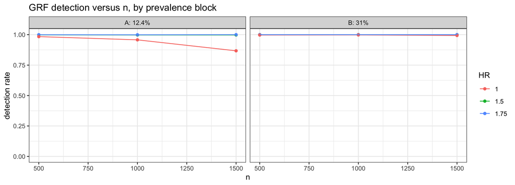

```r
if (!have(labs)) skip_note("the detection plot") else {
DP <- INV[, c("n", "HR", "block", "detection")]
DP$HR <- factor(DP$HR); DP$block <- factor(DP$block, levels = c("A","B"),
                                           labels = c("A: 12.4%", "B: 31%"))
ggplot(DP, aes(n, detection, colour = HR, group = HR)) +
  geom_point() + geom_line() + facet_wrap(~ block) + ylim(0, 1) +
  labs(x = "n", y = "detection rate", title = "GRF detection versus n, by prevalence block") +
  theme_bw(base_size = 11)
}
```

## 1.2 Structurally-NA columns

```r
if (!have(labs)) skip_note("the structural-NA table") else {
SN <- do.call(rbind, lapply(labs, function(k) {
  r <- B[[k]]$results
  f <- function(cn) if (!cn %in% names(r)) "not a recorder column" else
                    if (all(is.na(r[[cn]]))) "all-NA (structural)" else "POPULATED"
  data.frame(cell = k, n_cons_qual = f("n_cons_qual"), band_n = f("band_n"),
             p_star = if ("p_star" %in% names(r)) f("p_star") else "not a recorder column") }))
kbl(SN, booktabs = TRUE, row.names = FALSE,
    caption = "n_cons_qual and band_n are STRUCTURALLY NA on GRF: both read grp.consistency$out_sg$result, which the GRF branch never produces. p_star is not a recorder column at all -- it is the admission set's consistency term, NULL on GRF by the branch's own design. These are reported as structural, NOT as failures.") |>
  kable_styling(font_size = 10)
}
```

n_cons_qual and band_n are STRUCTURALLY NA on GRF: both read grp.consistency$out_sg$result, which the GRF branch never produces. p_star is not a recorder column at all -- it is the admission set's consistency term, NULL on GRF by the branch's own design. These are reported as structural, NOT as failures.

| cell | n_cons_qual | band_n | p_star |
| --- | --- | --- | --- |
| A: HR 1.50, n 500 | all-NA (structural) | all-NA (structural) | not a recorder column |
| A: HR 1.50, n 1000 | all-NA (structural) | all-NA (structural) | not a recorder column |
| A: HR 1.50, n 1500 | all-NA (structural) | all-NA (structural) | not a recorder column |
| A: HR 1.75, n 500 | all-NA (structural) | all-NA (structural) | not a recorder column |
| A: HR 1.75, n 1000 | all-NA (structural) | all-NA (structural) | not a recorder column |
| A: HR 1.75, n 1500 | all-NA (structural) | all-NA (structural) | not a recorder column |
| B: HR 1.50, n 500 | all-NA (structural) | all-NA (structural) | not a recorder column |
| B: HR 1.50, n 1000 | all-NA (structural) | all-NA (structural) | not a recorder column |
| B: HR 1.50, n 1500 | all-NA (structural) | all-NA (structural) | not a recorder column |
| B: HR 1.75, n 500 | all-NA (structural) | all-NA (structural) | not a recorder column |
| B: HR 1.75, n 1000 | all-NA (structural) | all-NA (structural) | not a recorder column |
| B: HR 1.75, n 1500 | all-NA (structural) | all-NA (structural) | not a recorder column |
| A: HR 1.00, n 500 | all-NA (structural) | all-NA (structural) | not a recorder column |
| A: HR 1.00, n 1000 | all-NA (structural) | all-NA (structural) | not a recorder column |
| A: HR 1.00, n 1500 | all-NA (structural) | all-NA (structural) | not a recorder column |
| B: HR 1.00, n 500 | all-NA (structural) | all-NA (structural) | not a recorder column |
| B: HR 1.00, n 1000 | all-NA (structural) | all-NA (structural) | not a recorder column |
| B: HR 1.00, n 1500 | all-NA (structural) | all-NA (structural) | not a recorder column |

# 2 Standard tables: constructions on both blocks

```r
subst_s <- function(r) { for (s in c("est2","up1s","lo1s","lo2s","hi2s","lo_se","hi_se","se","lam_mean"))
  r[[paste0("fld_Hc_", s)]] <- r[[paste0("fld_Hc_", s, "_s")]]; r }
err_sd <- function(r, block, est) { d <- r[r$detected %in% 1L, ]
  e <- switch(est, naive = d[[paste0("nv_", block, "_est")]],
                   mr    = d[[paste0("mr_", block, "_est")]],
                   fld   = d[[paste0("fld_", block, "_est2")]])
  ok <- is.finite(e) & is.finite(d[[paste0("betaHhat_", block)]])
  stats::sd(log(e[ok]) - log(d[[paste0("betaHhat_", block)]][ok])) }
cov_block <- function(r, block, side) {
  t1 <- fs_sim_bias_coverage(r, block = block, estimators = c("naive","mr","fld"), side = side)
  t1$sd_err <- vapply(as.character(t1$estimator), function(e) err_sd(r, block, e), 0)
  t1$construction <- c(naive="naive", mr="IJ two-term", fld="field")[as.character(t1$estimator)]
  if (block == "Hc") { rs <- subst_s(r)
    t2 <- fs_sim_bias_coverage(rs, block = "Hc", estimators = "fld", side = side)
    t2$sd_err <- err_sd(rs, "Hc", "fld"); t2$construction <- "field-s"; t1 <- rbind(t1, t2) }
  t1$se_over_sd_err <- t1$se_mean / t1$sd_err
  t1$b_err <- t1$bias_log / t1$sd_err
  # SECOND GAUSSIAN REFERENCE, on the ERROR SD.  cov1_ref (from
  # fs_sim_bias_coverage) is built on the MARGINAL SD; this twin uses the error
  # SD of the de-biased residual, which is the SD the interval is actually
  # trying to cover.  Formulae, stated here and in every caption that shows it:
  #   lower bounds (harm block Hhat):        cov1_ref_err = Phi(1.645 * SE/sd_err - b_err)
  #   upper bounds (complement block Hhat^c): cov1_ref_err = Phi(1.645 * SE/sd_err + b_err)
  # with SE/sd_err = se_over_sd_err and b_err = bias_log / sd_err.
  z95_ <- stats::qnorm(0.95)
  t1$cov1_ref_err <- if (identical(side, "lower"))
      stats::pnorm(z95_ * t1$se_over_sd_err - t1$b_err) else
      stats::pnorm(z95_ * t1$se_over_sd_err + t1$b_err)
  t1 }
```

```r
if (!have(labs)) skip_note("the standard construction tables") else {
COV <- do.call(rbind, lapply(labs, function(k) { r <- B[[k]]$results
  rbind(cbind(cell = k, block_grp = BLK[[k]], n_sample = NN[[k]], hr_cell = HR[[k]], arm = ARM[[k]],
              block = "Hhat (lower)",   cov_block(r, "H",  "lower")),
        cbind(cell = k, block_grp = BLK[[k]], n_sample = NN[[k]], hr_cell = HR[[k]], arm = ARM[[k]],
              block = "Hhat^c (upper)", cov_block(r, "Hc", "upper"))) }))
COV$construction <- factor(COV$construction, levels = c("naive","field","field-s","IJ two-term"))
COV <- COV[order(match(COV$cell, labs), COV$block, COV$construction), ]
for (blk in c("A","B")) {
  sub <- COV[COV$block_grp == blk, ]
  if (!have(sub)) { skip_note(sprintf("the standard table for Block %s", blk)); next }
  print(kbl(sub[, c("cell","block","construction","n_sample","n","bias_log","sd_emp","sd_err",
                    "b","b_err","se_mean","r","se_over_sd_err","cov1","cov1_wilson_lo",
                    "cov1_wilson_hi","cov2","cov1_ref","cov1_ref_err")],
      digits = 3, booktabs = TRUE, row.names = FALSE,
      caption = sprintf("BLOCK %s (%s prevalence). Per cell and block: bias on the log scale; marginal SD (sd_emp) and error SD (sd_err) side by side; b = bias / marginal SD, b_err = bias / error SD; mean SE; r = SE / marginal SD and SE / error SD; cov1 = one-sided 95%% coverage on the exposed side (lower for beta(Hhat), upper for beta(Hhat^c)) with Wilson limits; cov2 = two-sided; cov1_ref = the Gaussian reference on the MARGINAL SD, cov1_ref_err its twin on the ERROR SD -- cov1_ref_err = Phi(1.645 * se_over_sd_err - b_err) for the Hhat block's LOWER bound and Phi(1.645 * se_over_sd_err + b_err) for the complement block's UPPER bound, where b_err = bias_log / sd_err. EVERY COVERAGE COLUMN (cov1, cov1_wilson_lo, cov1_wilson_hi, cov2) IS COMPUTED OVER DETECTED REPLICATES ONLY. The Hhat block has no field-s row (field-s = field there by construction). naive is a reference, never a product. On the HR 1.00 cells (arm = null) the Hhat block is the identified region, differentially null against a benefiting complement; no harm is planted there.",
                          blk, if (blk == "A") "12.4%" else "31%")) |>
      kable_styling(font_size = 9))
}
}
```

[output not shown]

[output cut: 2646 more lines]

[output not shown]

```r
if (!have(labs)) skip_note("the across-cell summary") else {
ACR <- do.call(rbind, lapply(split(COV, list(COV$block, COV$construction, COV$arm, COV$block_grp),
                                   drop = TRUE), function(d)
  data.frame(prevalence_block = d$block_grp[1], arm = d$arm[1], block = d$block[1],
             construction = d$construction[1], cells = nrow(d),
             cov1_min = min(d$cov1), cov1_mean = mean(d$cov1), cov1_max = max(d$cov1),
             cov2_mean = mean(d$cov2), b_mean = mean(d$b), r_mean = mean(d$r),
             se_over_sd_err_mean = mean(d$se_over_sd_err))))
ACR <- ACR[order(ACR$prevalence_block, ACR$arm, ACR$block, ACR$construction), ]
kbl(ACR, digits = 3, booktabs = TRUE, row.names = FALSE,
    caption = "Across cells within each prevalence block and arm: range and mean of the one-sided coverage, mean two-sided coverage, mean b and r. All coverages are over detected replicates.") |>
  kable_styling(font_size = 9)
}
```

Across cells within each prevalence block and arm: range and mean of the one-sided coverage, mean two-sided coverage, mean b and r. All coverages are over detected replicates.

| prevalence_block | arm | block | construction | cells | cov1_min | cov1_mean | cov1_max | cov2_mean | b_mean | r_mean | se_over_sd_err_mean |
| --- | --- | --- | --- | --- | --- | --- | --- | --- | --- | --- | --- |
| A | harm | Hhat (lower) | naive | 6 | 0.358 | 0.564 | 0.763 | 0.678 | 1.397 | 0.890 | 0.862 |
| A | harm | Hhat (lower) | field | 6 | 0.936 | 0.946 | 0.958 | 0.913 | -0.048 | 0.853 | 0.908 |
| A | harm | Hhat (lower) | IJ two-term | 6 | 0.975 | 0.979 | 0.986 | 0.983 | 0.065 | 1.084 | 1.131 |
| A | harm | Hhat^c (upper) | naive | 6 | 0.776 | 0.843 | 0.894 | 0.905 | -0.638 | 0.990 | 1.014 |
| A | harm | Hhat^c (upper) | field | 6 | 0.925 | 0.943 | 0.957 | 0.942 | -0.037 | 0.942 | 0.974 |
| A | harm | Hhat^c (upper) | field-s | 6 | 0.932 | 0.947 | 0.956 | 0.945 | -0.040 | 0.957 | 0.989 |
| A | harm | Hhat^c (upper) | IJ two-term | 6 | 0.996 | 0.998 | 1.000 | 1.000 | -0.119 | 1.801 | 1.855 |
| A | null | Hhat (lower) | naive | 3 | 0.211 | 0.260 | 0.310 | 0.418 | 2.560 | 1.204 | 1.031 |
| A | null | Hhat (lower) | field | 3 | 0.940 | 0.948 | 0.957 | 0.963 | 0.207 | 1.146 | 1.059 |
| A | null | Hhat (lower) | IJ two-term | 3 | 0.972 | 0.976 | 0.982 | 0.992 | 0.460 | 1.466 | 1.326 |
| A | null | Hhat^c (upper) | naive | 3 | 0.744 | 0.781 | 0.815 | 0.869 | -0.975 | 1.055 | 1.070 |
| A | null | Hhat^c (upper) | field | 3 | 0.926 | 0.936 | 0.942 | 0.949 | -0.133 | 0.995 | 1.011 |
| A | null | Hhat^c (upper) | field-s | 3 | 0.932 | 0.941 | 0.948 | 0.955 | -0.137 | 1.016 | 1.032 |
| A | null | Hhat^c (upper) | IJ two-term | 3 | 0.996 | 0.997 | 0.999 | 1.000 | -0.285 | 1.897 | 1.924 |
| B | harm | Hhat (lower) | naive | 6 | 0.474 | 0.670 | 0.823 | 0.761 | 1.091 | 0.858 | 0.746 |
| B | harm | Hhat (lower) | field | 6 | 0.929 | 0.950 | 0.969 | 0.914 | -0.142 | 0.988 | 0.922 |
| B | harm | Hhat (lower) | IJ two-term | 6 | 0.975 | 0.983 | 0.994 | 0.974 | -0.091 | 1.201 | 1.108 |
| B | harm | Hhat^c (upper) | naive | 6 | 0.781 | 0.856 | 0.901 | 0.909 | -0.491 | 0.836 | 1.010 |
| B | harm | Hhat^c (upper) | field | 6 | 0.915 | 0.932 | 0.944 | 0.932 | -0.055 | 0.784 | 0.927 |
| B | harm | Hhat^c (upper) | field-s | 6 | 0.918 | 0.938 | 0.951 | 0.946 | -0.059 | 0.822 | 0.972 |
| B | harm | Hhat^c (upper) | IJ two-term | 6 | 0.998 | 0.998 | 1.000 | 1.000 | -0.109 | 1.517 | 1.802 |
| B | null | Hhat (lower) | naive | 3 | 0.261 | 0.362 | 0.484 | 0.517 | 1.991 | 1.010 | 0.893 |
| B | null | Hhat (lower) | field | 3 | 0.942 | 0.949 | 0.959 | 0.948 | 0.041 | 1.063 | 0.993 |
| B | null | Hhat (lower) | IJ two-term | 3 | 0.975 | 0.980 | 0.986 | 0.992 | 0.240 | 1.323 | 1.216 |
| B | null | Hhat^c (upper) | naive | 3 | 0.729 | 0.742 | 0.754 | 0.836 | -1.005 | 0.979 | 1.023 |
| B | null | Hhat^c (upper) | field | 3 | 0.905 | 0.910 | 0.918 | 0.937 | -0.230 | 0.934 | 0.972 |
| B | null | Hhat^c (upper) | field-s | 3 | 0.911 | 0.924 | 0.936 | 0.948 | -0.234 | 0.974 | 1.012 |
| B | null | Hhat^c (upper) | IJ two-term | 3 | 0.996 | 0.997 | 0.998 | 1.000 | -0.377 | 1.777 | 1.849 |

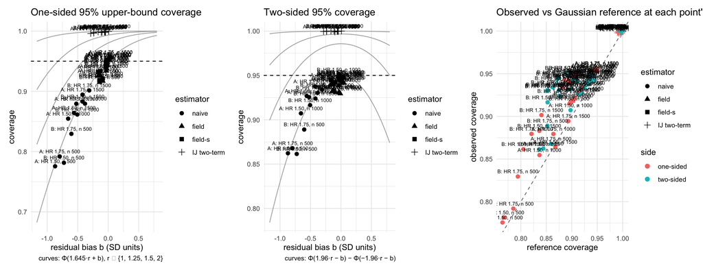

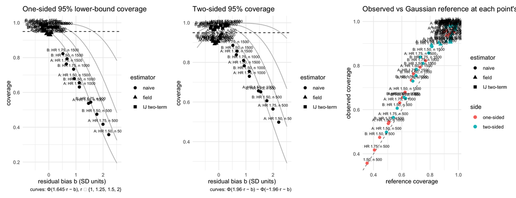

```r
if (!length(harm_labs)) skip_note("the bias/coverage panels (no harm cell on disk)") else {
for (sd_ in list(list(bl = "Hhat^c (upper)", side = "upper"), list(bl = "Hhat (lower)", side = "lower"))) {
  tab <- COV[COV$block == sd_$bl & COV$arm == "harm", ]
  if (!have(tab)) { skip_note(sprintf("the %s panel", sd_$bl)); next }
  tab$estimator <- tab$construction
  tab <- tab[, setdiff(names(tab), c("n_sample","hr_cell","arm","block","block_grp",
                                     "sd_err","se_over_sd_err","b_err","construction"))]
  print(fs_plot_bias_coverage(tab, curves = c(1, 1.25, 1.5, 2), side = sd_$side))
}
}
```

# 3 Coverage versus n, both prevalences

```r
# THE FS COMPARATOR THAT SHARES THE DGM DRAWS, per cell, with its OWN criterion.
# Block A (12.4%): p12ext at HR 1.50/1.00 and tier2 at HR 1.75 -- maxeffCons, eps 0.10.
# Block B (31%)  : cert20 at n 1000/1500 and e1stud at n 500  -- effMaxSG, eps 0.20;
#                  at HR 1.00 (Block C's 31% cells) cert20 at all three n.
# The criterion therefore MATCHES GRF's at 31% and DIFFERS at 12.4%; every FS
# number below carries its own sg_focus and eps so the reader never has to
# remember which.
fs_file <- function(blk, hr, n) {
  if (blk == "A") {
    camp <- if (abs(hr - 1.75) < 1e-9) "tier2" else if (abs(hr - 1.00) < 1e-9 && n == 500L) "tier2" else "p12ext"
    sprintf("%sfs_maxeffCons_fb_mr_field_m1_h%03d_knoise0_n%d_%s_combined_1_2000.rds", R, round(100*hr), n, camp)
  } else {
    # e1stud was run only at HR 1.50 and 1.75.  At HR 1.00 the n = 500 / 31%
    # comparator is cert20, which IS on disk and is likewise effMaxSG at
    # eps 0.20 -- so the null cells at 31% stay criterion-matched
    # (TASK_dinamr_blockC_grfprobe_2026-09-11; resolved per cell by gate2G.R
    # for TASK_grfmr_completion_2026-09-12).
    camp <- if (n == 500L && abs(hr - 1.00) > 1e-9) "e1stud" else "cert20"
    sprintf("%sfs_effMaxSG_fb_mr_field_m1_h%03d_knoise0_n%d_z1q60_nb20_%s_combined_1_2000.rds", R, round(100*hr), n, camp)
  } }
fs_for <- function(k) { f <- fs_file(BLK[[k]], HR[[k]], NN[[k]])
  if (!file.exists(f)) return(NULL); b <- readRDS(f)
  list(b = b, file = basename(f), campaign = b$meta$campaign_tag %||% NA,
       focus = b$meta$sg_focus %||% NA, eps = b$meta$effect_neighborhood %||% NA_real_) }
fs_crit <- function(x) sprintf("%s / %s / eps %s", x$campaign, x$focus, format(x$eps))
```

```r
wil <- function(p, n, z = stats::qnorm(0.975)) {
  ctr <- (p + z^2 / (2 * n)) / (1 + z^2 / n)
  hw  <- z * sqrt(p * (1 - p) / n + z^2 / (4 * n^2)) / (1 + z^2 / n)
  c(ctr - hw, ctr + hw) }
z95 <- stats::qnorm(0.95); z975 <- stats::qnorm(0.975)
covs_cell <- function(k) {
  r <- B[[k]]$results
  d <- r[r$detected %in% 1L & is.finite(r$betaHhat_H) & is.finite(r$betaHhat_Hc) &
         is.finite(r$fld_H_lo1s) & is.finite(r$fld_Hc_up1s_s), , drop = FALSE]
  if (!nrow(d)) return(NULL)
  cH  <- mean(d$betaHhat_H  >= d$fld_H_lo1s)
  cC  <- mean(d$betaHhat_Hc <= d$fld_Hc_up1s_s)
  cCf <- mean(d$betaHhat_Hc <= d$fld_Hc_up1s)
  ij_H  <- mean(d$betaHhat_H  >= d$mr_H_lo  & d$betaHhat_H  <= d$mr_H_hi)
  ij_Hc <- mean(d$betaHhat_Hc >= d$mr_Hc_lo & d$betaHhat_Hc <= d$mr_Hc_hi)
  # the two-sided miss, split by side -- the question in Stage 3 item 5
  miss_lo <- mean(d$betaHhat_H < d$mr_H_lo)     # truth below the interval
  miss_hi <- mean(d$betaHhat_H > d$mr_H_hi)     # truth above the interval
  jt  <- mean(d$betaHhat_H >= d$fld_joint_bonf_loH   & d$betaHhat_Hc <= d$fld_joint_bonf_upHc)
  jts <- mean(d$betaHhat_H >= d$fld_joint_s_bonf_loH & d$betaHhat_Hc <= d$fld_joint_s_bonf_upHc)
  g <- function(p) { w <- wil(p, nrow(d)); c(p, w) }
  data.frame(cell = k, block = BLK[[k]], n = NN[[k]], HR = HR[[k]], arm = ARM[[k]], n_eval = nrow(d),
             harm_field = cH, harm_field_lo = g(cH)[2], harm_field_hi = g(cH)[3],
             comp_field_s = cC, comp_field_s_lo = g(cC)[2], comp_field_s_hi = g(cC)[3],
             comp_field = cCf, comp_field_lo = g(cCf)[2], comp_field_hi = g(cCf)[3],
             ij2_H = ij_H, ij2_H_lo = g(ij_H)[2], ij2_H_hi = g(ij_H)[3],
             miss_below = miss_lo, miss_above = miss_hi,
             ij2_Hc = ij_Hc, ij2_Hc_lo = g(ij_Hc)[2], ij2_Hc_hi = g(ij_Hc)[3],
             joint_bonf = jt, joint_bonf_lo = g(jt)[2], joint_bonf_hi = g(jt)[3],
             joint_s_bonf = jts, joint_s_bonf_lo = g(jts)[2], joint_s_bonf_hi = g(jts)[3]) }
VSN <- if (length(labs)) do.call(rbind, lapply(labs, covs_cell)) else NULL
if (have(VSN)) VSN <- VSN[order(VSN$arm, VSN$block, VSN$HR, VSN$n), ]
```

```r
if (!have(VSN)) skip_note("coverage versus n") else {
vh <- VSN[VSN$arm == "harm", ]
if (!have(vh)) skip_note("the harm-block coverage table") else
kbl(vh[, c("cell","block","n","HR","n_eval","harm_field","harm_field_lo","harm_field_hi",
           "ij2_H","ij2_H_lo","ij2_H_hi","miss_below","miss_above")],
    digits = 4, booktabs = TRUE, row.names = FALSE,
    caption = "Harm cells, both prevalence blocks: one-sided 95% LOWER coverage of beta(Hhat) by the field bound, and TWO-SIDED coverage by the IJ two-term interval, with Wilson limits, against n at each HR; the two-sided miss split by side (miss_below = truth under the lower limit, miss_above = truth over the upper limit). All coverages are of the coverage over detected replicates.") |>
  kable_styling(font_size = 9)
}
```

Harm cells, both prevalence blocks: one-sided 95% LOWER coverage of beta(Hhat) by the field bound, and TWO-SIDED coverage by the IJ two-term interval, with Wilson limits, against n at each HR; the two-sided miss split by side (miss_below = truth under the lower limit, miss_above = truth over the upper limit). All coverages are of the coverage over detected replicates.

| cell | block | n | HR | n_eval | harm_field | harm_field_lo | harm_field_hi | ij2_H | ij2_H_lo | ij2_H_hi | miss_below | miss_above |
| --- | --- | --- | --- | --- | --- | --- | --- | --- | --- | --- | --- | --- |
| A: HR 1.50, n 500 | A | 500 | 1.50 | 1997 | 0.9434 | 0.9324 | 0.9527 | 0.9890 | 0.9834 | 0.9927 | 0.0080 | 0.0030 |
| A: HR 1.50, n 1000 | A | 1000 | 1.50 | 1995 | 0.9404 | 0.9291 | 0.9499 | 0.9870 | 0.9810 | 0.9911 | 0.0090 | 0.0040 |
| A: HR 1.50, n 1500 | A | 1500 | 1.50 | 1995 | 0.9579 | 0.9482 | 0.9659 | 0.9799 | 0.9728 | 0.9852 | 0.0065 | 0.0135 |
| A: HR 1.75, n 500 | A | 500 | 1.75 | 1999 | 0.9415 | 0.9303 | 0.9509 | 0.9900 | 0.9846 | 0.9935 | 0.0065 | 0.0035 |
| A: HR 1.75, n 1000 | A | 1000 | 1.75 | 1998 | 0.9364 | 0.9249 | 0.9463 | 0.9775 | 0.9700 | 0.9831 | 0.0080 | 0.0145 |
| A: HR 1.75, n 1500 | A | 1500 | 1.75 | 2000 | 0.9535 | 0.9434 | 0.9619 | 0.9755 | 0.9678 | 0.9814 | 0.0045 | 0.0200 |
| B: HR 1.50, n 500 | B | 500 | 1.50 | 2000 | 0.9295 | 0.9174 | 0.9399 | 0.9840 | 0.9775 | 0.9886 | 0.0060 | 0.0100 |
| B: HR 1.50, n 1000 | B | 1000 | 1.50 | 2000 | 0.9525 | 0.9423 | 0.9610 | 0.9670 | 0.9582 | 0.9740 | 0.0060 | 0.0270 |
| B: HR 1.50, n 1500 | B | 1500 | 1.50 | 2000 | 0.9690 | 0.9605 | 0.9757 | 0.9730 | 0.9649 | 0.9792 | 0.0045 | 0.0225 |
| B: HR 1.75, n 500 | B | 500 | 1.75 | 2000 | 0.9300 | 0.9180 | 0.9404 | 0.9730 | 0.9649 | 0.9792 | 0.0045 | 0.0225 |
| B: HR 1.75, n 1000 | B | 1000 | 1.75 | 2000 | 0.9515 | 0.9412 | 0.9601 | 0.9640 | 0.9549 | 0.9713 | 0.0045 | 0.0315 |
| B: HR 1.75, n 1500 | B | 1500 | 1.75 | 2000 | 0.9645 | 0.9555 | 0.9718 | 0.9810 | 0.9740 | 0.9861 | 0.0025 | 0.0165 |

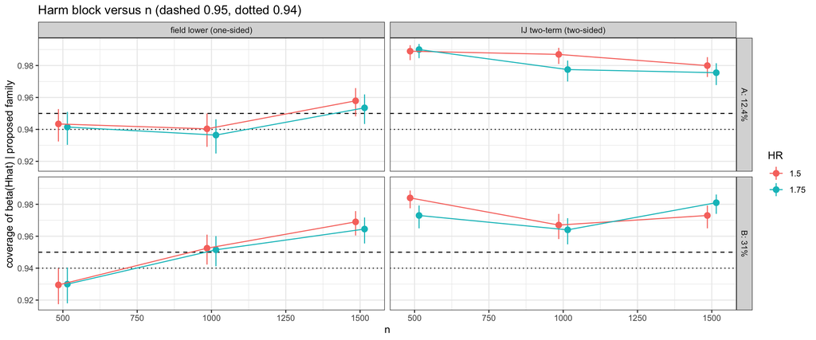

```r
if (!have(VSN) || !have(VSN[VSN$arm == "harm", ])) skip_note("the harm-block coverage plot") else {
ph <- VSN[VSN$arm == "harm", ]
PH <- rbind(
  data.frame(n = ph$n, HR = factor(ph$HR), blk = ph$block,
             construction = "field lower (one-sided)", cov = ph$harm_field,
             lo = ph$harm_field_lo, hi = ph$harm_field_hi),
  data.frame(n = ph$n, HR = factor(ph$HR), blk = ph$block,
             construction = "IJ two-term (two-sided)", cov = ph$ij2_H,
             lo = ph$ij2_H_lo, hi = ph$ij2_H_hi))
PH$blk <- factor(PH$blk, levels = c("A","B"), labels = c("A: 12.4%", "B: 31%"))
ggplot(PH, aes(n, cov, colour = HR, group = HR)) +
  geom_hline(yintercept = 0.95, linetype = 2) + geom_hline(yintercept = 0.94, linetype = 3) +
  geom_pointrange(aes(ymin = lo, ymax = hi), position = position_dodge(width = 60)) +
  geom_line(position = position_dodge(width = 60)) +
  facet_grid(blk ~ construction) +
  labs(x = "n", y = "coverage of beta(Hhat) | proposed family",
       title = "Harm block versus n (dashed 0.95, dotted 0.94)") + theme_bw(base_size = 11)
}
```

```r
if (!have(VSN) || !have(VSN[VSN$arm == "harm", ])) skip_note("the complement-block table") else
kbl(VSN[VSN$arm == "harm", c("cell","block","n","HR","n_eval","comp_field_s","comp_field_s_lo",
                             "comp_field_s_hi","comp_field","ij2_Hc","ij2_Hc_lo","ij2_Hc_hi",
                             "joint_bonf","joint_s_bonf","joint_s_bonf_lo","joint_s_bonf_hi")],
    digits = 4, booktabs = TRUE, row.names = FALSE,
    caption = "Harm cells: one-sided 95% UPPER coverage of beta(Hhat^c) by field-s (Wilson) with the unscaled field beside it; two-sided IJ two-term coverage; and the Bonferroni joint pair from the unscaled joint and from joint_s. Over detected replicates throughout.") |>
  kable_styling(font_size = 9)
```

Harm cells: one-sided 95% UPPER coverage of beta(Hhat^c) by field-s (Wilson) with the unscaled field beside it; two-sided IJ two-term coverage; and the Bonferroni joint pair from the unscaled joint and from joint_s. Over detected replicates throughout.

| cell | block | n | HR | n_eval | comp_field_s | comp_field_s_lo | comp_field_s_hi | comp_field | ij2_Hc | ij2_Hc_lo | ij2_Hc_hi | joint_bonf | joint_s_bonf | joint_s_bonf_lo | joint_s_bonf_hi |
| --- | --- | --- | --- | --- | --- | --- | --- | --- | --- | --- | --- | --- | --- | --- | --- |
| A: HR 1.50, n 500 | A | 500 | 1.50 | 1997 | 0.9319 | 0.9200 | 0.9421 | 0.9254 | 0.9995 | 0.9972 | 0.9999 | 0.9304 | 0.9359 | 0.9243 | 0.9458 |
| A: HR 1.50, n 1000 | A | 1000 | 1.50 | 1995 | 0.9519 | 0.9416 | 0.9604 | 0.9469 | 1.0000 | 0.9981 | 1.0000 | 0.9393 | 0.9398 | 0.9285 | 0.9495 |
| A: HR 1.50, n 1500 | A | 1500 | 1.50 | 1995 | 0.9529 | 0.9427 | 0.9613 | 0.9514 | 0.9995 | 0.9972 | 0.9999 | 0.9524 | 0.9544 | 0.9443 | 0.9627 |
| A: HR 1.75, n 500 | A | 500 | 1.75 | 1999 | 0.9335 | 0.9217 | 0.9436 | 0.9260 | 0.9995 | 0.9972 | 0.9999 | 0.9305 | 0.9350 | 0.9233 | 0.9450 |
| A: HR 1.75, n 1000 | A | 1000 | 1.75 | 1998 | 0.9540 | 0.9439 | 0.9623 | 0.9525 | 1.0000 | 0.9981 | 1.0000 | 0.9379 | 0.9399 | 0.9287 | 0.9495 |
| A: HR 1.75, n 1500 | A | 1500 | 1.75 | 2000 | 0.9560 | 0.9461 | 0.9641 | 0.9565 | 1.0000 | 0.9981 | 1.0000 | 0.9540 | 0.9575 | 0.9477 | 0.9655 |
| B: HR 1.50, n 500 | B | 500 | 1.50 | 2000 | 0.9185 | 0.9057 | 0.9297 | 0.9150 | 1.0000 | 0.9981 | 1.0000 | 0.9185 | 0.9230 | 0.9105 | 0.9339 |
| B: HR 1.50, n 1000 | B | 1000 | 1.50 | 2000 | 0.9460 | 0.9352 | 0.9551 | 0.9420 | 0.9990 | 0.9964 | 0.9997 | 0.9440 | 0.9505 | 0.9401 | 0.9592 |
| B: HR 1.50, n 1500 | B | 1500 | 1.50 | 2000 | 0.9480 | 0.9374 | 0.9569 | 0.9380 | 0.9995 | 0.9972 | 0.9999 | 0.9500 | 0.9565 | 0.9467 | 0.9646 |
| B: HR 1.75, n 500 | B | 500 | 1.75 | 2000 | 0.9210 | 0.9084 | 0.9320 | 0.9170 | 1.0000 | 0.9981 | 1.0000 | 0.9215 | 0.9260 | 0.9137 | 0.9367 |
| B: HR 1.75, n 1000 | B | 1000 | 1.75 | 2000 | 0.9510 | 0.9406 | 0.9596 | 0.9435 | 1.0000 | 0.9981 | 1.0000 | 0.9400 | 0.9465 | 0.9358 | 0.9555 |
| B: HR 1.75, n 1500 | B | 1500 | 1.75 | 2000 | 0.9410 | 0.9298 | 0.9505 | 0.9340 | 1.0000 | 0.9981 | 1.0000 | 0.9520 | 0.9550 | 0.9450 | 0.9632 |

# 4 The two-sided question: does FS’s harm-block decay with n at 12.4% appear on GRF?

On FS at 12.4% the harm-block **two-sided** IJ coverage decays with n — 0.977 → 0.932 → 0.901 at HR 1.50 and 0.961 → 0.917 → 0.913 at HR 1.75, across n = 500 / 1000 / 1500 (`p12ext` / `tier2`, read as they stand). The same trajectory is computed here on GRF, with the miss split by side.

```r
FS_REF <- data.frame(HR = c(1.50,1.50,1.50,1.75,1.75,1.75), n = c(500,1000,1500,500,1000,1500),
                     fs_ij2_H = c(0.977,0.932,0.901,0.961,0.917,0.913),
                     # the criterion each FS number was produced under -- NOT GRF's
                     fs_criterion = c(rep("p12ext / maxeffCons / eps 0.1", 3),
                                      rep("tier2 / maxeffCons / eps 0.1", 3)),
                     stringsAsFactors = FALSE)
if (!have(VSN)) skip_note("the two-sided comparison") else {
TS <- VSN[VSN$arm == "harm" & VSN$block == "A", c("cell","n","HR","n_eval","ij2_H","ij2_H_lo","ij2_H_hi","miss_below","miss_above")]
if (!have(TS)) skip_note("the two-sided comparison at 12.4% (Block A not on disk)") else {
TS <- merge(TS, FS_REF, by = c("HR","n"), all.x = TRUE)
TS <- TS[order(TS$HR, TS$n), ]
TS$grf_minus_fs <- TS$ij2_H - TS$fs_ij2_H
kbl(TS[, c("cell","n","HR","n_eval","ij2_H","ij2_H_lo","ij2_H_hi","miss_below","miss_above","fs_ij2_H","fs_criterion","grf_minus_fs")],
    digits = 4, booktabs = TRUE, row.names = FALSE,
    caption = "BLOCK A (12.4%), harm cells: GRF's two-sided IJ two-term coverage of beta(Hhat) against n, with the miss split by side, beside the committed FS trajectory (fs_ij2_H, from p12ext / tier2 read as they stand). GRF's column is coverage over detected replicates at effMaxSG / eps 0.20; FS's is its own, produced under the criterion named in fs_criterion -- maxeffCons at eps 0.10, which is NOT GRF's, so at 12.4% the criterion is a fourth confounded difference. See @sec-fsgrid. Descriptive, not a contest.") |>
  kable_styling(font_size = 10)
}
}
```

BLOCK A (12.4%), harm cells: GRF's two-sided IJ two-term coverage of beta(Hhat) against n, with the miss split by side, beside the committed FS trajectory (fs_ij2_H, from p12ext / tier2 read as they stand). GRF's column is coverage over detected replicates at effMaxSG / eps 0.20; FS's is its own, produced under the criterion named in fs_criterion -- maxeffCons at eps 0.10, which is NOT GRF's, so at 12.4% the criterion is a fourth confounded difference. See @sec-fsgrid. Descriptive, not a contest.

| cell | n | HR | n_eval | ij2_H | ij2_H_lo | ij2_H_hi | miss_below | miss_above | fs_ij2_H | fs_criterion | grf_minus_fs |
| --- | --- | --- | --- | --- | --- | --- | --- | --- | --- | --- | --- |
| A: HR 1.50, n 500 | 500 | 1.50 | 1997 | 0.9890 | 0.9834 | 0.9927 | 0.0080 | 0.0030 | 0.977 | p12ext / maxeffCons / eps 0.1 | 0.0120 |
| A: HR 1.50, n 1000 | 1000 | 1.50 | 1995 | 0.9870 | 0.9810 | 0.9911 | 0.0090 | 0.0040 | 0.932 | p12ext / maxeffCons / eps 0.1 | 0.0550 |
| A: HR 1.50, n 1500 | 1500 | 1.50 | 1995 | 0.9799 | 0.9728 | 0.9852 | 0.0065 | 0.0135 | 0.901 | p12ext / maxeffCons / eps 0.1 | 0.0789 |
| A: HR 1.75, n 500 | 500 | 1.75 | 1999 | 0.9900 | 0.9846 | 0.9935 | 0.0065 | 0.0035 | 0.961 | tier2 / maxeffCons / eps 0.1 | 0.0290 |
| A: HR 1.75, n 1000 | 1000 | 1.75 | 1998 | 0.9775 | 0.9700 | 0.9831 | 0.0080 | 0.0145 | 0.917 | tier2 / maxeffCons / eps 0.1 | 0.0605 |
| A: HR 1.75, n 1500 | 1500 | 1.75 | 2000 | 0.9755 | 0.9678 | 0.9814 | 0.0045 | 0.0200 | 0.913 | tier2 / maxeffCons / eps 0.1 | 0.0625 |

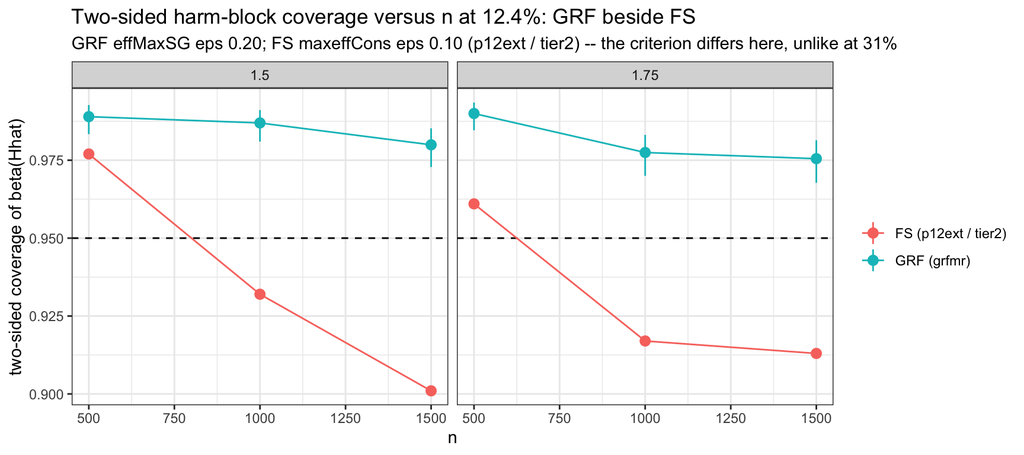

```r
if (!have(VSN) || !have(VSN[VSN$arm == "harm" & VSN$block == "A", ])) skip_note("the two-sided plot") else {
TP2 <- rbind(
  data.frame(n = TS$n, HR = factor(TS$HR), who = "GRF (grfmr)", cov = TS$ij2_H, lo = TS$ij2_H_lo, hi = TS$ij2_H_hi),
  data.frame(n = TS$n, HR = factor(TS$HR), who = "FS (p12ext / tier2)", cov = TS$fs_ij2_H, lo = NA, hi = NA))
ggplot(TP2, aes(n, cov, colour = who, group = who)) +
  geom_hline(yintercept = 0.95, linetype = 2) +
  geom_pointrange(aes(ymin = lo, ymax = hi), na.rm = TRUE) + geom_line() + facet_wrap(~ HR) +
  labs(x = "n", y = "two-sided coverage of beta(Hhat)", colour = NULL,
       title = "Two-sided harm-block coverage versus n at 12.4%: GRF beside FS",
       subtitle = "GRF effMaxSG eps 0.20; FS maxeffCons eps 0.10 (p12ext / tier2) -- the criterion differs here, unlike at 31%") +
  theme_bw(base_size = 11)
}
```

# 5 Classification versus n and prevalence

```r
if (!have(labs)) skip_note("the classification table") else {
IDENT <- do.call(rbind, lapply(labs, function(k) {
  r <- B[[k]]$results; d <- r[r$detected %in% 1L, , drop = FALSE]; tr <- B[[k]]$truth
  if (!nrow(d)) return(NULL)
  rat <- d$n_harm / d$n_true
  onv_H  <- mean(log(d$nv_H_est)  - log(d$betaHhat_H))
  onv_Hc <- mean(log(d$nv_Hc_est) - log(d$betaHhat_Hc))
  sdm_H  <- stats::sd(log(d$nv_H_est));  sde_H  <- stats::sd(log(d$nv_H_est)  - log(d$betaHhat_H))
  sdm_Hc <- stats::sd(log(d$nv_Hc_est)); sde_Hc <- stats::sd(log(d$nv_Hc_est) - log(d$betaHhat_Hc))
  data.frame(cell = k, block = BLK[[k]], n = NN[[k]], HR = HR[[k]], arm = ARM[[k]],
             detection = mean(r$detected %in% 1L), n_det = nrow(d),
             sens = mean(d$sens), spec = mean(d$spec), ppv = mean(d$ppv), npv = mean(d$npv),
             absH_mean = mean(d$n_sel), absHtrue_mean = mean(d$n_true),
             Hhat_over_H_med = stats::median(rat), Hhat_over_H_q90 = unname(stats::quantile(rat, .9)),
             beta_H_mean = mean(d$betaHhat_H), planted_H = unname(tr$marg_H),
             beta_Hc_mean = mean(d$betaHhat_Hc), planted_Hc = unname(tr$marg_Hc),
             naive_opt_H_marg = onv_H / sdm_H, naive_opt_H_err = onv_H / sde_H,
             naive_opt_Hc_marg = onv_Hc / sdm_Hc, naive_opt_Hc_err = onv_Hc / sde_Hc,
             p_hat_mean = mean(d$p_hat_H[is.finite(d$p_hat_H)]),
             K_mean = mean(d$n_family, na.rm = TRUE),
             K_med = stats::median(d$n_family, na.rm = TRUE)) }))
IDENT <- IDENT[order(IDENT$arm, IDENT$block, IDENT$HR, IDENT$n), ]
kbl(IDENT, digits = 3, booktabs = TRUE, row.names = FALSE,
    caption = "Classification against n and prevalence: detection; sens / spec / PPV / NPV; mean |Hhat|; |Hhat|/|H| median and q90; the realized beta(Hhat) and beta(Hhat^c) against the PLANTED marginal Cox targets; the naive optimism in marginal-SD and error-SD units on both blocks; mean p-hat; and the proposed-family size K. n_cons_qual is omitted -- it is structurally NA on GRF (@sec-structna).") |>
  kable_styling(font_size = 8)
}
```

Classification against n and prevalence: detection; sens / spec / PPV / NPV; mean |Hhat|; |Hhat|/|H| median and q90; the realized beta(Hhat) and beta(Hhat^c) against the PLANTED marginal Cox targets; the naive optimism in marginal-SD and error-SD units on both blocks; mean p-hat; and the proposed-family size K. n_cons_qual is omitted -- it is structurally NA on GRF (@sec-structna).

| cell | block | n | HR | arm | detection | n_det | sens | spec | ppv | npv | absH_mean | absHtrue_mean | Hhat_over_H_med | Hhat_over_H_q90 | beta_H_mean | planted_H | beta_Hc_mean | planted_Hc | naive_opt_H_marg | naive_opt_H_err | naive_opt_Hc_marg | naive_opt_Hc_err | p_hat_mean | K_mean | K_med |
| --- | --- | --- | --- | --- | --- | --- | --- | --- | --- | --- | --- | --- | --- | --- | --- | --- | --- | --- | --- | --- | --- | --- | --- | --- | --- |
| A: HR 1.50, n 500 | A | 500 | 1.50 | harm | 0.999 | 1997 | 0.516 | 0.836 | 0.319 | 0.925 | 103.836 | 61.806 | 1.574 | 2.456 | 0.854 | 1.509 | 0.680 | 0.657 | 2.209 | 1.807 | -0.870 | -0.914 | 0.139 | 776.327 | 776 |
| A: HR 1.50, n 1000 | A | 1000 | 1.50 | harm | 0.998 | 1995 | 0.644 | 0.885 | 0.481 | 0.947 | 180.192 | 123.884 | 1.393 | 2.175 | 1.004 | 1.509 | 0.665 | 0.657 | 1.464 | 1.347 | -0.657 | -0.674 | 0.157 | 830.191 | 830 |
| A: HR 1.50, n 1500 | A | 1500 | 1.50 | harm | 0.998 | 1995 | 0.745 | 0.896 | 0.552 | 0.962 | 275.511 | 186.052 | 1.448 | 2.242 | 1.066 | 1.509 | 0.655 | 0.657 | 0.938 | 1.085 | -0.561 | -0.563 | 0.177 | 829.772 | 830 |
| A: HR 1.75, n 500 | A | 500 | 1.75 | harm | 1.000 | 1999 | 0.575 | 0.850 | 0.366 | 0.935 | 101.601 | 61.812 | 1.552 | 2.386 | 0.954 | 1.769 | 0.682 | 0.657 | 1.997 | 1.629 | -0.795 | -0.824 | 0.151 | 776.320 | 776 |
| A: HR 1.75, n 1000 | A | 1000 | 1.75 | harm | 0.999 | 1998 | 0.697 | 0.908 | 0.563 | 0.955 | 167.248 | 123.880 | 1.298 | 1.972 | 1.201 | 1.769 | 0.664 | 0.657 | 1.127 | 1.117 | -0.522 | -0.536 | 0.205 | 830.193 | 830 |
| A: HR 1.75, n 1500 | A | 1500 | 1.75 | harm | 1.000 | 2000 | 0.777 | 0.921 | 0.639 | 0.967 | 248.685 | 186.018 | 1.278 | 2.001 | 1.292 | 1.769 | 0.655 | 0.657 | 0.647 | 0.832 | -0.421 | -0.422 | 0.249 | 829.766 | 830 |
| B: HR 1.50, n 500 | B | 500 | 1.50 | harm | 1.000 | 2000 | 0.522 | 0.899 | 0.678 | 0.816 | 115.028 | 152.953 | 0.689 | 1.083 | 1.236 | 1.499 | 0.821 | 0.721 | 1.771 | 1.451 | -0.726 | -0.810 | 0.158 | 776.319 | 776 |
| B: HR 1.50, n 1000 | B | 1000 | 1.50 | harm | 1.000 | 2000 | 0.683 | 0.931 | 0.805 | 0.878 | 257.484 | 306.254 | 0.900 | 1.189 | 1.357 | 1.499 | 0.780 | 0.721 | 1.122 | 0.953 | -0.507 | -0.629 | 0.151 | 830.195 | 830 |
| B: HR 1.50, n 1500 | B | 1500 | 1.50 | harm | 1.000 | 2000 | 0.818 | 0.934 | 0.852 | 0.928 | 444.364 | 459.686 | 1.000 | 1.329 | 1.399 | 1.499 | 0.747 | 0.721 | 0.673 | 0.643 | -0.419 | -0.500 | 0.183 | 829.766 | 830 |
| B: HR 1.75, n 500 | B | 500 | 1.75 | harm | 1.000 | 2000 | 0.582 | 0.922 | 0.749 | 0.840 | 116.178 | 152.953 | 0.696 | 1.071 | 1.485 | 1.746 | 0.828 | 0.721 | 1.545 | 1.227 | -0.603 | -0.696 | 0.182 | 776.319 | 776 |
| B: HR 1.75, n 1000 | B | 1000 | 1.75 | harm | 1.000 | 2000 | 0.733 | 0.950 | 0.860 | 0.899 | 259.152 | 306.254 | 0.976 | 1.117 | 1.632 | 1.746 | 0.781 | 0.721 | 0.914 | 0.789 | -0.380 | -0.490 | 0.197 | 830.195 | 830 |
| B: HR 1.75, n 1500 | B | 1500 | 1.75 | harm | 1.000 | 2000 | 0.844 | 0.956 | 0.897 | 0.940 | 434.362 | 459.686 | 1.000 | 1.265 | 1.678 | 1.746 | 0.748 | 0.721 | 0.518 | 0.505 | -0.311 | -0.395 | 0.266 | 829.766 | 830 |
| A: HR 1.00, n 500 | A | 500 | 1.00 | null | 0.984 | 1968 | 0.356 | 0.810 | 0.213 | 0.900 | 105.183 | 61.820 | 1.578 | 2.517 | 0.686 | 1.000 | 0.663 | 0.657 | 2.603 | 2.333 | -1.001 | -1.020 | 0.127 | 776.309 | 776 |
| A: HR 1.00, n 1000 | A | 1000 | 1.00 | null | 0.958 | 1915 | 0.434 | 0.830 | 0.275 | 0.913 | 202.872 | 123.848 | 1.539 | 2.496 | 0.711 | 1.000 | 0.658 | 0.657 | 2.463 | 2.132 | -0.964 | -0.977 | 0.104 | 830.257 | 830 |
| A: HR 1.00, n 1500 | A | 1500 | 1.00 | null | 0.868 | 1735 | 0.526 | 0.834 | 0.324 | 0.926 | 316.689 | 186.006 | 1.601 | 2.518 | 0.731 | 1.000 | 0.654 | 0.657 | 2.613 | 2.120 | -0.960 | -0.970 | 0.096 | 829.783 | 829 |
| B: HR 1.00, n 500 | B | 500 | 1.00 | null | 0.997 | 1994 | 0.350 | 0.835 | 0.471 | 0.748 | 110.839 | 152.942 | 0.667 | 1.067 | 0.821 | 1.000 | 0.768 | 0.721 | 2.332 | 2.135 | -0.996 | -1.023 | 0.129 | 776.325 | 776 |
| B: HR 1.00, n 1000 | B | 1000 | 1.00 | null | 0.998 | 1996 | 0.439 | 0.845 | 0.543 | 0.779 | 242.027 | 306.237 | 0.723 | 1.212 | 0.846 | 1.000 | 0.759 | 0.721 | 1.984 | 1.729 | -0.999 | -1.050 | 0.096 | 830.186 | 830 |
| B: HR 1.00, n 1500 | B | 1500 | 1.00 | null | 0.994 | 1987 | 0.568 | 0.833 | 0.602 | 0.821 | 435.229 | 459.765 | 0.955 | 1.402 | 0.865 | 1.000 | 0.748 | 0.721 | 1.657 | 1.430 | -1.019 | -1.077 | 0.078 | 829.778 | 830 |

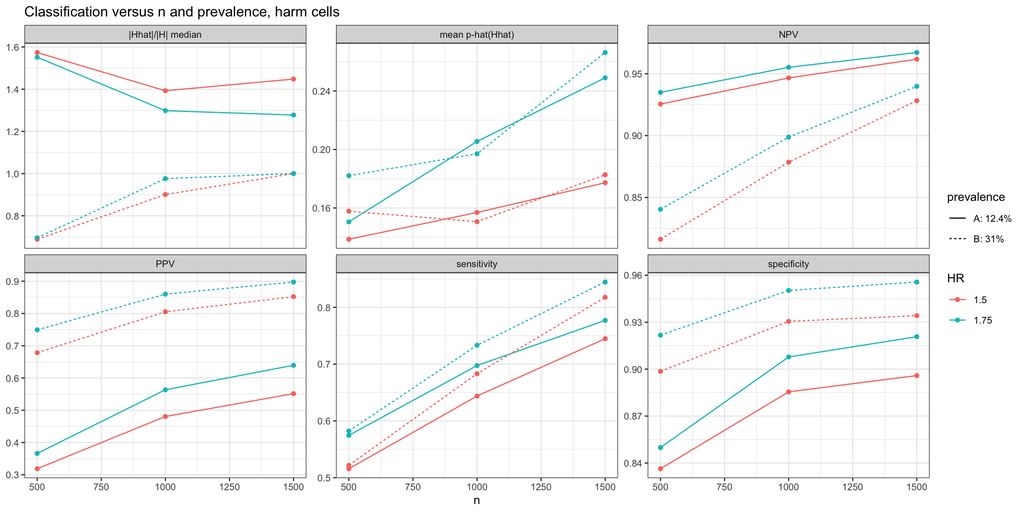

```r
if (!have(labs) || !length(harm_labs)) skip_note("the classification plot") else {
ID <- IDENT[IDENT$arm == "harm", ]
if (!have(ID)) skip_note("the classification plot") else {
IP <- do.call(rbind, lapply(list(
  c("sensitivity","sens"), c("specificity","spec"), c("PPV","ppv"), c("NPV","npv"),
  c("|Hhat|/|H| median","Hhat_over_H_med"), c("mean p-hat(Hhat)","p_hat_mean")),
  function(x) data.frame(n = ID$n, HR = factor(ID$HR), blk = ID$block, what = x[1], v = ID[[x[2]]])))
IP$blk <- factor(IP$blk, levels = c("A","B"), labels = c("A: 12.4%","B: 31%"))
ggplot(IP, aes(n, v, colour = HR, linetype = blk, group = interaction(HR, blk))) +
  geom_point() + geom_line() + facet_wrap(~ what, scales = "free_y", nrow = 2) +
  labs(x = "n", y = NULL, linetype = "prevalence",
       title = "Classification versus n and prevalence, harm cells") + theme_bw(base_size = 10)
}
}
```

# 6 The proposed family, and the admitted set

Two different quantities, reported side by side and never interchanged.

Size distribution per cell, and whether it stabilizes with n — the mechanism Supplementary S8.3 offers for conditional coverage recovering with n.

```r
if (!have(labs)) skip_note("the family-size table") else {
FAM <- do.call(rbind, lapply(labs, function(k) {
  r <- B[[k]]$results; K <- r$n_family[is.finite(r$n_family)]
  q <- stats::quantile(K, c(0, .1, .25, .5, .75, .9, 1), names = FALSE)
  data.frame(cell = k, block = BLK[[k]], n = NN[[k]], HR = HR[[k]], arm = ARM[[k]], reps = length(K),
             K_min = q[1], K_q10 = q[2], K_q25 = q[3], K_med = q[4], K_q75 = q[5],
             K_q90 = q[6], K_max = q[7], K_mean = mean(K), K_sd = stats::sd(K),
             K_cv = stats::sd(K) / mean(K), K_iqr_over_med = (q[5] - q[3]) / q[4]) }))
FAM <- FAM[order(FAM$arm, FAM$block, FAM$HR, FAM$n), ]
kbl(FAM, digits = 3, booktabs = TRUE, row.names = FALSE,
    caption = "The ENUMERATED POOL (n_family) distribution per cell -- descriptive only, and NOT the stratifier: on GRF this pool comes from quantiles of X subject to n_min and does not depend on the outcome: min, q10, q25, median, q75, q90, max, mean, SD, coefficient of variation, and the IQR relative to the median. K_cv and K_iqr_over_med are the stabilization read: a family whose relative spread shrinks with n is the S8.3 mechanism; one whose spread does not is not.") |>
  kable_styling(font_size = 9)
}
```

The ENUMERATED POOL (n_family) distribution per cell -- descriptive only, and NOT the stratifier: on GRF this pool comes from quantiles of X subject to n_min and does not depend on the outcome: min, q10, q25, median, q75, q90, max, mean, SD, coefficient of variation, and the IQR relative to the median. K_cv and K_iqr_over_med are the stabilization read: a family whose relative spread shrinks with n is the S8.3 mechanism; one whose spread does not is not.

| cell | block | n | HR | arm | reps | K_min | K_q10 | K_q25 | K_med | K_q75 | K_q90 | K_max | K_mean | K_sd | K_cv | K_iqr_over_med |
| --- | --- | --- | --- | --- | --- | --- | --- | --- | --- | --- | --- | --- | --- | --- | --- | --- |
| A: HR 1.50, n 500 | A | 500 | 1.50 | harm | 1997 | 712 | 766 | 771 | 776 | 780 | 784 | 870 | 776.327 | 14.042 | 0.018 | 0.012 |
| A: HR 1.50, n 1000 | A | 1000 | 1.50 | harm | 1995 | 779 | 823 | 826 | 830 | 833 | 836 | 914 | 830.191 | 9.229 | 0.011 | 0.008 |
| A: HR 1.50, n 1500 | A | 1500 | 1.50 | harm | 1995 | 780 | 824 | 826 | 830 | 833 | 836 | 913 | 829.772 | 6.745 | 0.008 | 0.008 |
| A: HR 1.75, n 500 | A | 500 | 1.75 | harm | 1999 | 712 | 766 | 771 | 776 | 780 | 784 | 870 | 776.320 | 14.037 | 0.018 | 0.012 |
| A: HR 1.75, n 1000 | A | 1000 | 1.75 | harm | 1998 | 779 | 823 | 826 | 830 | 833 | 836 | 914 | 830.193 | 9.223 | 0.011 | 0.008 |
| A: HR 1.75, n 1500 | A | 1500 | 1.75 | harm | 2000 | 780 | 824 | 826 | 830 | 833 | 836 | 913 | 829.766 | 6.739 | 0.008 | 0.008 |
| B: HR 1.50, n 500 | B | 500 | 1.50 | harm | 2000 | 712 | 766 | 771 | 776 | 780 | 784 | 870 | 776.319 | 14.034 | 0.018 | 0.012 |
| B: HR 1.50, n 1000 | B | 1000 | 1.50 | harm | 2000 | 779 | 823 | 826 | 830 | 833 | 836 | 914 | 830.195 | 9.219 | 0.011 | 0.008 |
| B: HR 1.50, n 1500 | B | 1500 | 1.50 | harm | 2000 | 780 | 824 | 826 | 830 | 833 | 836 | 913 | 829.766 | 6.739 | 0.008 | 0.008 |
| B: HR 1.75, n 500 | B | 500 | 1.75 | harm | 2000 | 712 | 766 | 771 | 776 | 780 | 784 | 870 | 776.319 | 14.034 | 0.018 | 0.012 |
| B: HR 1.75, n 1000 | B | 1000 | 1.75 | harm | 2000 | 779 | 823 | 826 | 830 | 833 | 836 | 914 | 830.195 | 9.219 | 0.011 | 0.008 |
| B: HR 1.75, n 1500 | B | 1500 | 1.75 | harm | 2000 | 780 | 824 | 826 | 830 | 833 | 836 | 913 | 829.766 | 6.739 | 0.008 | 0.008 |
| A: HR 1.00, n 500 | A | 500 | 1.00 | null | 1968 | 712 | 766 | 771 | 776 | 780 | 784 | 870 | 776.309 | 14.062 | 0.018 | 0.012 |
| A: HR 1.00, n 1000 | A | 1000 | 1.00 | null | 1915 | 779 | 823 | 826 | 830 | 833 | 836 | 914 | 830.257 | 9.353 | 0.011 | 0.008 |
| A: HR 1.00, n 1500 | A | 1500 | 1.00 | null | 1735 | 780 | 824 | 826 | 829 | 833 | 836 | 913 | 829.783 | 6.430 | 0.008 | 0.008 |
| B: HR 1.00, n 500 | B | 500 | 1.00 | null | 1994 | 712 | 766 | 771 | 776 | 780 | 784 | 870 | 776.325 | 14.053 | 0.018 | 0.012 |
| B: HR 1.00, n 1000 | B | 1000 | 1.00 | null | 1996 | 779 | 823 | 826 | 830 | 833 | 836 | 914 | 830.186 | 9.225 | 0.011 | 0.008 |
| B: HR 1.00, n 1500 | B | 1500 | 1.00 | null | 1987 | 780 | 824 | 826 | 830 | 833 | 836 | 913 | 829.778 | 6.746 | 0.008 | 0.008 |

```r
if (!have(labs)) skip_note("the admitted_n table") else {
ADM <- do.call(rbind, lapply(labs, function(k) {
  r <- B[[k]]$results; A <- r$admitted_n[is.finite(r$admitted_n)]
  if (!length(A)) return(NULL)
  q <- stats::quantile(A, c(0, .1, .25, .5, .75, .9, 1), names = FALSE)
  K <- r$n_family[is.finite(r$n_family)]
  ii <- is.finite(r$admitted_n) & is.finite(r$n_family)
  data.frame(cell = k, block = BLK[[k]], n = NN[[k]], HR = HR[[k]], reps = length(A),
             adm_min = q[1], adm_q10 = q[2], adm_q25 = q[3], adm_med = q[4], adm_q75 = q[5],
             adm_q90 = q[6], adm_max = q[7], adm_mean = mean(A), adm_sd = stats::sd(A),
             adm_cv = stats::sd(A) / mean(A),
             adm_eq0 = sum(A == 0L),
             K_med = stats::median(K), K_cv = stats::sd(K) / mean(K),
             share_admitted = stats::median(r$admitted_n[ii] / r$n_family[ii]),
             rho_adm_K = suppressWarnings(stats::cor(r$admitted_n[ii], r$n_family[ii]))) }))
ADM <- ADM[order(ADM$block, ADM$HR, ADM$n), ]
kbl(ADM, digits = 4, booktabs = TRUE, row.names = FALSE,
    caption = "THE ADMITTED SET (admitted_n) per cell -- THE STRATIFIER used in the strata section. admitted_n counts the enumerated candidates whose inferential effect clears the resolved admission floor (R/forestsearch_helpers.R:1654). n_family (K_med, K_cv) is shown beside it to make the contrast explicit: the enumerated pool is outcome-independent and near-constant, the admitted set is neither. share_admitted is the per-replicate median of admitted_n / n_family; adm_eq0 counts the replicates where nothing cleared the floor, which is exactly the empty-admitted-set non-detection path.") |>
  kable_styling(font_size = 9)
}
```

THE ADMITTED SET (admitted_n) per cell -- THE STRATIFIER used in the strata section. admitted_n counts the enumerated candidates whose inferential effect clears the resolved admission floor (R/forestsearch_helpers.R:1654). n_family (K_med, K_cv) is shown beside it to make the contrast explicit: the enumerated pool is outcome-independent and near-constant, the admitted set is neither. share_admitted is the per-replicate median of admitted_n / n_family; adm_eq0 counts the replicates where nothing cleared the floor, which is exactly the empty-admitted-set non-detection path.

| cell | block | n | HR | reps | adm_min | adm_q10 | adm_q25 | adm_med | adm_q75 | adm_q90 | adm_max | adm_mean | adm_sd | adm_cv | adm_eq0 | K_med | K_cv | share_admitted | rho_adm_K |
| --- | --- | --- | --- | --- | --- | --- | --- | --- | --- | --- | --- | --- | --- | --- | --- | --- | --- | --- | --- |
| A: HR 1.00, n 500 | A | 500 | 1.00 | 1970 | 0 | 15.0 | 32.00 | 61.5 | 113.00 | 179.1 | 551 | 83.4629 | 74.9270 | 0.8977 | 2 | 776 | 0.0181 | 0.0792 | 0.0326 |
| A: HR 1.00, n 1000 | A | 1000 | 1.00 | 1917 | 0 | 9.0 | 17.00 | 38.0 | 70.00 | 109.0 | 304 | 50.7966 | 45.7926 | 0.9015 | 2 | 830 | 0.0113 | 0.0455 | 0.0164 |
| A: HR 1.00, n 1500 | A | 1500 | 1.00 | 1743 | 0 | 5.0 | 11.00 | 23.0 | 42.00 | 70.0 | 279 | 31.8439 | 30.0964 | 0.9451 | 8 | 829 | 0.0077 | 0.0277 | 0.0190 |
| A: HR 1.50, n 500 | A | 500 | 1.50 | 1997 | 2 | 36.0 | 65.00 | 115.0 | 179.00 | 260.4 | 600 | 134.3385 | 94.7963 | 0.7057 | 0 | 776 | 0.0181 | 0.1469 | 0.0337 |
| A: HR 1.50, n 1000 | A | 1000 | 1.50 | 1995 | 3 | 34.0 | 57.00 | 93.0 | 145.00 | 198.0 | 471 | 108.0822 | 68.4955 | 0.6337 | 0 | 830 | 0.0111 | 0.1122 | 0.0270 |
| A: HR 1.50, n 1500 | A | 1500 | 1.50 | 1995 | 2 | 26.0 | 47.00 | 76.0 | 114.00 | 156.6 | 369 | 85.5333 | 52.8368 | 0.6177 | 0 | 830 | 0.0081 | 0.0910 | 0.0180 |
| A: HR 1.75, n 500 | A | 500 | 1.75 | 1999 | 3 | 49.0 | 81.50 | 136.0 | 208.00 | 293.0 | 624 | 155.7344 | 100.6219 | 0.6461 | 0 | 776 | 0.0181 | 0.1746 | 0.0382 |
| A: HR 1.75, n 1000 | A | 1000 | 1.75 | 1998 | 6 | 50.0 | 78.00 | 121.0 | 176.00 | 234.0 | 510 | 134.4209 | 74.9950 | 0.5579 | 0 | 830 | 0.0111 | 0.1464 | 0.0265 |
| A: HR 1.75, n 1500 | A | 1500 | 1.75 | 2000 | 5 | 43.0 | 69.00 | 105.0 | 147.00 | 191.0 | 439 | 112.4235 | 59.0475 | 0.5252 | 0 | 830 | 0.0081 | 0.1260 | 0.0192 |
| B: HR 1.00, n 500 | B | 500 | 1.00 | 1995 | 0 | 52.0 | 95.50 | 166.0 | 281.00 | 397.6 | 721 | 200.6922 | 135.4153 | 0.6747 | 1 | 776 | 0.0181 | 0.2138 | 0.0312 |
| B: HR 1.00, n 1000 | B | 1000 | 1.00 | 1996 | 3 | 47.0 | 82.00 | 141.0 | 225.00 | 328.5 | 701 | 166.3477 | 113.0562 | 0.6796 | 0 | 830 | 0.0111 | 0.1697 | 0.0186 |
| B: HR 1.00, n 1500 | B | 1500 | 1.00 | 1987 | 3 | 34.0 | 66.00 | 115.0 | 176.00 | 250.0 | 649 | 130.8978 | 89.5505 | 0.6841 | 0 | 830 | 0.0081 | 0.1379 | 0.0172 |
| B: HR 1.50, n 500 | B | 500 | 1.50 | 2000 | 16 | 187.0 | 269.00 | 383.0 | 497.00 | 578.1 | 752 | 383.4980 | 146.5631 | 0.3822 | 0 | 776 | 0.0181 | 0.4932 | 0.0344 |
| B: HR 1.50, n 1000 | B | 1000 | 1.50 | 2000 | 52 | 233.9 | 310.00 | 406.0 | 504.00 | 586.0 | 758 | 407.0325 | 131.3588 | 0.3227 | 0 | 830 | 0.0111 | 0.4898 | 0.0240 |
| B: HR 1.50, n 1500 | B | 1500 | 1.50 | 2000 | 96 | 245.0 | 309.00 | 400.5 | 491.00 | 555.0 | 734 | 400.2245 | 118.9893 | 0.2973 | 0 | 830 | 0.0081 | 0.4818 | 0.0419 |
| B: HR 1.75, n 500 | B | 500 | 1.75 | 2000 | 53 | 252.0 | 341.00 | 449.0 | 545.25 | 609.1 | 755 | 440.4285 | 135.9703 | 0.3087 | 0 | 776 | 0.0181 | 0.5782 | 0.0340 |
| B: HR 1.75, n 1000 | B | 1000 | 1.75 | 2000 | 116 | 320.9 | 400.75 | 487.5 | 566.25 | 627.1 | 765 | 480.6935 | 116.2931 | 0.2419 | 0 | 830 | 0.0111 | 0.5864 | 0.0324 |
| B: HR 1.75, n 1500 | B | 1500 | 1.75 | 2000 | 152 | 335.0 | 409.75 | 493.5 | 562.00 | 607.1 | 761 | 482.1220 | 104.4972 | 0.2167 | 0 | 830 | 0.0081 | 0.5948 | 0.0539 |

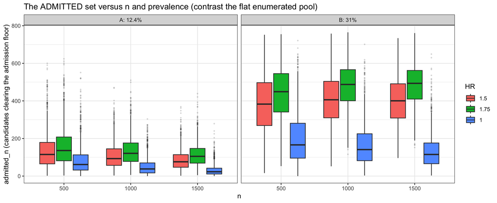

```r
if (!have(labs)) skip_note("the admitted_n plot") else {
AK <- do.call(rbind, lapply(labs, function(k) {
  r <- B[[k]]$results
  data.frame(cell = k, block = BLK[[k]], n = factor(NN[[k]]), HR = factor(HR[[k]]),
             A = r$admitted_n[is.finite(r$admitted_n)]) }))
AK$blk <- factor(AK$block, levels = c("A","B"), labels = c("A: 12.4%","B: 31%"))
print(ggplot(AK, aes(n, A, fill = HR)) + geom_boxplot(outlier.alpha = 0.15, outlier.size = 0.5) +
  facet_wrap(~ blk) +
  labs(x = "n", y = "admitted_n (candidates clearing the admission floor)",
       title = "The ADMITTED set versus n and prevalence (contrast the flat enumerated pool)") +
  theme_bw(base_size = 11))
}
```

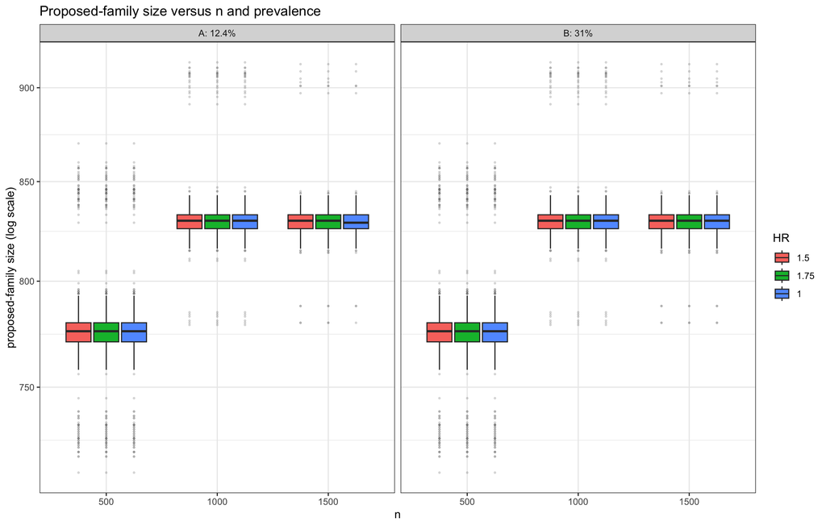

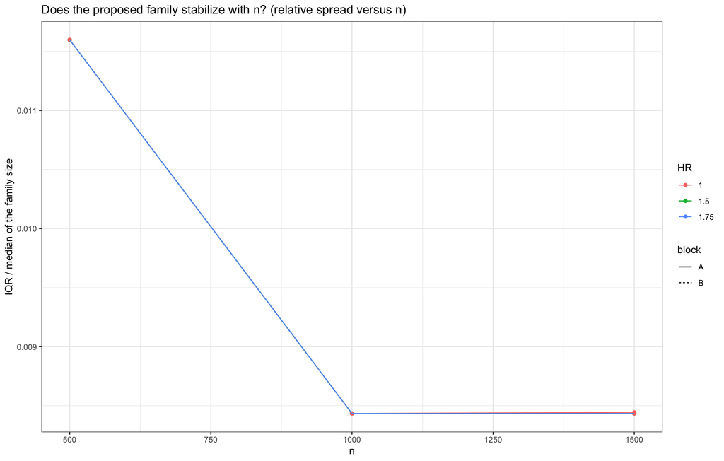

```r
if (!have(labs)) skip_note("the family-size plots") else {
FK <- do.call(rbind, lapply(labs, function(k) {
  r <- B[[k]]$results
  data.frame(cell = k, block = BLK[[k]], n = factor(NN[[k]]), HR = factor(HR[[k]]),
             arm = ARM[[k]], K = r$n_family[is.finite(r$n_family)]) }))
FK$blk <- factor(FK$block, levels = c("A","B"), labels = c("A: 12.4%","B: 31%"))
print(ggplot(FK, aes(n, K, fill = HR)) + geom_boxplot(outlier.alpha = 0.15, outlier.size = 0.5) +
  scale_y_log10() + facet_wrap(~ blk) +
  labs(x = "n", y = "proposed-family size (log scale)",
       title = "Proposed-family size versus n and prevalence") + theme_bw(base_size = 11))
print(ggplot(FAM, aes(n, K_iqr_over_med, colour = factor(HR), group = interaction(HR, block),
                      linetype = block)) +
  geom_point() + geom_line() +
  labs(x = "n", y = "IQR / median of the family size", colour = "HR", linetype = "block",
       title = "Does the proposed family stabilize with n? (relative spread versus n)") +
  theme_bw(base_size = 11))
}
```

# 7 Beside the FS grid, with the confound stated

> **The confound, and it is not the same in the two blocks.**

> FS and GRF always differ in **the identifier** *and* in **how the family is constructed**, and each conditions on **a different detection set**. FS’s family is the consistency-screened candidate table. GRF’s family, as it reaches the MR layer, is the **enumerated candidate pool** `.grf_dr_candidates()` builds from quantiles of X subject to `n_min` (`R/grf_subgroup_labels.R:255-277`, carried to MR at `R/grf_main.R:419` and `R/forestsearch_main.R:2520`); the doubly-robust scores enter only the `effect` column, and the admission floor is applied **per draw** inside MR rather than fixing the family. That is a statement of mechanism, recorded as a finding about how GRF’s family is constructed and re-evaluated. No fixed-family conclusion is drawn from it anywhere in this document, and no coverage column is qualified either way on account of it.

> **A third difference applies at 12.4% only — the criterion itself.**
> - **Block B (31%).** The FS comparators are `cert20` and `e1stud`, both **`effMaxSG` at ε = 0.20** — **GRF’s own criterion, exactly**. Here the comparison is at a matched criterion, and the confound is identifier + family construction + detection set.
> - **Block A (12.4%).** The FS comparators are `p12ext` and `tier2`, both **`maxeffCons` at ε = 0.10** — a **different selection functional** (the consistency-screened effect argmax, not the largest subgroup within an ε-band) at **half the band width**. Here the criterion is a **fourth** confounded difference, and a Block A gap cannot be read as engine behaviour even in part.

> Every FS number in this document therefore carries its own `campaign / sg_focus / eps`. A row-by-row gap is **not** attributable to any one difference alone. What follows is **descriptive, not a contest**, and the FS numbers are reference lines, not a bar.

```r
FSC <- list(
  # 31% -- cert20 (n 1000/1500) and e1stud (n 500), read as they stand
  list(lab="FS B: HR 1.50, n 500",  blk="B", n=500L,  hr=1.50, f="fs_effMaxSG_fb_mr_field_m1_h150_knoise0_n500_z1q60_nb20_e1stud_combined_1_2000.rds"),
  list(lab="FS B: HR 1.50, n 1000", blk="B", n=1000L, hr=1.50, f="fs_effMaxSG_fb_mr_field_m1_h150_knoise0_n1000_z1q60_nb20_cert20_combined_1_2000.rds"),
  list(lab="FS B: HR 1.50, n 1500", blk="B", n=1500L, hr=1.50, f="fs_effMaxSG_fb_mr_field_m1_h150_knoise0_n1500_z1q60_nb20_cert20_combined_1_2000.rds"),
  list(lab="FS B: HR 1.75, n 500",  blk="B", n=500L,  hr=1.75, f="fs_effMaxSG_fb_mr_field_m1_h175_knoise0_n500_z1q60_nb20_e1stud_combined_1_2000.rds"),
  list(lab="FS B: HR 1.75, n 1000", blk="B", n=1000L, hr=1.75, f="fs_effMaxSG_fb_mr_field_m1_h175_knoise0_n1000_z1q60_nb20_cert20_combined_1_2000.rds"),
  list(lab="FS B: HR 1.75, n 1500", blk="B", n=1500L, hr=1.75, f="fs_effMaxSG_fb_mr_field_m1_h175_knoise0_n1500_z1q60_nb20_cert20_combined_1_2000.rds"),
  # 12.4% -- tier2 (n 500 HR 1.75, n 1000/1500 HR 1.75) and p12ext
  list(lab="FS A: HR 1.50, n 500",  blk="A", n=500L,  hr=1.50, f="fs_maxeffCons_fb_mr_field_m1_h150_knoise0_n500_p12ext_combined_1_2000.rds"),
  list(lab="FS A: HR 1.50, n 1000", blk="A", n=1000L, hr=1.50, f="fs_maxeffCons_fb_mr_field_m1_h150_knoise0_n1000_p12ext_combined_1_2000.rds"),
  list(lab="FS A: HR 1.50, n 1500", blk="A", n=1500L, hr=1.50, f="fs_maxeffCons_fb_mr_field_m1_h150_knoise0_n1500_p12ext_combined_1_2000.rds"),
  list(lab="FS A: HR 1.75, n 500",  blk="A", n=500L,  hr=1.75, f="fs_maxeffCons_fb_mr_field_m1_h175_knoise0_n500_tier2_combined_1_2000.rds"),
  list(lab="FS A: HR 1.75, n 1000", blk="A", n=1000L, hr=1.75, f="fs_maxeffCons_fb_mr_field_m1_h175_knoise0_n1000_tier2_combined_1_2000.rds"),
  list(lab="FS A: HR 1.75, n 1500", blk="A", n=1500L, hr=1.75, f="fs_maxeffCons_fb_mr_field_m1_h175_knoise0_n1500_tier2_combined_1_2000.rds"))
FSC <- Filter(function(x) file.exists(paste0(R, x$f)), FSC)
if (!length(FSC)) skip_note("the FS comparator grid (no committed FS bundle on disk)") else {
FSG <- do.call(rbind, lapply(FSC, function(x) {
  b <- readRDS(paste0(R, x$f)); r <- b$results
  d <- r[r$detected %in% 1L & is.finite(r$betaHhat_H) & is.finite(r$betaHhat_Hc) &
         is.finite(r$fld_H_lo1s) & is.finite(r$fld_Hc_up1s_s), , drop = FALSE]
  data.frame(cell = x$lab, engine = "FS (consistency)", block = x$blk, n = x$n, HR = x$hr,
             criterion = sprintf("%s / %s / eps %s", b$meta$campaign_tag %||% NA,
                                 b$meta$sg_focus %||% NA, format(b$meta$effect_neighborhood %||% NA)),
             campaign = b$meta$campaign_tag %||% NA, focus = b$meta$sg_focus %||% NA,
             eps = b$meta$effect_neighborhood %||% NA_real_,
             detection = mean(r$detected %in% 1L), n_eval = nrow(d),
             K_med = stats::median(r$n_family, na.rm = TRUE),
             harm_field = mean(d$betaHhat_H >= d$fld_H_lo1s),
             comp_field_s = mean(d$betaHhat_Hc <= d$fld_Hc_up1s_s),
             ij2_H = mean(d$betaHhat_H >= d$mr_H_lo & d$betaHhat_H <= d$mr_H_hi),
             ij2_Hc = mean(d$betaHhat_Hc >= d$mr_Hc_lo & d$betaHhat_Hc <= d$mr_Hc_hi),
             sens = mean(d$sens), ppv = mean(d$ppv)) }))
DNG <- if (have(VSN)) do.call(rbind, lapply(which(VSN$arm == "harm"), function(i) {
  k <- VSN$cell[i]; d <- B[[k]]$results
  dd <- d[d$detected %in% 1L, , drop = FALSE]
  data.frame(cell = k, engine = "GRF (grfmr)", block = VSN$block[i], n = VSN$n[i], HR = VSN$HR[i],
             criterion = "grfmr / effMaxSG / eps 0.2",
             campaign = "grfmr", focus = "effMaxSG", eps = 0.20,
             detection = mean(d$detected %in% 1L), n_eval = VSN$n_eval[i],
             K_med = stats::median(d$n_family, na.rm = TRUE),
             harm_field = VSN$harm_field[i], comp_field_s = VSN$comp_field_s[i],
             ij2_H = VSN$ij2_H[i], ij2_Hc = VSN$ij2_Hc[i],
             sens = mean(dd$sens), ppv = mean(dd$ppv)) })) else NULL
SIDE <- rbind(FSG, DNG)
SIDE <- SIDE[order(SIDE$block, SIDE$HR, SIDE$n, SIDE$engine), ]
kbl(SIDE, digits = 4, booktabs = TRUE, row.names = FALSE,
    caption = "GRF beside the committed FS grid (cert20 / tier2 / p12ext read AS THEY STAND, not re-run), matched on prevalence block, HR and n. DIFFERENT IDENTIFIER AND DIFFERENT FAMILY CONSTRUCTION, each conditioning on a different detection set -- AND, at 12.4% ONLY, a DIFFERENT CRITERION: the `criterion` column carries each row's campaign / sg_focus / eps, which is effMaxSG / eps 0.20 on both engines in Block B but maxeffCons / eps 0.10 for FS in Block A. See the confound above. GRF's coverage columns are coverage over detected replicates; FS's are its own. Descriptive, not a contest; no criterion is applied.") |>
  kable_styling(font_size = 9)
}
```

GRF beside the committed FS grid (cert20 / tier2 / p12ext read AS THEY STAND, not re-run), matched on prevalence block, HR and n. DIFFERENT IDENTIFIER AND DIFFERENT FAMILY CONSTRUCTION, each conditioning on a different detection set -- AND, at 12.4% ONLY, a DIFFERENT CRITERION: the `criterion` column carries each row's campaign / sg_focus / eps, which is effMaxSG / eps 0.20 on both engines in Block B but maxeffCons / eps 0.10 for FS in Block A. See the confound above. GRF's coverage columns are coverage over detected replicates; FS's are its own. Descriptive, not a contest; no criterion is applied.

| cell | engine | block | n | HR | criterion | campaign | focus | eps | detection | n_eval | K_med | harm_field | comp_field_s | ij2_H | ij2_Hc | sens | ppv |
| --- | --- | --- | --- | --- | --- | --- | --- | --- | --- | --- | --- | --- | --- | --- | --- | --- | --- |
| FS A: HR 1.50, n 500 | FS (consistency) | A | 500 | 1.50 | p12ext / maxeffCons / eps 0.1 | p12ext | maxeffCons | 0.1 | 0.9110 | 1822 | 1223 | 0.9654 | 0.9374 | 0.9769 | 1.0000 | 0.5732 | 0.5082 |
| A: HR 1.50, n 500 | GRF (grfmr) | A | 500 | 1.50 | grfmr / effMaxSG / eps 0.2 | grfmr | effMaxSG | 0.2 | 0.9985 | 1997 | 776 | 0.9434 | 0.9319 | 0.9890 | 0.9995 | 0.5158 | 0.3187 |
| FS A: HR 1.50, n 1000 | FS (consistency) | A | 1000 | 1.50 | p12ext / maxeffCons / eps 0.1 | p12ext | maxeffCons | 0.1 | 0.9740 | 1948 | 1299 | 0.9410 | 0.9533 | 0.9322 | 0.9995 | 0.6975 | 0.7059 |
| A: HR 1.50, n 1000 | GRF (grfmr) | A | 1000 | 1.50 | grfmr / effMaxSG / eps 0.2 | grfmr | effMaxSG | 0.2 | 0.9975 | 1995 | 830 | 0.9404 | 0.9519 | 0.9870 | 1.0000 | 0.6438 | 0.4806 |
| FS A: HR 1.50, n 1500 | FS (consistency) | A | 1500 | 1.50 | p12ext / maxeffCons / eps 0.1 | p12ext | maxeffCons | 0.1 | 0.9880 | 1976 | 1297 | 0.9565 | 0.9585 | 0.9008 | 0.9990 | 0.8198 | 0.8200 |
| A: HR 1.50, n 1500 | GRF (grfmr) | A | 1500 | 1.50 | grfmr / effMaxSG / eps 0.2 | grfmr | effMaxSG | 0.2 | 0.9975 | 1995 | 830 | 0.9579 | 0.9529 | 0.9799 | 0.9995 | 0.7448 | 0.5515 |
| FS A: HR 1.75, n 500 | FS (consistency) | A | 500 | 1.75 | tier2 / maxeffCons / eps 0.1 | tier2 | maxeffCons | 0.1 | 0.9500 | 1900 | 1223 | 0.9663 | 0.9405 | 0.9611 | 1.0000 | 0.6594 | 0.5902 |
| A: HR 1.75, n 500 | GRF (grfmr) | A | 500 | 1.75 | grfmr / effMaxSG / eps 0.2 | grfmr | effMaxSG | 0.2 | 0.9995 | 1999 | 776 | 0.9415 | 0.9335 | 0.9900 | 0.9995 | 0.5746 | 0.3661 |
| FS A: HR 1.75, n 1000 | FS (consistency) | A | 1000 | 1.75 | tier2 / maxeffCons / eps 0.1 | tier2 | maxeffCons | 0.1 | 0.9950 | 1990 | 1299 | 0.9437 | 0.9563 | 0.9166 | 0.9995 | 0.7867 | 0.7943 |
| A: HR 1.75, n 1000 | GRF (grfmr) | A | 1000 | 1.75 | grfmr / effMaxSG / eps 0.2 | grfmr | effMaxSG | 0.2 | 0.9990 | 1998 | 830 | 0.9364 | 0.9540 | 0.9775 | 1.0000 | 0.6975 | 0.5634 |
| FS A: HR 1.75, n 1500 | FS (consistency) | A | 1500 | 1.75 | tier2 / maxeffCons / eps 0.1 | tier2 | maxeffCons | 0.1 | 0.9990 | 1998 | 1297 | 0.9600 | 0.9605 | 0.9129 | 0.9995 | 0.8829 | 0.8767 |
| A: HR 1.75, n 1500 | GRF (grfmr) | A | 1500 | 1.75 | grfmr / effMaxSG / eps 0.2 | grfmr | effMaxSG | 0.2 | 1.0000 | 2000 | 830 | 0.9535 | 0.9560 | 0.9755 | 1.0000 | 0.7770 | 0.6394 |
| FS B: HR 1.50, n 500 | FS (consistency) | B | 500 | 1.50 | e1stud / effMaxSG / eps 0.2 | e1stud | effMaxSG | 0.2 | 0.9995 | 1999 | 1223 | 0.9745 | 0.9125 | 0.9810 | 1.0000 | 0.5903 | 0.7063 |
| B: HR 1.50, n 500 | GRF (grfmr) | B | 500 | 1.50 | grfmr / effMaxSG / eps 0.2 | grfmr | effMaxSG | 0.2 | 1.0000 | 2000 | 776 | 0.9295 | 0.9185 | 0.9840 | 1.0000 | 0.5219 | 0.6785 |
| FS B: HR 1.50, n 1000 | FS (consistency) | B | 1000 | 1.50 | cert20 / effMaxSG / eps 0.2 | cert20 | effMaxSG | 0.2 | 1.0000 | 2000 | 1299 | 0.9585 | 0.9420 | 0.9710 | 1.0000 | 0.7078 | 0.8040 |
| B: HR 1.50, n 1000 | GRF (grfmr) | B | 1000 | 1.50 | grfmr / effMaxSG / eps 0.2 | grfmr | effMaxSG | 0.2 | 1.0000 | 2000 | 830 | 0.9525 | 0.9460 | 0.9670 | 0.9990 | 0.6831 | 0.8053 |
| FS B: HR 1.50, n 1500 | FS (consistency) | B | 1500 | 1.50 | cert20 / effMaxSG / eps 0.2 | cert20 | effMaxSG | 0.2 | 1.0000 | 2000 | 1297 | 0.9615 | 0.9465 | 0.9755 | 0.9995 | 0.8391 | 0.8374 |
| B: HR 1.50, n 1500 | GRF (grfmr) | B | 1500 | 1.50 | grfmr / effMaxSG / eps 0.2 | grfmr | effMaxSG | 0.2 | 1.0000 | 2000 | 830 | 0.9690 | 0.9480 | 0.9730 | 0.9995 | 0.8176 | 0.8520 |
| FS B: HR 1.75, n 500 | FS (consistency) | B | 500 | 1.75 | e1stud / effMaxSG / eps 0.2 | e1stud | effMaxSG | 0.2 | 0.9995 | 1999 | 1223 | 0.9700 | 0.9195 | 0.9720 | 0.9995 | 0.6603 | 0.7785 |
| B: HR 1.75, n 500 | GRF (grfmr) | B | 500 | 1.75 | grfmr / effMaxSG / eps 0.2 | grfmr | effMaxSG | 0.2 | 1.0000 | 2000 | 776 | 0.9300 | 0.9210 | 0.9730 | 1.0000 | 0.5823 | 0.7493 |
| FS B: HR 1.75, n 1000 | FS (consistency) | B | 1000 | 1.75 | cert20 / effMaxSG / eps 0.2 | cert20 | effMaxSG | 0.2 | 1.0000 | 2000 | 1299 | 0.9525 | 0.9420 | 0.9740 | 1.0000 | 0.7689 | 0.8600 |
| B: HR 1.75, n 1000 | GRF (grfmr) | B | 1000 | 1.75 | grfmr / effMaxSG / eps 0.2 | grfmr | effMaxSG | 0.2 | 1.0000 | 2000 | 830 | 0.9515 | 0.9510 | 0.9640 | 1.0000 | 0.7332 | 0.8600 |
| FS B: HR 1.75, n 1500 | FS (consistency) | B | 1500 | 1.75 | cert20 / effMaxSG / eps 0.2 | cert20 | effMaxSG | 0.2 | 1.0000 | 2000 | 1297 | 0.9610 | 0.9460 | 0.9805 | 0.9995 | 0.8740 | 0.8827 |
| B: HR 1.75, n 1500 | GRF (grfmr) | B | 1500 | 1.75 | grfmr / effMaxSG / eps 0.2 | grfmr | effMaxSG | 0.2 | 1.0000 | 2000 | 830 | 0.9645 | 0.9410 | 0.9810 | 1.0000 | 0.8445 | 0.8975 |

# 8 p-hat and the recovery diagnostics on a model-generated family

```r
recov_cols <- c("fld_recov_sens_H","fld_recov_ppv_H","fld_recov_sens_Hc","fld_recov_npv_Hc",
                "fld_recov_q10","fld_recov_q50","fld_recov_q90","fld_recov_share1","fld_recov_n_used")
if (!have(labs)) skip_note("the recovery diagnostics") else {
RCV <- do.call(rbind, lapply(labs, function(k) {
  r <- B[[k]]$results; d <- r[r$detected %in% 1L, , drop = FALSE]
  if (!nrow(d) || !all(recov_cols %in% names(d))) return(NULL)
  qq <- function(x) stats::quantile(x[is.finite(x)], c(.1,.5,.9), names = FALSE)
  ph <- d$p_hat_H[is.finite(d$p_hat_H)]
  data.frame(cell = k, block = BLK[[k]], n = NN[[k]], HR = HR[[k]], arm = ARM[[k]], n_det = nrow(d),
             p_hat_q10 = qq(ph)[1], p_hat_med = qq(ph)[2], p_hat_q90 = qq(ph)[3], p_hat_mean = mean(ph),
             rho_c_med = stats::median(d$fld_Hc_scale_ratio),
             scale_cv_med = stats::median(d$fld_Hc_scale_cv),
             sens_H = mean(d$fld_recov_sens_H), ppv_H = mean(d$fld_recov_ppv_H),
             sens_Hc = mean(d$fld_recov_sens_Hc), npv_Hc = mean(d$fld_recov_npv_Hc),
             cont_q10 = mean(d$fld_recov_q10), cont_q50 = mean(d$fld_recov_q50),
             cont_q90 = mean(d$fld_recov_q90), share1 = mean(d$fld_recov_share1),
             n_used = mean(d$fld_recov_n_used)) }))
RCV <- RCV[order(RCV$arm, RCV$block, RCV$HR, RCV$n), ]
kbl(RCV, digits = 4, booktabs = TRUE, row.names = FALSE,
    caption = "p-hat and the recovery diagnostics on GRF's MODEL-GENERATED family: the p-hat(Hhat) distribution (q10 / median / q90 / mean); rho-c = the complement scale ratio and the within-replicate scale CV; and the nine recovery columns -- sens_H / ppv_H / sens_Hc / npv_Hc and the containment quantiles q10 / q50 / q90 with the share at exactly 1 and the evaluation count. Described, not interpreted beyond the record.") |>
  kable_styling(font_size = 8)
}
```

p-hat and the recovery diagnostics on GRF's MODEL-GENERATED family: the p-hat(Hhat) distribution (q10 / median / q90 / mean); rho-c = the complement scale ratio and the within-replicate scale CV; and the nine recovery columns -- sens_H / ppv_H / sens_Hc / npv_Hc and the containment quantiles q10 / q50 / q90 with the share at exactly 1 and the evaluation count. Described, not interpreted beyond the record.

| cell | block | n | HR | arm | n_det | p_hat_q10 | p_hat_med | p_hat_q90 | p_hat_mean | rho_c_med | scale_cv_med | sens_H | ppv_H | sens_Hc | npv_Hc | cont_q10 | cont_q50 | cont_q90 | share1 | n_used |
| --- | --- | --- | --- | --- | --- | --- | --- | --- | --- | --- | --- | --- | --- | --- | --- | --- | --- | --- | --- | --- |
| A: HR 1.50, n 500 | A | 500 | 1.50 | harm | 1997 | 0.0300 | 0.0986 | 0.3041 | 0.1386 | 1.0165 | 0.0452 | 0.4035 | 0.4465 | 0.8703 | 0.8460 | 0.1037 | 0.3728 | 0.7501 | 0.0391 | 999.8998 |
| A: HR 1.50, n 1000 | A | 1000 | 1.50 | harm | 1995 | 0.0353 | 0.1140 | 0.3439 | 0.1569 | 1.0119 | 0.0430 | 0.4479 | 0.4708 | 0.8891 | 0.8770 | 0.1270 | 0.4294 | 0.7970 | 0.0604 | 999.9348 |
| A: HR 1.50, n 1500 | A | 1500 | 1.50 | harm | 1995 | 0.0419 | 0.1340 | 0.3759 | 0.1772 | 1.0092 | 0.0446 | 0.5181 | 0.5293 | 0.8937 | 0.8877 | 0.1974 | 0.5215 | 0.8349 | 0.0871 | 999.8842 |
| A: HR 1.75, n 500 | A | 500 | 1.75 | harm | 1999 | 0.0328 | 0.1114 | 0.3246 | 0.1505 | 1.0169 | 0.0442 | 0.4219 | 0.4592 | 0.8746 | 0.8539 | 0.1156 | 0.3975 | 0.7680 | 0.0443 | 999.9500 |
| A: HR 1.75, n 1000 | A | 1000 | 1.75 | harm | 1998 | 0.0475 | 0.1575 | 0.4263 | 0.2055 | 1.0069 | 0.0399 | 0.4950 | 0.4991 | 0.8985 | 0.8948 | 0.1656 | 0.4925 | 0.8296 | 0.0880 | 999.9835 |
| A: HR 1.75, n 1500 | A | 1500 | 1.75 | harm | 2000 | 0.0600 | 0.2025 | 0.4956 | 0.2490 | 1.0015 | 0.0396 | 0.5838 | 0.5686 | 0.9078 | 0.9111 | 0.2578 | 0.6063 | 0.8771 | 0.1399 | 999.9690 |
| B: HR 1.50, n 500 | B | 500 | 1.50 | harm | 2000 | 0.0332 | 0.1128 | 0.3519 | 0.1578 | 1.0193 | 0.0510 | 0.4499 | 0.5129 | 0.8772 | 0.8404 | 0.1533 | 0.4320 | 0.7795 | 0.0477 | 1000.0000 |
| B: HR 1.50, n 1000 | B | 1000 | 1.50 | harm | 2000 | 0.0286 | 0.1114 | 0.3318 | 0.1506 | 1.0573 | 0.0567 | 0.4853 | 0.6097 | 0.9012 | 0.8348 | 0.1927 | 0.4769 | 0.7914 | 0.0452 | 1000.0000 |
| B: HR 1.50, n 1500 | B | 1500 | 1.50 | harm | 2000 | 0.0386 | 0.1445 | 0.3784 | 0.1827 | 1.0692 | 0.0621 | 0.5691 | 0.7235 | 0.9162 | 0.8373 | 0.2774 | 0.5801 | 0.8440 | 0.0653 | 1000.0000 |
| B: HR 1.75, n 500 | B | 500 | 1.75 | harm | 2000 | 0.0400 | 0.1391 | 0.3877 | 0.1821 | 1.0233 | 0.0524 | 0.4790 | 0.5464 | 0.8850 | 0.8473 | 0.1782 | 0.4694 | 0.7995 | 0.0561 | 1000.0000 |
| B: HR 1.75, n 1000 | B | 1000 | 1.75 | harm | 2000 | 0.0432 | 0.1579 | 0.4092 | 0.1970 | 1.0651 | 0.0576 | 0.5305 | 0.6647 | 0.9142 | 0.8480 | 0.2362 | 0.5351 | 0.8209 | 0.0610 | 1000.0000 |
| B: HR 1.75, n 1500 | B | 1500 | 1.75 | harm | 2000 | 0.0620 | 0.2363 | 0.5148 | 0.2663 | 1.0657 | 0.0604 | 0.6211 | 0.7726 | 0.9314 | 0.8606 | 0.3371 | 0.6385 | 0.8812 | 0.1151 | 1000.0000 |
| A: HR 1.00, n 500 | A | 500 | 1.00 | null | 1968 | 0.0262 | 0.0885 | 0.2765 | 0.1267 | 1.0103 | 0.0470 | 0.3771 | 0.4173 | 0.8606 | 0.8364 | 0.0862 | 0.3379 | 0.7296 | 0.0368 | 999.5813 |
| A: HR 1.00, n 1000 | A | 1000 | 1.00 | null | 1915 | 0.0254 | 0.0716 | 0.2163 | 0.1037 | 1.0136 | 0.0473 | 0.3702 | 0.4187 | 0.8701 | 0.8431 | 0.0783 | 0.3319 | 0.7243 | 0.0334 | 999.3958 |
| A: HR 1.00, n 1500 | A | 1500 | 1.00 | null | 1735 | 0.0284 | 0.0740 | 0.1848 | 0.0965 | 1.0132 | 0.0524 | 0.4023 | 0.4418 | 0.8626 | 0.8431 | 0.1003 | 0.3679 | 0.7588 | 0.0389 | 998.3406 |
| B: HR 1.00, n 500 | B | 500 | 1.00 | null | 1994 | 0.0252 | 0.0898 | 0.2899 | 0.1293 | 1.0095 | 0.0481 | 0.3897 | 0.4414 | 0.8613 | 0.8297 | 0.0988 | 0.3556 | 0.7321 | 0.0373 | 999.9664 |
| B: HR 1.00, n 1000 | B | 1000 | 1.00 | null | 1996 | 0.0167 | 0.0620 | 0.2236 | 0.0956 | 1.0270 | 0.0540 | 0.3788 | 0.4665 | 0.8679 | 0.8118 | 0.0999 | 0.3447 | 0.7137 | 0.0303 | 999.9719 |
| B: HR 1.00, n 1500 | B | 1500 | 1.00 | null | 1987 | 0.0150 | 0.0530 | 0.1736 | 0.0781 | 1.0485 | 0.0667 | 0.4180 | 0.5366 | 0.8603 | 0.7820 | 0.1379 | 0.3941 | 0.7416 | 0.0274 | 999.9537 |

## 8.1 Does the low-p̂ / high-p̂ bias structure found for FS appear on GRF?

```r
prep <- function(r) {
  need <- c("betaHhat_H","betaHhat_Hc","fld_H_est2","fld_H_lo1s","fld_H_se",
            "fld_Hc_est2","fld_Hc_est2_s","fld_Hc_up1s","fld_Hc_up1s_s","fld_Hc_se_s",
            "fld_Hc_scale_ratio","p_hat_H","mr_H_est","mr_Hc_est","n_harm","n_true")
  need <- need[need %in% names(r)]
  d <- r[r$detected %in% 1L, , drop = FALSE]
  d <- d[Reduce(`&`, lapply(need, function(cn) is.finite(d[[cn]]))), , drop = FALSE]
  if (!nrow(d)) return(d)
  d$ef_H <- log(d$fld_H_est2)    - log(d$betaHhat_H)
  d$ef_s <- log(d$fld_Hc_est2_s) - log(d$betaHhat_Hc)
  d$ratio_H <- d$n_harm / d$n_true
  d }
strat_row <- function(d, cell, stratum) {
  bH <- mean(d$ef_H)/stats::sd(d$ef_H); rH <- mean(d$fld_H_se)/stats::sd(d$ef_H)
  bC <- mean(d$ef_s)/stats::sd(d$ef_s); rC <- mean(d$fld_Hc_se_s)/stats::sd(d$ef_s)
  cfH <- mean(d$betaHhat_H  >= d$fld_H_lo1s);    wH <- wil(cfH, nrow(d))
  cfC <- mean(d$betaHhat_Hc <= d$fld_Hc_up1s_s); wC <- wil(cfC, nrow(d))
  cfCu <- mean(d$betaHhat_Hc <= d$fld_Hc_up1s)   # unscaled field, beside field-s (cert20 parity)
  data.frame(cell = cell, stratum = stratum, n = nrow(d), p_hat_mean = mean(d$p_hat_H),
             Hhat_over_H = mean(d$ratio_H), rho_c = mean(d$fld_Hc_scale_ratio),
             mean_ef_H = mean(d$ef_H), SD_ef_H = stats::sd(d$ef_H), b_H = bH, r_H = rH,
             cov_field_H = cfH, wH_lo = wH[1], wH_hi = wH[2],
             gauss_H = stats::pnorm(z95 * rH - bH),
             mean_ef_s = mean(d$ef_s), SD_ef_s = stats::sd(d$ef_s), b_C = bC, r_C = rC,
             cov_field_C = cfCu, cov_field_s_C = cfC, wC_lo = wC[1], wC_hi = wC[2],
             gauss_C = stats::pnorm(z95 * rC + bC)) }
TERT <- if (length(labs)) do.call(rbind, lapply(labs, function(k) {
  d <- prep(B[[k]]$results); if (nrow(d) < 30L) return(NULL)
  br <- stats::quantile(d$p_hat_H, c(0, 1/3, 2/3, 1), names = FALSE)
  if (length(unique(br)) < 3L) return(strat_row(d, k, "all (p-hat not splittable)"))
  g <- cut(d$p_hat_H, breaks = unique(br), include.lowest = TRUE, labels = FALSE)
  rbind(strat_row(d, k, "all"),
        do.call(rbind, lapply(sort(unique(g)), function(t) {
          dk <- d[g == t, , drop = FALSE]
          strat_row(dk, k, sprintf("p-hat T%d [%.3f, %.3f]", t, min(dk$p_hat_H), max(dk$p_hat_H))) }))) })) else NULL
if (!have(TERT)) skip_note("the p-hat tertile tables (no cell with >= 30 usable replicates)") else {
print(kbl(TERT[, c("cell","stratum","n","p_hat_mean","Hhat_over_H","mean_ef_H","SD_ef_H",
                   "b_H","r_H","cov_field_H","wH_lo","wH_hi","gauss_H")],
    digits = 4, booktabs = TRUE, row.names = FALSE,
    caption = "Harm block by p-hat(Hhat) tertile within each cell: the field's residual error ef_H = log(fld_H_est2) - log(beta(Hhat)), its ERROR SD, b and r, the observed one-sided lower coverage with Wilson limits, and the Gaussian-implied coverage from the stratum's own numbers. gauss_H = Phi(1.645 * r_H - b_H) with r_H = mean(fld_H_se)/SD(ef_H) and b_H = mean(ef_H)/SD(ef_H): these are ALREADY built on the ERROR SD, not the marginal SD. Over detected replicates.") |>
  kable_styling(font_size = 8))
print(kbl(TERT[, c("cell","stratum","n","p_hat_mean","rho_c","mean_ef_s","SD_ef_s",
                   "b_C","r_C","cov_field_C","cov_field_s_C","wC_lo","wC_hi","gauss_C")],
    digits = 4, booktabs = TRUE, row.names = FALSE,
    caption = "Complement block by p-hat tertile: ef_s = log(fld_Hc_est2_s) - log(beta(Hhat^c)), its error SD, b and r, the UNSCALED field's observed upper coverage (cov_field_C) beside field-s (cov_field_s_C, Wilson), and the Gaussian-implied field-s value. Over detected replicates.") |>
  kable_styling(font_size = 8))
}
```

[output not shown]

[output cut: 2221 more lines]

[output not shown]

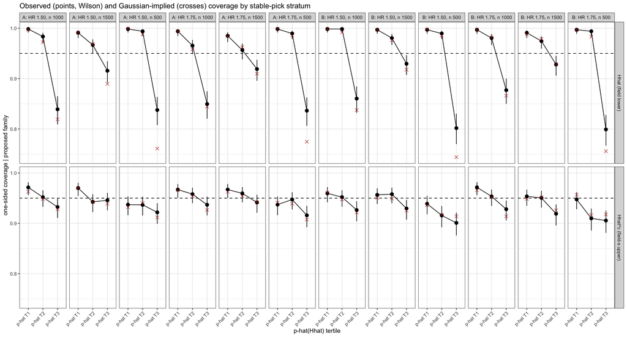

```r
if (!have(TERT) || !length(harm_labs)) skip_note("the tertile plot") else {
TT <- TERT[TERT$stratum != "all" & !grepl("not splittable", TERT$stratum) & TERT$cell %in% harm_labs, ]
if (!have(TT)) skip_note("the tertile plot") else {
TT$tertile <- sub(" \\[.*", "", TT$stratum)
TP <- rbind(data.frame(cell = TT$cell, tertile = TT$tertile, blk = "Hhat (field lower)",
                       cov = TT$cov_field_H,   lo = TT$wH_lo, hi = TT$wH_hi, implied = TT$gauss_H),
            data.frame(cell = TT$cell, tertile = TT$tertile, blk = "Hhat^c (field-s upper)",
                       cov = TT$cov_field_s_C, lo = TT$wC_lo, hi = TT$wC_hi, implied = TT$gauss_C))
ggplot(TP, aes(tertile, cov, group = 1)) + geom_hline(yintercept = 0.95, linetype = 2) +
  geom_pointrange(aes(ymin = lo, ymax = hi)) + geom_line() +
  geom_point(aes(y = implied), shape = 4, colour = "firebrick", size = 2) +
  facet_grid(blk ~ cell) +
  labs(x = "p-hat(Hhat) tertile", y = "one-sided coverage | proposed family",
       title = "Observed (points, Wilson) and Gaussian-implied (crosses) coverage by stable-pick stratum") +
  theme_bw(base_size = 9) + theme(axis.text.x = element_text(angle = 45, hjust = 1))
}
}
```

# 9 Stratified tables: by admitted-candidate count and by p̂

Everything in this section is **descriptive**. No acceptance criterion is applied, and every coverage figure is coverage of β(Ĥ) over the **detected replicates** of the cell named in its row.

**The two stratifications.**

- **Admitted-candidate count.** Within-cell empirical tertiles of **`admitted_n`**, plus **two extra rows that deliberately overlap them**: `admitted_n = 1` (one candidate clears the floor, so the admitted set imposes no choice at all) and `admitted_n <= 5`. Overlapping rows are marked; they are not a partition and must not be summed. **`admitted_n` and not `n_family`, deliberately.** `n_family` on GRF is the enumerated pool — `.grf_dr_candidates()` enumerates from quantiles of X subject to `n_min` (`R/grf_subgroup_labels.R:255–277`), so it does not depend on the outcome and is near-constant within a cell and identical across prevalences replicate by replicate. A stratification on it would not be a stratification on anything the outcome touches. `admitted_n` is the count whose inferential effect clears the resolved admission floor (`R/forestsearch_helpers.R:1654`) and is the analogue of the family-size stratifier the DINA summary uses (`summary_dinamr.qmd`, `n_family`). `n_family` is kept in the descriptive tables of Section 6.
- **p̂(Ĥ).** The bins **the FS summaries use**, stated so the comparison is like-for-like: `summary_cert20.qmd` (§tert), `summary_tier2.qmd`, `summary_p12ext.qmd`, `summary_e1stud.qmd` (all as `tert()`) and `summary_complement_variance.qmd` (§A2/A5/A6 as `strat()`) every one use **within-cell empirical tertiles** — `quantile(v, c(0, 1/3, 2/3, 1))` cut with `include.lowest = TRUE` — **not fixed cut-points**. The same definition is used here.

**Retained bias** is the bias that survives the correction, on the log scale: `mean(log(est) - log(beta(Hhat)))` within the stratum, for each product.

```r
tert_fs <- function(v) {                     # the FS summaries' own binning, verbatim in form
  if (!any(is.finite(v))) return(rep(NA_integer_, length(v)))
  br <- stats::quantile(v, c(0, 1/3, 2/3, 1), na.rm = TRUE, names = FALSE)
  if (length(unique(br)) < 2L) return(rep(1L, length(v)))
  cut(v, breaks = unique(br), include.lowest = TRUE, labels = FALSE) }
det_rows <- function(k) { r <- B[[k]]$results
  d <- r[r$detected %in% 1L, , drop = FALSE]
  keep <- is.finite(d$betaHhat_H) & is.finite(d$betaHhat_Hc) & is.finite(d$n_family) &
          is.finite(d$admitted_n) &
          is.finite(d$p_hat_H) & is.finite(d$fld_H_lo1s) & is.finite(d$fld_Hc_up1s_s)
  d[keep, , drop = FALSE] }
# Coverage of every product, Wilson, plus retained bias, on one stratum.
prod_rows <- function(d, cell, stratum, overlap = FALSE) {
  if (!nrow(d)) return(NULL)
  w <- function(p) wil(p, nrow(d))
  bias <- function(e) mean(log(e) - log(d$betaHhat_H))
  biasC <- function(e) mean(log(e) - log(d$betaHhat_Hc))
  mk <- function(block, product, cov, side, bi) {
    ww <- w(cov)
    data.frame(cell = cell, stratum = stratum, overlapping = overlap, n = nrow(d),
               block = block, product = product, side = side, coverage = cov,
               wilson_lo = ww[1], wilson_hi = ww[2], retained_bias_log = bi,
               stringsAsFactors = FALSE) }
  rbind(
    mk("Hhat",   "naive",       mean(d$betaHhat_H >= d$nv_H_lo & d$betaHhat_H <= d$nv_H_hi),
       "two-sided", bias(d$nv_H_est)),
    mk("Hhat",   "field",       mean(d$betaHhat_H >= d$fld_H_lo1s), "one-sided lower",
       bias(d$fld_H_est2)),
    mk("Hhat",   "field 2s",    mean(d$betaHhat_H >= d$fld_H_lo2s & d$betaHhat_H <= d$fld_H_hi2s),
       "two-sided", bias(d$fld_H_est2)),
    mk("Hhat",   "IJ two-term", mean(d$betaHhat_H >= d$mr_H_lo & d$betaHhat_H <= d$mr_H_hi),
       "two-sided", bias(d$mr_H_est)),
    mk("Hhat^c", "naive",       mean(d$betaHhat_Hc >= d$nv_Hc_lo & d$betaHhat_Hc <= d$nv_Hc_hi),
       "two-sided", biasC(d$nv_Hc_est)),
    mk("Hhat^c", "field",       mean(d$betaHhat_Hc <= d$fld_Hc_up1s), "one-sided upper",
       biasC(d$fld_Hc_est2)),
    mk("Hhat^c", "field-s",     mean(d$betaHhat_Hc <= d$fld_Hc_up1s_s), "one-sided upper",
       biasC(d$fld_Hc_est2_s)),
    mk("Hhat^c", "IJ two-term", mean(d$betaHhat_Hc >= d$mr_Hc_lo & d$betaHhat_Hc <= d$mr_Hc_hi),
       "two-sided", biasC(d$mr_Hc_est)),
    mk("joint",  "Bonferroni",  mean(d$betaHhat_H >= d$fld_joint_bonf_loH &
                                     d$betaHhat_Hc <= d$fld_joint_bonf_upHc), "joint", NA_real_),
    mk("joint",  "Bonferroni-s",mean(d$betaHhat_H >= d$fld_joint_s_bonf_loH &
                                     d$betaHhat_Hc <= d$fld_joint_s_bonf_upHc), "joint", NA_real_))
}
# The IJ two-sided miss, split by side, per stratum.
miss_rows <- function(d, cell, stratum, overlap = FALSE) {
  if (!nrow(d)) return(NULL)
  data.frame(cell = cell, stratum = stratum, overlapping = overlap, n = nrow(d),
             ij2_H = mean(d$betaHhat_H >= d$mr_H_lo & d$betaHhat_H <= d$mr_H_hi),
             miss_below_H = mean(d$betaHhat_H < d$mr_H_lo),
             miss_above_H = mean(d$betaHhat_H > d$mr_H_hi),
             ij2_Hc = mean(d$betaHhat_Hc >= d$mr_Hc_lo & d$betaHhat_Hc <= d$mr_Hc_hi),
             miss_below_Hc = mean(d$betaHhat_Hc < d$mr_Hc_lo),
             miss_above_Hc = mean(d$betaHhat_Hc > d$mr_Hc_hi),
             stringsAsFactors = FALSE) }
# THE GRF SUBSTITUTION.  by == "K" now reads admitted_n, NOT n_family.
# n_family on GRF is .grf_dr_candidates()'s enumeration from quantiles of X
# subject to n_min (R/grf_subgroup_labels.R:255-277), so it does not depend on
# the outcome and is near-constant across replicates AND across prevalences --
# stratifying on it would stratify on nothing the outcome touches.  admitted_n
# is the count that clears the resolved admission floor
# (R/forestsearch_helpers.R:1654) and is the analogue of DINA's family-size
# stratifier.  The p-hat stratification is UNCHANGED.
strata_of <- function(d, by) {
  v <- if (by == "K") d$admitted_n else d$p_hat_H
  g <- tert_fs(v); out <- list()
  for (t in sort(unique(g[!is.na(g)]))) {
    dk <- d[!is.na(g) & g == t, , drop = FALSE]
    out[[length(out)+1]] <- list(d = dk, ov = FALSE,
      lab = sprintf("%s T%d [%s, %s]", if (by == "K") "adm" else "p-hat", t,
                    format(min(v[!is.na(g) & g==t])), format(max(v[!is.na(g) & g==t])))) }
  if (by == "K") {
    out[[length(out)+1]] <- list(d = d[d$admitted_n == 1L, , drop = FALSE], ov = TRUE, lab = "admitted_n = 1 (overlapping)")
    out[[length(out)+1]] <- list(d = d[d$admitted_n <= 5L, , drop = FALSE], ov = TRUE, lab = "admitted_n <= 5 (overlapping)") }
  out[[length(out)+1]] <- list(d = d, ov = TRUE, lab = "all detected (overlapping)")
  out }
```

## 9.1 Every product by admitted-candidate-count stratum

```r
if (!have(labs)) skip_note("the admitted_n stratified tables") else {
SK <- do.call(rbind, lapply(labs, function(k) { d <- det_rows(k)
  if (!nrow(d)) return(NULL)
  do.call(rbind, lapply(strata_of(d, "K"), function(S) prod_rows(S$d, k, S$lab, S$ov))) }))
if (!have(SK)) skip_note("the admitted_n stratified tables") else
kbl(SK, digits = 4, booktabs = TRUE, row.names = FALSE,
    caption = "EVERY PRODUCT by within-cell ADMITTED-CANDIDATE-COUNT (admitted_n) stratum -- admitted_n and NOT n_family, because n_family on GRF is the outcome-independent enumerated pool (.grf_dr_candidates() enumerates from quantiles of X subject to n_min) while admitted_n is the count clearing the resolved admission floor: coverage with Wilson 95% limits, and the RETAINED BIAS on the log scale, mean(log(est) - log(beta(Hhat))). admitted_n tertiles are a partition; the admitted_n = 1, admitted_n <= 5 and 'all detected' rows OVERLAP them and each other and must not be summed (the `overlapping` column flags this). Over detected replicates throughout. Descriptive; no criterion applied.") |>
  kable_styling(font_size = 7) |> scroll_box(height = "600px")
}
```

EVERY PRODUCT by within-cell ADMITTED-CANDIDATE-COUNT (admitted_n) stratum -- admitted_n and NOT n_family, because n_family on GRF is the outcome-independent enumerated pool (.grf_dr_candidates() enumerates from quantiles of X subject to n_min) while admitted_n is the count clearing the resolved admission floor: coverage with Wilson 95% limits, and the RETAINED BIAS on the log scale, mean(log(est) - log(beta(Hhat))). admitted_n tertiles are a partition; the admitted_n = 1, admitted_n <= 5 and 'all detected' rows OVERLAP them and each other and must not be summed (the `overlapping` column flags this). Over detected replicates throughout. Descriptive; no criterion applied.

| cell | stratum | overlapping | n | block | product | side | coverage | wilson_lo | wilson_hi | retained_bias_log |
| --- | --- | --- | --- | --- | --- | --- | --- | --- | --- | --- |
| A: HR 1.50, n 500 | adm T1 [2, 80] | FALSE | 669 | Hhat | naive | two-sided | 0.7698 | 0.7364 | 0.8001 | 0.4191 |
| A: HR 1.50, n 500 | adm T1 [2, 80] | FALSE | 669 | Hhat | field | one-sided lower | 0.9851 | 0.9727 | 0.9919 | -0.1500 |
| A: HR 1.50, n 500 | adm T1 [2, 80] | FALSE | 669 | Hhat | field 2s | two-sided | 0.9268 | 0.9045 | 0.9442 | -0.1500 |
| A: HR 1.50, n 500 | adm T1 [2, 80] | FALSE | 669 | Hhat | IJ two-term | two-sided | 0.9895 | 0.9786 | 0.9949 | -0.0790 |
| A: HR 1.50, n 500 | adm T1 [2, 80] | FALSE | 669 | Hhat^c | naive | two-sided | 0.6622 | 0.6255 | 0.6970 | -0.2417 |
| A: HR 1.50, n 500 | adm T1 [2, 80] | FALSE | 669 | Hhat^c | field | one-sided upper | 0.8161 | 0.7850 | 0.8437 | -0.1296 |
| A: HR 1.50, n 500 | adm T1 [2, 80] | FALSE | 669 | Hhat^c | field-s | one-sided upper | 0.8296 | 0.7992 | 0.8562 | -0.1300 |
| A: HR 1.50, n 500 | adm T1 [2, 80] | FALSE | 669 | Hhat^c | IJ two-term | two-sided | 0.9985 | 0.9916 | 0.9997 | -0.1491 |
| A: HR 1.50, n 500 | adm T1 [2, 80] | FALSE | 669 | joint | Bonferroni | joint | 0.8924 | 0.8666 | 0.9137 | NA |
| A: HR 1.50, n 500 | adm T1 [2, 80] | FALSE | 669 | joint | Bonferroni-s | joint | 0.9073 | 0.8830 | 0.9270 | NA |
| A: HR 1.50, n 500 | adm T2 [81, 153] | FALSE | 667 | Hhat | naive | two-sided | 0.4873 | 0.4495 | 0.5252 | 0.5997 |
| A: HR 1.50, n 500 | adm T2 [81, 153] | FALSE | 667 | Hhat | field | one-sided lower | 0.9490 | 0.9296 | 0.9633 | 0.0546 |
| A: HR 1.50, n 500 | adm T2 [81, 153] | FALSE | 667 | Hhat | field 2s | two-sided | 0.9670 | 0.9506 | 0.9781 | 0.0546 |
| A: HR 1.50, n 500 | adm T2 [81, 153] | FALSE | 667 | Hhat | IJ two-term | two-sided | 0.9955 | 0.9869 | 0.9985 | 0.1212 |
| A: HR 1.50, n 500 | adm T2 [81, 153] | FALSE | 667 | Hhat^c | naive | two-sided | 0.9370 | 0.9160 | 0.9531 | -0.1372 |
| A: HR 1.50, n 500 | adm T2 [81, 153] | FALSE | 667 | Hhat^c | field | one-sided upper | 0.9640 | 0.9470 | 0.9757 | -0.0356 |
| A: HR 1.50, n 500 | adm T2 [81, 153] | FALSE | 667 | Hhat^c | field-s | one-sided upper | 0.9685 | 0.9523 | 0.9793 | -0.0359 |
| A: HR 1.50, n 500 | adm T2 [81, 153] | FALSE | 667 | Hhat^c | IJ two-term | two-sided | 1.0000 | 0.9943 | 1.0000 | -0.0527 |
| A: HR 1.50, n 500 | adm T2 [81, 153] | FALSE | 667 | joint | Bonferroni | joint | 0.9595 | 0.9417 | 0.9720 | NA |
| A: HR 1.50, n 500 | adm T2 [81, 153] | FALSE | 667 | joint | Bonferroni-s | joint | 0.9610 | 0.9435 | 0.9733 | NA |
| A: HR 1.50, n 500 | adm T3 [154, 600] | FALSE | 661 | Hhat | naive | two-sided | 0.2345 | 0.2038 | 0.2683 | 0.7393 |
| A: HR 1.50, n 500 | adm T3 [154, 600] | FALSE | 661 | Hhat | field | one-sided lower | 0.8956 | 0.8700 | 0.9167 | 0.1922 |
| A: HR 1.50, n 500 | adm T3 [154, 600] | FALSE | 661 | Hhat | field 2s | two-sided | 0.9380 | 0.9169 | 0.9540 | 0.1922 |
| A: HR 1.50, n 500 | adm T3 [154, 600] | FALSE | 661 | Hhat | IJ two-term | two-sided | 0.9818 | 0.9685 | 0.9896 | 0.2634 |
| A: HR 1.50, n 500 | adm T3 [154, 600] | FALSE | 661 | Hhat^c | naive | two-sided | 0.9894 | 0.9783 | 0.9949 | -0.0074 |
| A: HR 1.50, n 500 | adm T3 [154, 600] | FALSE | 661 | Hhat^c | field | one-sided upper | 0.9970 | 0.9890 | 0.9992 | 0.0926 |
| A: HR 1.50, n 500 | adm T3 [154, 600] | FALSE | 661 | Hhat^c | field-s | one-sided upper | 0.9985 | 0.9915 | 0.9997 | 0.0922 |
| A: HR 1.50, n 500 | adm T3 [154, 600] | FALSE | 661 | Hhat^c | IJ two-term | two-sided | 1.0000 | 0.9942 | 1.0000 | 0.0760 |
| A: HR 1.50, n 500 | adm T3 [154, 600] | FALSE | 661 | joint | Bonferroni | joint | 0.9395 | 0.9186 | 0.9552 | NA |
| A: HR 1.50, n 500 | adm T3 [154, 600] | FALSE | 661 | joint | Bonferroni-s | joint | 0.9395 | 0.9186 | 0.9552 | NA |

[output cut: 840 more lines]

## 9.2 Every product by p̂ bin (the FS summaries’ within-cell tertiles)

```r
if (!have(labs)) skip_note("the p-hat stratified tables") else {
SP <- do.call(rbind, lapply(labs, function(k) { d <- det_rows(k)
  if (!nrow(d)) return(NULL)
  do.call(rbind, lapply(strata_of(d, "p"), function(S) prod_rows(S$d, k, S$lab, S$ov))) }))
if (!have(SP)) skip_note("the p-hat stratified tables") else
kbl(SP, digits = 4, booktabs = TRUE, row.names = FALSE,
    caption = "EVERY PRODUCT by p-hat(Hhat) bin. The bins are the within-cell empirical tertiles the FS summaries use -- quantile(v, c(0, 1/3, 2/3, 1)) cut with include.lowest = TRUE, as in summary_cert20 (sec-tert), summary_tier2, summary_p12ext, summary_e1stud and summary_complement_variance -- NOT fixed cut-points. Coverage with Wilson 95% limits and the retained log-scale bias. The 'all detected' row overlaps the tertiles. Over detected replicates. Descriptive; no criterion applied.") |>
  kable_styling(font_size = 7) |> scroll_box(height = "600px")
}
```

EVERY PRODUCT by p-hat(Hhat) bin. The bins are the within-cell empirical tertiles the FS summaries use -- quantile(v, c(0, 1/3, 2/3, 1)) cut with include.lowest = TRUE, as in summary_cert20 (sec-tert), summary_tier2, summary_p12ext, summary_e1stud and summary_complement_variance -- NOT fixed cut-points. Coverage with Wilson 95% limits and the retained log-scale bias. The 'all detected' row overlaps the tertiles. Over detected replicates. Descriptive; no criterion applied.

| cell | stratum | overlapping | n | block | product | side | coverage | wilson_lo | wilson_hi | retained_bias_log |
| --- | --- | --- | --- | --- | --- | --- | --- | --- | --- | --- |
| A: HR 1.50, n 500 | p-hat T1 [8e-04, 0.0662] | FALSE | 668 | Hhat | naive | two-sided | 0.6692 | 0.6326 | 0.7038 | 0.4032 |
| A: HR 1.50, n 500 | p-hat T1 [8e-04, 0.0662] | FALSE | 668 | Hhat | field | one-sided lower | 0.9985 | 0.9916 | 0.9997 | -0.1884 |
| A: HR 1.50, n 500 | p-hat T1 [8e-04, 0.0662] | FALSE | 668 | Hhat | field 2s | two-sided | 0.9416 | 0.9212 | 0.9570 | -0.1884 |
| A: HR 1.50, n 500 | p-hat T1 [8e-04, 0.0662] | FALSE | 668 | Hhat | IJ two-term | two-sided | 0.9940 | 0.9847 | 0.9977 | -0.1116 |
| A: HR 1.50, n 500 | p-hat T1 [8e-04, 0.0662] | FALSE | 668 | Hhat^c | naive | two-sided | 0.8653 | 0.8373 | 0.8891 | -0.1416 |
| A: HR 1.50, n 500 | p-hat T1 [8e-04, 0.0662] | FALSE | 668 | Hhat^c | field | one-sided upper | 0.9162 | 0.8927 | 0.9349 | -0.0221 |
| A: HR 1.50, n 500 | p-hat T1 [8e-04, 0.0662] | FALSE | 668 | Hhat^c | field-s | one-sided upper | 0.9371 | 0.9161 | 0.9532 | -0.0218 |
| A: HR 1.50, n 500 | p-hat T1 [8e-04, 0.0662] | FALSE | 668 | Hhat^c | IJ two-term | two-sided | 1.0000 | 0.9943 | 1.0000 | -0.0439 |
| A: HR 1.50, n 500 | p-hat T1 [8e-04, 0.0662] | FALSE | 668 | joint | Bonferroni | joint | 0.9521 | 0.9332 | 0.9659 | NA |
| A: HR 1.50, n 500 | p-hat T1 [8e-04, 0.0662] | FALSE | 668 | joint | Bonferroni-s | joint | 0.9626 | 0.9453 | 0.9745 | NA |
| A: HR 1.50, n 500 | p-hat T2 [0.0664, 0.1502] | FALSE | 664 | Hhat | naive | two-sided | 0.5407 | 0.5026 | 0.5782 | 0.5364 |
| A: HR 1.50, n 500 | p-hat T2 [0.0664, 0.1502] | FALSE | 664 | Hhat | field | one-sided lower | 0.9940 | 0.9846 | 0.9977 | -0.0247 |
| A: HR 1.50, n 500 | p-hat T2 [0.0664, 0.1502] | FALSE | 664 | Hhat | field 2s | two-sided | 0.9849 | 0.9725 | 0.9918 | -0.0247 |
| A: HR 1.50, n 500 | p-hat T2 [0.0664, 0.1502] | FALSE | 664 | Hhat | IJ two-term | two-sided | 0.9970 | 0.9891 | 0.9992 | 0.0458 |
| A: HR 1.50, n 500 | p-hat T2 [0.0664, 0.1502] | FALSE | 664 | Hhat^c | naive | two-sided | 0.8735 | 0.8460 | 0.8966 | -0.1251 |
| A: HR 1.50, n 500 | p-hat T2 [0.0664, 0.1502] | FALSE | 664 | Hhat^c | field | one-sided upper | 0.9352 | 0.9139 | 0.9516 | -0.0190 |
| A: HR 1.50, n 500 | p-hat T2 [0.0664, 0.1502] | FALSE | 664 | Hhat^c | field-s | one-sided upper | 0.9367 | 0.9156 | 0.9529 | -0.0195 |
| A: HR 1.50, n 500 | p-hat T2 [0.0664, 0.1502] | FALSE | 664 | Hhat^c | IJ two-term | two-sided | 1.0000 | 0.9942 | 1.0000 | -0.0363 |
| A: HR 1.50, n 500 | p-hat T2 [0.0664, 0.1502] | FALSE | 664 | joint | Bonferroni | joint | 0.9684 | 0.9521 | 0.9792 | NA |
| A: HR 1.50, n 500 | p-hat T2 [0.0664, 0.1502] | FALSE | 664 | joint | Bonferroni-s | joint | 0.9744 | 0.9594 | 0.9840 | NA |
| A: HR 1.50, n 500 | p-hat T3 [0.1504, 0.9208] | FALSE | 665 | Hhat | naive | two-sided | 0.2842 | 0.2512 | 0.3197 | 0.8174 |
| A: HR 1.50, n 500 | p-hat T3 [0.1504, 0.9208] | FALSE | 665 | Hhat | field | one-sided lower | 0.8376 | 0.8076 | 0.8637 | 0.3087 |
| A: HR 1.50, n 500 | p-hat T3 [0.1504, 0.9208] | FALSE | 665 | Hhat | field 2s | two-sided | 0.9053 | 0.8806 | 0.9253 | 0.3087 |
| A: HR 1.50, n 500 | p-hat T3 [0.1504, 0.9208] | FALSE | 665 | Hhat | IJ two-term | two-sided | 0.9759 | 0.9613 | 0.9851 | 0.3704 |
| A: HR 1.50, n 500 | p-hat T3 [0.1504, 0.9208] | FALSE | 665 | Hhat^c | naive | two-sided | 0.8481 | 0.8188 | 0.8734 | -0.1210 |
| A: HR 1.50, n 500 | p-hat T3 [0.1504, 0.9208] | FALSE | 665 | Hhat^c | field | one-sided upper | 0.9248 | 0.9022 | 0.9425 | -0.0329 |
| A: HR 1.50, n 500 | p-hat T3 [0.1504, 0.9208] | FALSE | 665 | Hhat^c | field-s | one-sided upper | 0.9218 | 0.8989 | 0.9399 | -0.0338 |
| A: HR 1.50, n 500 | p-hat T3 [0.1504, 0.9208] | FALSE | 665 | Hhat^c | IJ two-term | two-sided | 0.9985 | 0.9915 | 0.9997 | -0.0470 |
| A: HR 1.50, n 500 | p-hat T3 [0.1504, 0.9208] | FALSE | 665 | joint | Bonferroni | joint | 0.8707 | 0.8430 | 0.8941 | NA |
| A: HR 1.50, n 500 | p-hat T3 [0.1504, 0.9208] | FALSE | 665 | joint | Bonferroni-s | joint | 0.8707 | 0.8430 | 0.8941 | NA |

[output cut: 690 more lines]

## 9.3 Admitted-candidate-count stratum by p̂ bin: counts

```r
if (!have(labs)) skip_note("the stratum cross-tabulation") else {
XT <- do.call(rbind, lapply(labs, function(k) { d <- det_rows(k)
  if (nrow(d) < 9L) return(NULL)
  # admitted_n, NOT n_family -- the same substitution strata_of() makes.  This
  # chunk builds its own tertiles rather than calling strata_of(), so it has to
  # make the substitution itself; keying it on n_family would cross-tabulate
  # p-hat against the outcome-independent enumerated pool and say nothing.
  gk <- tert_fs(d$admitted_n); gp <- tert_fs(d$p_hat_H)
  base <- do.call(rbind, lapply(sort(unique(gk[!is.na(gk)])), function(a)
    do.call(rbind, lapply(sort(unique(gp[!is.na(gp)])), function(b)
      data.frame(cell = k, adm_stratum = sprintf("adm T%d", a), p_hat_bin = sprintf("p-hat T%d", b),
                 count = sum(!is.na(gk) & !is.na(gp) & gk == a & gp == b),
                 stringsAsFactors = FALSE)))))
  extra <- do.call(rbind, lapply(list(c("admitted_n = 1", "1"), c("admitted_n <= 5", "5")), function(x)
    do.call(rbind, lapply(sort(unique(gp[!is.na(gp)])), function(b)
      data.frame(cell = k, adm_stratum = paste0(x[1], " (overlapping)"),
                 p_hat_bin = sprintf("p-hat T%d", b),
                 count = sum(d$admitted_n <= as.integer(x[2]) &
                             (if (x[2] == "1") d$admitted_n == 1L else TRUE) &
                             !is.na(gp) & gp == b),
                 stringsAsFactors = FALSE)))))
  rbind(base, extra) }))
if (!have(XT)) skip_note("the stratum cross-tabulation") else {
XW <- reshape(XT, idvar = c("cell", "adm_stratum"), timevar = "p_hat_bin", direction = "wide")
names(XW) <- sub("^count\\.", "", names(XW))
kbl(XW, booktabs = TRUE, row.names = FALSE,
    caption = "Counts: ADMITTED-CANDIDATE-COUNT (admitted_n) stratum by p-hat bin, within each cell. admitted_n and NOT n_family, the same substitution the strata section makes: n_family on GRF is the outcome-independent enumerated pool, so cross-tabulating p-hat against it would say nothing. The admitted_n = 1 and admitted_n <= 5 rows OVERLAP the tertiles. This is the table that says whether the two stratifications are measuring the same thing or different things -- a strongly diagonal count pattern means p-hat and the admitted count carry the same information in this design.") |>
  kable_styling(font_size = 8) |> scroll_box(height = "500px")
}
}
```

Counts: ADMITTED-CANDIDATE-COUNT (admitted_n) stratum by p-hat bin, within each cell. admitted_n and NOT n_family, the same substitution the strata section makes: n_family on GRF is the outcome-independent enumerated pool, so cross-tabulating p-hat against it would say nothing. The admitted_n = 1 and admitted_n <= 5 rows OVERLAP the tertiles. This is the table that says whether the two stratifications are measuring the same thing or different things -- a strongly diagonal count pattern means p-hat and the admitted count carry the same information in this design.

| cell | adm_stratum | p-hat T1 | p-hat T2 | p-hat T3 |
| --- | --- | --- | --- | --- |
| A: HR 1.50, n 500 | adm T1 | 244 | 231 | 194 |
| A: HR 1.50, n 500 | adm T2 | 215 | 217 | 235 |
| A: HR 1.50, n 500 | adm T3 | 209 | 216 | 236 |
| A: HR 1.50, n 500 | admitted_n = 1 (overlapping) | 0 | 0 | 0 |
| A: HR 1.50, n 500 | admitted_n <= 5 (overlapping) | 3 | 3 | 1 |
| A: HR 1.50, n 1000 | adm T1 | 249 | 220 | 196 |
| A: HR 1.50, n 1000 | adm T2 | 222 | 231 | 215 |
| A: HR 1.50, n 1000 | adm T3 | 194 | 214 | 254 |
| A: HR 1.50, n 1000 | admitted_n = 1 (overlapping) | 0 | 0 | 0 |
| A: HR 1.50, n 1000 | admitted_n <= 5 (overlapping) | 3 | 2 | 2 |
| A: HR 1.50, n 1500 | adm T1 | 268 | 239 | 174 |
| A: HR 1.50, n 1500 | adm T2 | 206 | 214 | 245 |
| A: HR 1.50, n 1500 | adm T3 | 194 | 210 | 245 |
| A: HR 1.50, n 1500 | admitted_n = 1 (overlapping) | 0 | 0 | 0 |
| A: HR 1.50, n 1500 | admitted_n <= 5 (overlapping) | 5 | 5 | 1 |
| A: HR 1.75, n 500 | adm T1 | 245 | 216 | 206 |
| A: HR 1.75, n 500 | adm T2 | 219 | 221 | 230 |
| A: HR 1.75, n 500 | adm T3 | 205 | 227 | 230 |
| A: HR 1.75, n 500 | admitted_n = 1 (overlapping) | 0 | 0 | 0 |
| A: HR 1.75, n 500 | admitted_n <= 5 (overlapping) | 3 | 0 | 1 |
| A: HR 1.75, n 1000 | adm T1 | 261 | 206 | 203 |
| A: HR 1.75, n 1000 | adm T2 | 211 | 215 | 238 |
| A: HR 1.75, n 1000 | adm T3 | 194 | 246 | 224 |
| A: HR 1.75, n 1000 | admitted_n = 1 (overlapping) | 0 | 0 | 0 |
| A: HR 1.75, n 1000 | admitted_n <= 5 (overlapping) | 0 | 0 | 0 |
| A: HR 1.75, n 1500 | adm T1 | 281 | 201 | 185 |
| A: HR 1.75, n 1500 | adm T2 | 195 | 227 | 251 |
| A: HR 1.75, n 1500 | adm T3 | 191 | 239 | 230 |
| A: HR 1.75, n 1500 | admitted_n = 1 (overlapping) | 0 | 0 | 0 |
| A: HR 1.75, n 1500 | admitted_n <= 5 (overlapping) | 1 | 0 | 0 |

[output cut: 60 more lines]

## 9.4 IJ two-sided misses, split by side, within both stratifications

```r
if (!have(labs)) skip_note("the stratified miss tables") else {
for (by in c("K", "p")) {
  MS <- do.call(rbind, lapply(labs, function(k) { d <- det_rows(k)
    if (!nrow(d)) return(NULL)
    do.call(rbind, lapply(strata_of(d, by), function(S) miss_rows(S$d, k, S$lab, S$ov))) }))
  if (!have(MS)) { skip_note(sprintf("the stratified miss table by %s", by)); next }
  print(kbl(MS, digits = 4, booktabs = TRUE, row.names = FALSE,
      caption = sprintf("IJ two-term TWO-SIDED coverage and its MISS SPLIT BY SIDE, by %s stratum. miss_below = beta(Hhat) under the lower limit; miss_above = over the upper limit; the three sum to 1 within a row. Overlapping rows flagged. Over detected replicates.",
                        if (by == "K") "admitted_n (admitted-candidate-count)" else "p-hat")) |>
    kable_styling(font_size = 7) |> scroll_box(height = "500px"))
}
}
```

[output not shown]

[output cut: 1890 more lines]

[output not shown]

## 9.5 γ at its floor, beside the Bonferroni joint coverage

```r
if (!have(labs)) skip_note("the gamma-at-floor table") else {
GM <- do.call(rbind, lapply(labs, function(k) { d <- det_rows(k)
  if (!nrow(d)) return(NULL)
  data.frame(cell = k, block = BLK[[k]], n = NN[[k]], HR = HR[[k]], arm = ARM[[k]], n_eval = nrow(d),
             share_gamma_at_floor = mean(d$fld_joint_gamma == 0.025),
             gamma_min = min(d$fld_joint_gamma), gamma_max = max(d$fld_joint_gamma),
             gamma_mean = mean(d$fld_joint_gamma),
             share_gamma_s_at_floor = mean(d$fld_joint_s_gamma == 0.025),
             joint_bonf = mean(d$betaHhat_H >= d$fld_joint_bonf_loH &
                               d$betaHhat_Hc <= d$fld_joint_bonf_upHc),
             joint_s_bonf = mean(d$betaHhat_H >= d$fld_joint_s_bonf_loH &
                                 d$betaHhat_Hc <= d$fld_joint_s_bonf_upHc),
             stringsAsFactors = FALSE) }))
GM <- GM[order(GM$arm, GM$block, GM$HR, GM$n), ]
gw <- t(vapply(seq_len(nrow(GM)), function(i) wil(GM$joint_s_bonf[i], GM$n_eval[i]), numeric(2)))
GM$joint_s_wilson_lo <- gw[, 1]; GM$joint_s_wilson_hi <- gw[, 2]
kbl(GM, digits = 4, booktabs = TRUE, row.names = FALSE,
    caption = "Per cell: the SHARE OF ROWS WITH gamma AT ITS 0.025 FLOOR (for the joint and joint-s pairs) beside the Bonferroni joint coverage from both pairs, with Wilson limits on joint_s. gamma is the per-replicate joint level the Bonferroni bound is built at; where it sits at the floor the Bonferroni bound coincides exactly with the raw joint bound, and where it does not the two differ -- which is why the Gate 2 identity is gated on the floor rows. Over detected replicates.") |>
  kable_styling(font_size = 8)
}
```

Per cell: the SHARE OF ROWS WITH gamma AT ITS 0.025 FLOOR (for the joint and joint-s pairs) beside the Bonferroni joint coverage from both pairs, with Wilson limits on joint_s. gamma is the per-replicate joint level the Bonferroni bound is built at; where it sits at the floor the Bonferroni bound coincides exactly with the raw joint bound, and where it does not the two differ -- which is why the Gate 2 identity is gated on the floor rows. Over detected replicates.

| cell | block | n | HR | arm | n_eval | share_gamma_at_floor | gamma_min | gamma_max | gamma_mean | share_gamma_s_at_floor | joint_bonf | joint_s_bonf | joint_s_wilson_lo | joint_s_wilson_hi |
| --- | --- | --- | --- | --- | --- | --- | --- | --- | --- | --- | --- | --- | --- | --- |
| A: HR 1.50, n 500 | A | 500 | 1.50 | harm | 1997 | 0.9249 | 0.025 | 0.027 | 0.0251 | 0.8658 | 0.9304 | 0.9359 | 0.9243 | 0.9458 |
| A: HR 1.50, n 1000 | A | 1000 | 1.50 | harm | 1995 | 0.9088 | 0.025 | 0.027 | 0.0251 | 0.8521 | 0.9393 | 0.9398 | 0.9285 | 0.9495 |
| A: HR 1.50, n 1500 | A | 1500 | 1.50 | harm | 1995 | 0.8942 | 0.025 | 0.027 | 0.0251 | 0.8366 | 0.9524 | 0.9544 | 0.9443 | 0.9627 |
| A: HR 1.75, n 500 | A | 500 | 1.75 | harm | 1999 | 0.9105 | 0.025 | 0.027 | 0.0251 | 0.8589 | 0.9305 | 0.9350 | 0.9233 | 0.9450 |
| A: HR 1.75, n 1000 | A | 1000 | 1.75 | harm | 1998 | 0.8894 | 0.025 | 0.027 | 0.0251 | 0.8423 | 0.9379 | 0.9399 | 0.9287 | 0.9495 |
| A: HR 1.75, n 1500 | A | 1500 | 1.75 | harm | 2000 | 0.8765 | 0.025 | 0.027 | 0.0251 | 0.8120 | 0.9540 | 0.9575 | 0.9477 | 0.9655 |
| B: HR 1.50, n 500 | B | 500 | 1.50 | harm | 2000 | 0.9075 | 0.025 | 0.027 | 0.0251 | 0.8445 | 0.9185 | 0.9230 | 0.9105 | 0.9339 |
| B: HR 1.50, n 1000 | B | 1000 | 1.50 | harm | 2000 | 0.9085 | 0.025 | 0.027 | 0.0251 | 0.8355 | 0.9440 | 0.9505 | 0.9401 | 0.9592 |
| B: HR 1.50, n 1500 | B | 1500 | 1.50 | harm | 2000 | 0.9110 | 0.025 | 0.027 | 0.0251 | 0.8200 | 0.9500 | 0.9565 | 0.9467 | 0.9646 |
| B: HR 1.75, n 500 | B | 500 | 1.75 | harm | 2000 | 0.8955 | 0.025 | 0.027 | 0.0251 | 0.8345 | 0.9215 | 0.9260 | 0.9137 | 0.9367 |
| B: HR 1.75, n 1000 | B | 1000 | 1.75 | harm | 2000 | 0.9075 | 0.025 | 0.027 | 0.0251 | 0.8200 | 0.9400 | 0.9465 | 0.9358 | 0.9555 |
| B: HR 1.75, n 1500 | B | 1500 | 1.75 | harm | 2000 | 0.9060 | 0.025 | 0.027 | 0.0251 | 0.8025 | 0.9520 | 0.9550 | 0.9450 | 0.9632 |
| A: HR 1.00, n 500 | A | 500 | 1.00 | null | 1968 | 0.9314 | 0.025 | 0.027 | 0.0251 | 0.8816 | 0.9345 | 0.9405 | 0.9292 | 0.9502 |
| A: HR 1.00, n 1000 | A | 1000 | 1.00 | null | 1915 | 0.9295 | 0.025 | 0.027 | 0.0251 | 0.8867 | 0.9384 | 0.9410 | 0.9295 | 0.9507 |
| A: HR 1.00, n 1500 | A | 1500 | 1.00 | null | 1735 | 0.9378 | 0.025 | 0.026 | 0.0251 | 0.8986 | 0.9499 | 0.9522 | 0.9411 | 0.9612 |
| B: HR 1.00, n 500 | B | 500 | 1.00 | null | 1994 | 0.9223 | 0.025 | 0.027 | 0.0251 | 0.8696 | 0.9188 | 0.9273 | 0.9150 | 0.9379 |
| B: HR 1.00, n 1000 | B | 1000 | 1.00 | null | 1996 | 0.9319 | 0.025 | 0.027 | 0.0251 | 0.8652 | 0.9274 | 0.9334 | 0.9216 | 0.9435 |
| B: HR 1.00, n 1500 | B | 1500 | 1.00 | null | 1987 | 0.9451 | 0.025 | 0.027 | 0.0251 | 0.8792 | 0.9346 | 0.9467 | 0.9359 | 0.9557 |

## 9.6 The same p̂ tertile table on the FS comparator, and the two bias curves overlaid

The identical construction, computed on each cell’s **committed FS comparator bundle** — the one that shares the DGM draws — so the two bias-versus-p̂ curves can be overlaid on **median p̂**. Bins are each bundle’s **own** within-cell empirical tertiles, the FS `tert()` definition, so each engine is binned on its own p̂ distribution rather than on the other’s cut-points.

**The criterion is carried on every row.** At **31% the FS comparator runs GRF’s own criterion** (`effMaxSG`, ε 0.20 — `cert20` / `e1stud`); at **12.4% it does not** (`maxeffCons`, ε 0.10 — `p12ext` / `tier2`). See Section 7 for what that does to the comparison.

> **At 12.4% this overlay is criterion-confounded.** The FS side is `maxeffCons` at ε 0.10 against GRF’s `effMaxSG` at ε 0.20 — a different selection functional at half the band width — so the Block A gap is not attributable to the engines. **Block B’s overlay is the one to read for that**, because there the FS comparator runs GRF’s own criterion (`effMaxSG`, ε 0.20) and the criterion drops out of the comparison.

```r
if (!have(labs)) skip_note("the FS p-hat tertile table") else {
phat_tert <- function(r, tag, cell, crit) {
  d <- r[r$detected %in% 1L & is.finite(r$betaHhat_H) & is.finite(r$fld_H_lo1s) &
         is.finite(r$p_hat_H) & is.finite(r$fld_H_est2) & is.finite(r$nv_H_est), , drop = FALSE]
  if (nrow(d) < 30L) return(NULL)
  g <- tert_fs(d$p_hat_H)
  do.call(rbind, lapply(sort(unique(g[!is.na(g)])), function(t) {
    dk <- d[!is.na(g) & g == t, , drop = FALSE]
    cv <- mean(dk$betaHhat_H >= dk$fld_H_lo1s); w <- wil(cv, nrow(dk))
    data.frame(cell = cell, engine = tag, criterion = crit,
               stratum = sprintf("p-hat T%d [%.4f, %.4f]", t, min(dk$p_hat_H), max(dk$p_hat_H)),
               count = nrow(dk), p_hat_med = stats::median(dk$p_hat_H),
               K_med = stats::median(dk$n_family, na.rm = TRUE),
               fldH_cov = cv, wilson_lo = w[1], wilson_hi = w[2],
               retained_bias_log = mean(log(dk$fld_H_est2) - log(dk$betaHhat_H)),
               naive_bias_log = mean(log(dk$nv_H_est) - log(dk$betaHhat_H)),
               stringsAsFactors = FALSE) })) }
FSP <- do.call(rbind, lapply(labs, function(k) {
  x <- fs_for(k)
  rbind(phat_tert(B[[k]]$results, "GRF (grfmr)", k, "grfmr / effMaxSG / eps 0.2"),
        if (is.null(x)) NULL else phat_tert(x$b$results, "FS", k, fs_crit(x))) }))
if (!have(FSP)) skip_note("the FS p-hat tertile table") else
kbl(FSP, digits = 4, booktabs = TRUE, row.names = FALSE,
    caption = "The p-hat tertile table computed IDENTICALLY on GRF and on each cell's committed FS comparator (which shares the DGM draws): count, median p-hat, median family size, field one-sided LOWER coverage of beta(Hhat) with Wilson limits, the retained log-scale bias mean(log(fld_H_est2) - log(beta(Hhat))), and the naive bias beside it. Each bundle is binned on ITS OWN within-cell empirical tertiles (the FS tert() definition), not on the other's cut-points. The `criterion` column carries each FS bundle's campaign / sg_focus / eps: at 31% the FS comparator runs GRF's own criterion (effMaxSG, eps 0.20); at 12.4% it does not (maxeffCons, eps 0.10). Coverage is coverage over detected replicates for GRF and FS's own estimand for FS. Descriptive.") |>
  kable_styling(font_size = 7) |> scroll_box(height = "600px")
}
```

The p-hat tertile table computed IDENTICALLY on GRF and on each cell's committed FS comparator (which shares the DGM draws): count, median p-hat, median family size, field one-sided LOWER coverage of beta(Hhat) with Wilson limits, the retained log-scale bias mean(log(fld_H_est2) - log(beta(Hhat))), and the naive bias beside it. Each bundle is binned on ITS OWN within-cell empirical tertiles (the FS tert() definition), not on the other's cut-points. The `criterion` column carries each FS bundle's campaign / sg_focus / eps: at 31% the FS comparator runs GRF's own criterion (effMaxSG, eps 0.20); at 12.4% it does not (maxeffCons, eps 0.10). Coverage is coverage over detected replicates for GRF and FS's own estimand for FS. Descriptive.

| cell | engine | criterion | stratum | count | p_hat_med | K_med | fldH_cov | wilson_lo | wilson_hi | retained_bias_log | naive_bias_log |
| --- | --- | --- | --- | --- | --- | --- | --- | --- | --- | --- | --- |
| A: HR 1.50, n 500 | GRF (grfmr) | grfmr / effMaxSG / eps 0.2 | p-hat T1 [0.0008, 0.0662] | 668 | 0.0403 | 775.0 | 0.9985 | 0.9916 | 0.9997 | -0.1884 | 0.4032 |
| A: HR 1.50, n 500 | GRF (grfmr) | grfmr / effMaxSG / eps 0.2 | p-hat T2 [0.0664, 0.1502] | 664 | 0.0987 | 776.0 | 0.9940 | 0.9846 | 0.9977 | -0.0247 | 0.5364 |
| A: HR 1.50, n 500 | GRF (grfmr) | grfmr / effMaxSG / eps 0.2 | p-hat T3 [0.1504, 0.9208] | 665 | 0.2472 | 776.0 | 0.8376 | 0.8076 | 0.8637 | 0.3087 | 0.8174 |
| A: HR 1.50, n 500 | FS | p12ext / maxeffCons / eps 0.1 | p-hat T1 [0.0000, 0.1214] | 609 | 0.0718 | 1223.0 | 0.9852 | 0.9722 | 0.9922 | -0.0725 | 0.5880 |
| A: HR 1.50, n 500 | FS | p12ext / maxeffCons / eps 0.1 | p-hat T2 [0.1216, 0.2266] | 606 | 0.1660 | 1226.0 | 0.9901 | 0.9786 | 0.9955 | -0.1175 | 0.5316 |
| A: HR 1.50, n 500 | FS | p12ext / maxeffCons / eps 0.1 | p-hat T3 [0.2270, 0.9420] | 607 | 0.3254 | 1221.0 | 0.9209 | 0.8967 | 0.9398 | 0.1273 | 0.6210 |
| A: HR 1.50, n 1000 | GRF (grfmr) | grfmr / effMaxSG / eps 0.2 | p-hat T1 [0.0018, 0.0762] | 665 | 0.0480 | 830.0 | 0.9985 | 0.9915 | 0.9997 | -0.1369 | 0.2514 |
| A: HR 1.50, n 1000 | GRF (grfmr) | grfmr / effMaxSG / eps 0.2 | p-hat T2 [0.0764, 0.1700] | 665 | 0.1140 | 829.0 | 0.9835 | 0.9706 | 0.9907 | -0.0359 | 0.3308 |
| A: HR 1.50, n 1000 | GRF (grfmr) | grfmr / effMaxSG / eps 0.2 | p-hat T3 [0.1704, 0.9342] | 665 | 0.2702 | 830.0 | 0.8391 | 0.8092 | 0.8651 | 0.1317 | 0.4445 |
| A: HR 1.50, n 1000 | FS | p12ext / maxeffCons / eps 0.1 | p-hat T1 [0.0042, 0.2020] | 652 | 0.1420 | 1299.5 | 0.9816 | 0.9681 | 0.9894 | -0.2205 | 0.2489 |
| A: HR 1.50, n 1000 | FS | p12ext / maxeffCons / eps 0.1 | p-hat T2 [0.2024, 0.3428] | 647 | 0.2612 | 1299.0 | 0.9583 | 0.9400 | 0.9712 | -0.0913 | 0.3098 |
| A: HR 1.50, n 1000 | FS | p12ext / maxeffCons / eps 0.1 | p-hat T3 [0.3436, 0.9298] | 649 | 0.4644 | 1300.0 | 0.8829 | 0.8559 | 0.9054 | 0.1161 | 0.3731 |
| A: HR 1.50, n 1500 | GRF (grfmr) | grfmr / effMaxSG / eps 0.2 | p-hat T1 [0.0018, 0.0872] | 668 | 0.0560 | 829.0 | 0.9910 | 0.9805 | 0.9959 | -0.1086 | 0.1615 |
| A: HR 1.50, n 1500 | GRF (grfmr) | grfmr / effMaxSG / eps 0.2 | p-hat T2 [0.0876, 0.1954] | 663 | 0.1344 | 830.0 | 0.9668 | 0.9503 | 0.9780 | -0.0578 | 0.1860 |
| A: HR 1.50, n 1500 | GRF (grfmr) | grfmr / effMaxSG / eps 0.2 | p-hat T3 [0.1956, 0.9304] | 664 | 0.3045 | 830.0 | 0.9157 | 0.8921 | 0.9345 | 0.0647 | 0.2560 |
| A: HR 1.50, n 1500 | FS | p12ext / maxeffCons / eps 0.1 | p-hat T1 [0.0008, 0.2810] | 660 | 0.1949 | 1297.5 | 0.9864 | 0.9743 | 0.9928 | -0.2389 | 0.0908 |
| A: HR 1.50, n 1500 | FS | p12ext / maxeffCons / eps 0.1 | p-hat T2 [0.2812, 0.4564] | 657 | 0.3616 | 1298.0 | 0.9619 | 0.9444 | 0.9741 | -0.0889 | 0.1497 |
| A: HR 1.50, n 1500 | FS | p12ext / maxeffCons / eps 0.1 | p-hat T3 [0.4568, 0.9912] | 659 | 0.5954 | 1296.0 | 0.9211 | 0.8980 | 0.9393 | 0.0691 | 0.1937 |
| A: HR 1.75, n 500 | GRF (grfmr) | grfmr / effMaxSG / eps 0.2 | p-hat T1 [0.0006, 0.0720] | 669 | 0.0450 | 775.0 | 0.9985 | 0.9916 | 0.9997 | -0.2000 | 0.3756 |
| A: HR 1.75, n 500 | GRF (grfmr) | grfmr / effMaxSG / eps 0.2 | p-hat T2 [0.0722, 0.1654] | 664 | 0.1116 | 776.0 | 0.9895 | 0.9784 | 0.9949 | -0.0351 | 0.5026 |
| A: HR 1.75, n 500 | GRF (grfmr) | grfmr / effMaxSG / eps 0.2 | p-hat T3 [0.1656, 0.9036] | 666 | 0.2640 | 776.0 | 0.8363 | 0.8063 | 0.8625 | 0.2772 | 0.7546 |
| A: HR 1.75, n 500 | FS | tier2 / maxeffCons / eps 0.1 | p-hat T1 [0.0000, 0.1380] | 634 | 0.0851 | 1224.0 | 0.9826 | 0.9692 | 0.9903 | -0.1400 | 0.4994 |
| A: HR 1.75, n 500 | FS | tier2 / maxeffCons / eps 0.1 | p-hat T2 [0.1382, 0.2680] | 635 | 0.1924 | 1223.0 | 0.9858 | 0.9733 | 0.9925 | -0.1646 | 0.4438 |
| A: HR 1.75, n 500 | FS | tier2 / maxeffCons / eps 0.1 | p-hat T3 [0.2684, 0.9906] | 631 | 0.3812 | 1222.0 | 0.9303 | 0.9077 | 0.9476 | 0.0811 | 0.4998 |
| A: HR 1.75, n 1000 | GRF (grfmr) | grfmr / effMaxSG / eps 0.2 | p-hat T1 [0.0030, 0.1036] | 666 | 0.0630 | 829.0 | 0.9940 | 0.9847 | 0.9977 | -0.1499 | 0.2168 |
| A: HR 1.75, n 1000 | GRF (grfmr) | grfmr / effMaxSG / eps 0.2 | p-hat T2 [0.1038, 0.2360] | 667 | 0.1576 | 830.0 | 0.9655 | 0.9488 | 0.9769 | -0.0386 | 0.2964 |
| A: HR 1.75, n 1000 | GRF (grfmr) | grfmr / effMaxSG / eps 0.2 | p-hat T3 [0.2366, 0.9518] | 665 | 0.3552 | 830.0 | 0.8496 | 0.8205 | 0.8748 | 0.1015 | 0.3634 |
| A: HR 1.75, n 1000 | FS | tier2 / maxeffCons / eps 0.1 | p-hat T1 [0.0024, 0.2614] | 665 | 0.1832 | 1300.0 | 0.9835 | 0.9706 | 0.9907 | -0.2549 | 0.1630 |
| A: HR 1.75, n 1000 | FS | tier2 / maxeffCons / eps 0.1 | p-hat T2 [0.2620, 0.4310] | 662 | 0.3393 | 1298.0 | 0.9592 | 0.9413 | 0.9718 | -0.1277 | 0.1973 |
| A: HR 1.75, n 1000 | FS | tier2 / maxeffCons / eps 0.1 | p-hat T3 [0.4314, 0.9684] | 663 | 0.5866 | 1299.0 | 0.8884 | 0.8621 | 0.9102 | 0.1096 | 0.2783 |

[output cut: 78 more lines]

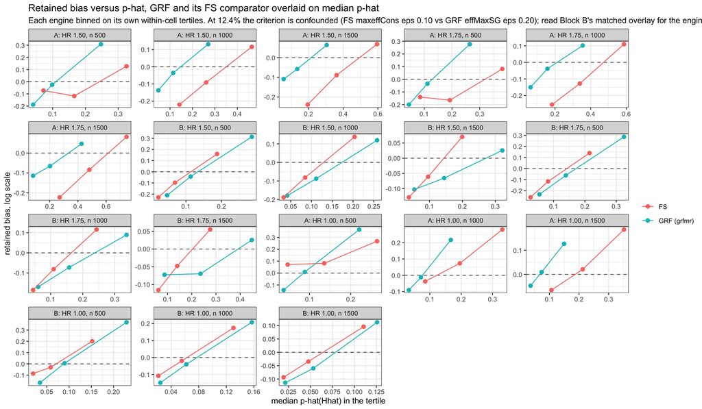

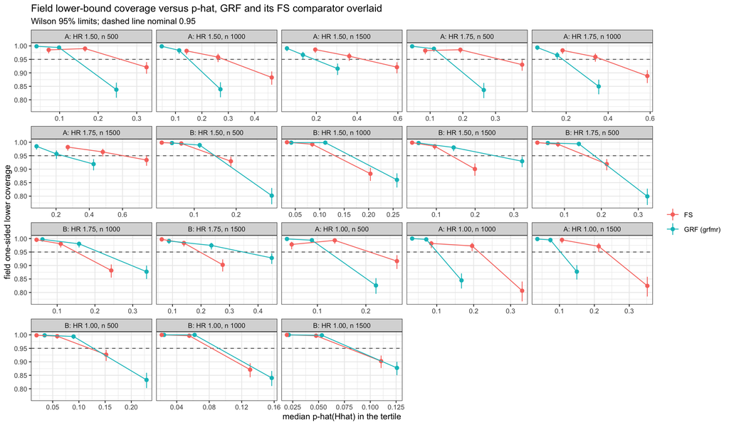

```r
if (!have(labs) || !exists("FSP") || !have(FSP)) skip_note("the bias-versus-p-hat overlay") else {
OV <- FSP
OV$cellf <- factor(OV$cell, levels = labs)
print(ggplot(OV, aes(p_hat_med, retained_bias_log, colour = engine, group = engine)) +
  geom_hline(yintercept = 0, linetype = 2, colour = "grey40") +
  geom_point(size = 2) + geom_line() +
  facet_wrap(~ cellf, scales = "free") +
  labs(x = "median p-hat(Hhat) in the tertile", y = "retained bias, log scale", colour = NULL,
       title = "Retained bias versus p-hat, GRF and its FS comparator overlaid on median p-hat",
       subtitle = "Each engine binned on its own within-cell tertiles. At 12.4% the criterion is confounded (FS maxeffCons eps 0.10 vs GRF effMaxSG eps 0.20); read Block B's matched overlay for the engine comparison.") +
  theme_bw(base_size = 10))
print(ggplot(OV, aes(p_hat_med, fldH_cov, colour = engine, group = engine)) +
  geom_hline(yintercept = 0.95, linetype = 2, colour = "grey40") +
  geom_pointrange(aes(ymin = wilson_lo, ymax = wilson_hi), size = 0.3) + geom_line() +
  facet_wrap(~ cellf, scales = "free_x") +
  labs(x = "median p-hat(Hhat) in the tertile", y = "field one-sided lower coverage", colour = NULL,
       title = "Field lower-bound coverage versus p-hat, GRF and its FS comparator overlaid",
       subtitle = "Wilson 95% limits; dashed line nominal 0.95") +
  theme_bw(base_size = 10))
}
```

# 10 The null cells (HR 1.00)

> **What HR 1.00 is on this path — settled, cited and not re-determined here.** HR 1.00 is **not a global null**. The planted region carries HR 1.00 against a benefiting complement (HR 0.657 at 12.4%, 0.721 at 31%) on this same template. That was established from source in the `dinamr` Block C Gate 0 (`REPORT_dinamr_blockC_2026-09-11.md`, “GATE 0 — Stage 0, verified from source”; quoted in `summary_dinamr.qmd` Section 10). These cells are **differentially null against a benefiting complement**, and no harm vocabulary is used for them.

> **Nothing in the classification set is structurally undefined here.** The planted region exists, so sens, spec, PPV, NPV and the oracle target (log 1.00 = 0) are all defined. The structural columns are the ones structural on **every** GRF cell, not on account of HR 1.00: `n_cons_qual`, `band_n` and `p_star` (Section 1.2).

> **The rate here is a `selection_rate`, and nothing more is read into it (Larry, 2026-09-11).** The planted region carries HR 1.00 and GRF’s effect floor is log(0.90), **deliberately sub-null**, so a replicate that returns that region is making an **admissible selection** under the criterion in force. Naming the rate for an error would mislabel correct behaviour, so it is named for what it counts and read as nothing else.

> **What speaks to a false claim is bound location, not selection.** Section 10.2 reports, per Block C cell, the share of field lower bounds **at or above 1.00** and **at or above 1.25** — the same columns as the DINA location tables (`scripts_dinamr/blockA_rest.R:74-75`) — and those columns carry the question. The selection rate does not.

> **Vocabulary in Block C.** These cells have no planted harm, so no harm vocabulary is used for them anywhere in this section. The planted region is described as **differentially null against a benefiting complement**: HR = 1.00 inside it, HR = 0.657 (12.4%) / 0.721 (31%) outside it. Every Block C caption states this.

What is recorded is the selection rate under the screen and, among selections, where every bound sits relative to the realized β(Ĥ) and β(Ĥᶜ) of whatever region GRF returned. Nothing here is scored.

**Criterion match at the null, as everywhere else.** The FS comparator is `cert20` (`effMaxSG`, ε 0.20) at all three n at **31% – criterion-matched to GRF**; and `tier2` at n 500 / `p12ext` at n 1000 and 1500 (`maxeffCons`, ε 0.10) at **12.4% – not matched**, where the criterion is the fourth confounded difference set out in Section 7. Every FS number below carries its own `campaign / sg_focus / eps`.

```r
if (!length(null_labs)) skip_note("the null-cell table (no HR 1.00 cell on disk)") else {
NUL <- do.call(rbind, lapply(null_labs, function(k) {
  r <- B[[k]]$results; d <- prep(r)
  if (!nrow(d)) return(NULL)
  A <- r$admitted_n[is.finite(r$admitted_n)]
  data.frame(cell = k, block = BLK[[k]], n = NN[[k]], selection_rate = mean(r$detected %in% 1L),
             n_eval = nrow(d),
             adm_med = stats::median(A), adm_q25 = unname(stats::quantile(A, .25)),
             adm_q75 = unname(stats::quantile(A, .75)), adm_p90 = unname(stats::quantile(A, .90)),
             pool_K_med = stats::median(r$n_family, na.rm = TRUE),
             beta_H_mean = mean(d$betaHhat_H), beta_Hc_mean = mean(d$betaHhat_Hc),
             region_field_1s = mean(d$betaHhat_H >= d$fld_H_lo1s),
             compl_field_s_1s = mean(d$betaHhat_Hc <= d$fld_Hc_up1s_s),
             compl_field_1s = mean(d$betaHhat_Hc <= d$fld_Hc_up1s),
             H_lower_mean = mean(d$fld_H_lo1s),
             share_H_lower_ge_100 = mean(d$fld_H_lo1s >= 1.00),
             share_H_lower_ge_125 = mean(d$fld_H_lo1s >= 1.25),
             Hc_upper_mean = mean(d$fld_Hc_up1s_s),
             share_Hc_upper_lt_085 = mean(d$fld_Hc_up1s_s < 0.85),
             share_Hc_upper_lt_080 = mean(d$fld_Hc_up1s_s < 0.80)) }))
if (!have(NUL)) skip_note("the null-cell table") else
kbl(NUL, digits = 4, booktabs = TRUE, row.names = FALSE,
    caption = paste("Null cells, both prevalence blocks: the SELECTION RATE under the screen -- a selection rate and nothing more, since the planted region clears GRF's deliberately sub-null log(0.90) floor and returning it is an admissible selection; the ADMITTED count admitted_n (median, q25, q75, p90) -- the stratifier -- with the ENUMERATED POOL n_family (pool_K_med) beside it, which is outcome-independent and not the qualified set; among selections the realized beta on the region and on its complement, the one-sided rate of each bound against its own realized beta, and THE BOUNDS BY LOCATION (share of the region's lower bound at or above 1.00 and at or above 1.25; share of the complement upper bound below 0.85 and 0.80). Bound location, not the selection rate, is what speaks to a false claim -- see @sec-null-location. Recorded, not scored.",
                    "Over detected replicates throughout. BLOCK C CELLS ARE DIFFERENTIALLY NULL AGAINST A BENEFITING COMPLEMENT -- the planted region carries HR 1.00 and its complement HR 0.657 (12.4%) / 0.721 (31%) -- so there is no planted harm here and no harm vocabulary is used.")) |>
  kable_styling(font_size = 9)
}
```

Null cells, both prevalence blocks: the SELECTION RATE under the screen -- a selection rate and nothing more, since the planted region clears GRF's deliberately sub-null log(0.90) floor and returning it is an admissible selection; the ADMITTED count admitted_n (median, q25, q75, p90) -- the stratifier -- with the ENUMERATED POOL n_family (pool_K_med) beside it, which is outcome-independent and not the qualified set; among selections the realized beta on the region and on its complement, the one-sided rate of each bound against its own realized beta, and THE BOUNDS BY LOCATION (share of the region's lower bound at or above 1.00 and at or above 1.25; share of the complement upper bound below 0.85 and 0.80). Bound location, not the selection rate, is what speaks to a false claim -- see @sec-null-location. Recorded, not scored. Over detected replicates throughout. BLOCK C CELLS ARE DIFFERENTIALLY NULL AGAINST A BENEFITING COMPLEMENT -- the planted region carries HR 1.00 and its complement HR 0.657 (12.4%) / 0.721 (31%) -- so there is no planted harm here and no harm vocabulary is used.

| cell | block | n | selection_rate | n_eval | adm_med | adm_q25 | adm_q75 | adm_p90 | pool_K_med | beta_H_mean | beta_Hc_mean | region_field_1s | compl_field_s_1s | compl_field_1s | H_lower_mean | share_H_lower_ge_100 | share_H_lower_ge_125 | Hc_upper_mean | share_Hc_upper_lt_085 | share_Hc_upper_lt_080 |
| --- | --- | --- | --- | --- | --- | --- | --- | --- | --- | --- | --- | --- | --- | --- | --- | --- | --- | --- | --- | --- |
| A: HR 1.00, n 500 | A | 500 | 0.9840 | 1968 | 61.5 | 32.0 | 113 | 179.1 | 776 | 0.6861 | 0.6627 | 0.9395 | 0.9319 | 0.9258 | 0.4268 | 0.0061 | 0.0025 | 0.8207 | 0.6153 | 0.4487 |
| A: HR 1.00, n 1000 | A | 1000 | 0.9575 | 1915 | 38.0 | 17.0 | 70 | 109.0 | 830 | 0.7109 | 0.6585 | 0.9473 | 0.9431 | 0.9389 | 0.4857 | 0.0042 | 0.0010 | 0.7689 | 0.8606 | 0.6862 |
| A: HR 1.00, n 1500 | A | 1500 | 0.8675 | 1735 | 23.0 | 11.0 | 42 | 70.0 | 829 | 0.7305 | 0.6538 | 0.9568 | 0.9476 | 0.9418 | 0.5399 | 0.0046 | 0.0017 | 0.7463 | 0.9602 | 0.8207 |
| B: HR 1.00, n 500 | B | 500 | 0.9970 | 1994 | 166.0 | 95.5 | 281 | 397.6 | 776 | 0.8212 | 0.7677 | 0.9418 | 0.9107 | 0.9047 | 0.5161 | 0.0196 | 0.0065 | 0.9396 | 0.2568 | 0.1414 |
| B: HR 1.00, n 1000 | B | 1000 | 0.9980 | 1996 | 141.0 | 82.0 | 225 | 328.5 | 830 | 0.8456 | 0.7594 | 0.9469 | 0.9259 | 0.9088 | 0.5668 | 0.0110 | 0.0025 | 0.8775 | 0.3833 | 0.1909 |
| B: HR 1.00, n 1500 | B | 1500 | 0.9935 | 1987 | 115.0 | 66.0 | 176 | 250.0 | 830 | 0.8649 | 0.7479 | 0.9587 | 0.9361 | 0.9180 | 0.6144 | 0.0091 | 0.0010 | 0.8456 | 0.5430 | 0.2582 |

## 10.1 Every product at the null, absolute levels

```r
if (!have(VSN) || !have(VSN[VSN$arm == "null", ])) skip_note("the null-cell product table") else {
vn <- VSN[VSN$arm == "null", ]
# Block C carries no planted harm, so the shared column names -- built for the
# harm blocks -- are renamed here to region / complement vocabulary.
vn2 <- vn[, c("cell","block","n","n_eval","harm_field","harm_field_lo","harm_field_hi",
              "ij2_H","ij2_H_lo","ij2_H_hi","miss_below","miss_above",
              "comp_field_s","comp_field_s_lo","comp_field_s_hi","comp_field",
              "ij2_Hc","ij2_Hc_lo","ij2_Hc_hi",
              "joint_bonf","joint_s_bonf","joint_s_bonf_lo","joint_s_bonf_hi")]
names(vn2) <- c("cell","block","n","n_eval","region_field","region_field_lo","region_field_hi",
                "region_ij2","region_ij2_lo","region_ij2_hi","miss_below","miss_above",
                "compl_field_s","compl_field_s_lo","compl_field_s_hi","compl_field",
                "compl_ij2","compl_ij2_lo","compl_ij2_hi",
                "joint_bonf","joint_s_bonf","joint_s_bonf_lo","joint_s_bonf_hi")
kbl(vn2, digits = 4, booktabs = TRUE, row.names = FALSE,
    caption = paste("BLOCK C (HR 1.00), both prevalence blocks, EVERY PRODUCT AT ITS ABSOLUTE LEVEL -- not a difference from FS. One-sided 95% LOWER coverage of beta(Hhat) on the identified region by the field bound; two-sided IJ two-term on the region with the miss split by side; one-sided UPPER coverage of beta(Hhat^c) by field-s with the unscaled field beside it; two-sided IJ two-term on the complement; and both Bonferroni joint pairs. Wilson limits throughout.",
                    "Over detected replicates throughout. BLOCK C CELLS ARE DIFFERENTIALLY NULL AGAINST A BENEFITING COMPLEMENT -- the planted region carries HR 1.00 and its complement HR 0.657 (12.4%) / 0.721 (31%) -- so there is no planted harm here and no harm vocabulary is used.",
                    "beta(Hhat) and beta(Hhat^c) are the realized targets of whatever region GRF returned.")) |>
  kable_styling(font_size = 8) |> scroll_box(width = "100%")
}
```

BLOCK C (HR 1.00), both prevalence blocks, EVERY PRODUCT AT ITS ABSOLUTE LEVEL -- not a difference from FS. One-sided 95% LOWER coverage of beta(Hhat) on the identified region by the field bound; two-sided IJ two-term on the region with the miss split by side; one-sided UPPER coverage of beta(Hhat^c) by field-s with the unscaled field beside it; two-sided IJ two-term on the complement; and both Bonferroni joint pairs. Wilson limits throughout. Over detected replicates throughout. BLOCK C CELLS ARE DIFFERENTIALLY NULL AGAINST A BENEFITING COMPLEMENT -- the planted region carries HR 1.00 and its complement HR 0.657 (12.4%) / 0.721 (31%) -- so there is no planted harm here and no harm vocabulary is used. beta(Hhat) and beta(Hhat^c) are the realized targets of whatever region GRF returned.

| cell | block | n | n_eval | region_field | region_field_lo | region_field_hi | region_ij2 | region_ij2_lo | region_ij2_hi | miss_below | miss_above | compl_field_s | compl_field_s_lo | compl_field_s_hi | compl_field | compl_ij2 | compl_ij2_lo | compl_ij2_hi | joint_bonf | joint_s_bonf | joint_s_bonf_lo | joint_s_bonf_hi |
| --- | --- | --- | --- | --- | --- | --- | --- | --- | --- | --- | --- | --- | --- | --- | --- | --- | --- | --- | --- | --- | --- | --- |
| A: HR 1.00, n 500 | A | 500 | 1968 | 0.9395 | 0.9281 | 0.9492 | 0.9924 | 0.9875 | 0.9954 | 0.0076 | 0.0000 | 0.9319 | 0.9199 | 0.9422 | 0.9258 | 1.0000 | 0.9981 | 1.0000 | 0.9345 | 0.9405 | 0.9292 | 0.9502 |
| A: HR 1.00, n 1000 | A | 1000 | 1915 | 0.9473 | 0.9363 | 0.9564 | 0.9911 | 0.9858 | 0.9945 | 0.0089 | 0.0000 | 0.9431 | 0.9318 | 0.9526 | 0.9389 | 1.0000 | 0.9980 | 1.0000 | 0.9384 | 0.9410 | 0.9295 | 0.9507 |
| A: HR 1.00, n 1500 | A | 1500 | 1735 | 0.9568 | 0.9462 | 0.9654 | 0.9925 | 0.9872 | 0.9956 | 0.0075 | 0.0000 | 0.9476 | 0.9360 | 0.9571 | 0.9418 | 1.0000 | 0.9978 | 1.0000 | 0.9499 | 0.9522 | 0.9411 | 0.9612 |
| B: HR 1.00, n 500 | B | 500 | 1994 | 0.9418 | 0.9307 | 0.9513 | 0.9935 | 0.9889 | 0.9962 | 0.0065 | 0.0000 | 0.9107 | 0.8974 | 0.9225 | 0.9047 | 1.0000 | 0.9981 | 1.0000 | 0.9188 | 0.9273 | 0.9150 | 0.9379 |
| B: HR 1.00, n 1000 | B | 1000 | 1996 | 0.9469 | 0.9362 | 0.9559 | 0.9905 | 0.9852 | 0.9939 | 0.0085 | 0.0010 | 0.9259 | 0.9135 | 0.9365 | 0.9088 | 0.9995 | 0.9972 | 0.9999 | 0.9274 | 0.9334 | 0.9216 | 0.9435 |
| B: HR 1.00, n 1500 | B | 1500 | 1987 | 0.9587 | 0.9491 | 0.9666 | 0.9914 | 0.9863 | 0.9947 | 0.0060 | 0.0025 | 0.9361 | 0.9245 | 0.9460 | 0.9180 | 0.9995 | 0.9972 | 0.9999 | 0.9346 | 0.9467 | 0.9359 | 0.9557 |

## 10.2 Bound location in Block C

This is the table that speaks to a false claim. The selection rate does not: returning a region that clears a deliberately sub-null floor is admissible. **Where the lower bound sits** is the question, and it is asked with the same columns as the DINA null location tables (`scripts_dinamr/blockA_rest.R:63-76`, `REPORT_dinamr_blockC_2026-09-11.md` “Bound location”), including the two share columns at **1.00** and **1.25**, now with Wilson intervals.

**Two quantities, reported separately.** The selection rate (over all 2,000 replicates) and the location shares (over the detected replicates) sit in separate columns and are read separately. If GRF selects at or near 1 even where the planted region is null, its selection rate carries no information at these cells and the location shares are the entire diagnostic.

**FS beside GRF, with the comparator’s criterion on every row.** At **31%** the FS comparator is `cert20`, `effMaxSG` at ε 0.20 — **criterion-matched** to GRF. At **12.4%** it is `tier2` (n 500) / `p12ext` (n 1000, 1500), `maxeffCons` at ε 0.10 — **not matched**. **Confound, with every comparison:** FS and GRF differ in identifier, in family construction and in detection set; at 12.4% they differ in the selection criterion as well, so a 12.4% gap cannot be read as engine behaviour even in part. Descriptive, not a contest.

```r
if (!length(null_labs)) skip_note("the Block C location table") else {
# One row per engine per cell, on the row set fs_extraction.R uses for FS:
# detected, with the field lower bound and theta(Hhat) finite.
loc_row <- function(r, truth, k, engine, crit, matched) {
  d <- r[r$detected %in% 1L & is.finite(r$fld_H_lo1s) & is.finite(r$betaHhat_H), , drop = FALSE]
  if (!nrow(d)) return(NULL)
  sr <- mean(r$detected %in% 1L); wsr <- wil(sr, nrow(r))
  s1 <- mean(d$fld_H_lo1s >= 1.00); w1 <- wil(s1, nrow(d))
  s2 <- mean(d$fld_H_lo1s >= 1.25); w2 <- wil(s2, nrow(d))
  data.frame(cell = k, block = BLK[[k]], n = NN[[k]], engine = engine, criterion = crit,
             criterion_matched = matched,
             selection_rate = sr, selection_wilson_lo = wsr[1], selection_wilson_hi = wsr[2],
             n_eval = nrow(d),
             med_fld_H_lo1s    = stats::median(d$fld_H_lo1s),
             med_theta_Hhat    = stats::median(d$betaHhat_H),
             med_fld_H_est2    = stats::median(d$fld_H_est2),
             med_naive_H       = stats::median(d$nv_H_est),
             bound_minus_theta = stats::median(d$fld_H_lo1s) - stats::median(d$betaHhat_H),
             bound_over_theta  = stats::median(d$fld_H_lo1s) / stats::median(d$betaHhat_H),
             med_paired_ratio  = stats::median(d$fld_H_lo1s / d$betaHhat_H),
             planted_marg_H    = unname(truth$marg_H),
             share_bound_ge_1.00 = s1, s100_wilson_lo = w1[1], s100_wilson_hi = w1[2],
             share_bound_ge_1.25 = s2, s125_wilson_lo = w2[1], s125_wilson_hi = w2[2],
             stringsAsFactors = FALSE) }
LOC <- do.call(rbind, lapply(null_labs, function(k) {
  x <- fs_for(k)
  rbind(loc_row(B[[k]]$results, B[[k]]$truth, k, "GRF (grfmr)", "grfmr / effMaxSG / eps 0.2", TRUE),
        if (is.null(x)) NULL else
          loc_row(x$b$results, x$b$truth, k, "FS", fs_crit(x),
                  identical(x$focus, "effMaxSG") && isTRUE(all.equal(x$eps, 0.20)))) }))
if (!have(LOC)) skip_note("the Block C location table") else {
LOC <- LOC[order(LOC$block, LOC$n, LOC$engine != "GRF (grfmr)"), ]
kbl(LOC, digits = 4, booktabs = TRUE, row.names = FALSE,
    caption = paste("BLOCK C, SELECTION RATE AND BOUND LOCATION, GRF beside its FS comparator, per cell. Products: the field one-sided lower bound on beta(Hhat) (fld_H_lo1s), the field point estimate (fld_H_est2) and the naive estimate. Columns: the selection rate over all 2,000 replicates with Wilson limits, as a SEPARATE quantity; then, over detected replicates, the median field lower bound against the median realized theta(Hhat) on the HR scale, the field and naive estimates beside them, the bound-to-target gap in difference, ratio and paired-ratio form, the planted marginal target, and THE TWO SHARE COLUMNS -- the share of field lower bounds at or above 1.00 and at or above 1.25 -- each with Wilson limits. Cells: the six HR 1.00 cells, 12.4% and 31% at n 500 / 1000 / 1500. The criterion column carries each row's campaign / sg_focus / eps: criterion_matched is TRUE at 31% (cert20, effMaxSG eps 0.20) and FALSE at 12.4% (tier2 / p12ext, maxeffCons eps 0.10). Confound with every comparison: FS and GRF differ in identifier, family construction and detection set, and at 12.4% in the selection criterion as well. The selection rate is not an error rate: the planted region clears the sub-null log(0.90) floor, so returning it is admissible.",
                    "Rates other than the selection rate are over detected replicates. BLOCK C CELLS ARE DIFFERENTIALLY NULL AGAINST A BENEFITING COMPLEMENT -- the planted region carries HR 1.00 and its complement HR 0.657 (12.4%) / 0.721 (31%) -- so there is no planted harm here and no harm vocabulary is used.")) |>
  kable_styling(font_size = 8) |> scroll_box(width = "100%")
}
}
```

BLOCK C, SELECTION RATE AND BOUND LOCATION, GRF beside its FS comparator, per cell. Products: the field one-sided lower bound on beta(Hhat) (fld_H_lo1s), the field point estimate (fld_H_est2) and the naive estimate. Columns: the selection rate over all 2,000 replicates with Wilson limits, as a SEPARATE quantity; then, over detected replicates, the median field lower bound against the median realized theta(Hhat) on the HR scale, the field and naive estimates beside them, the bound-to-target gap in difference, ratio and paired-ratio form, the planted marginal target, and THE TWO SHARE COLUMNS -- the share of field lower bounds at or above 1.00 and at or above 1.25 -- each with Wilson limits. Cells: the six HR 1.00 cells, 12.4% and 31% at n 500 / 1000 / 1500. The criterion column carries each row's campaign / sg_focus / eps: criterion_matched is TRUE at 31% (cert20, effMaxSG eps 0.20) and FALSE at 12.4% (tier2 / p12ext, maxeffCons eps 0.10). Confound with every comparison: FS and GRF differ in identifier, family construction and detection set, and at 12.4% in the selection criterion as well. The selection rate is not an error rate: the planted region clears the sub-null log(0.90) floor, so returning it is admissible. Rates other than the selection rate are over detected replicates. BLOCK C CELLS ARE DIFFERENTIALLY NULL AGAINST A BENEFITING COMPLEMENT -- the planted region carries HR 1.00 and its complement HR 0.657 (12.4%) / 0.721 (31%) -- so there is no planted harm here and no harm vocabulary is used.

| cell | block | n | engine | criterion | criterion_matched | selection_rate | selection_wilson_lo | selection_wilson_hi | n_eval | med_fld_H_lo1s | med_theta_Hhat | med_fld_H_est2 | med_naive_H | bound_minus_theta | bound_over_theta | med_paired_ratio | planted_marg_H | share_bound_ge_1.00 | s100_wilson_lo | s100_wilson_hi | share_bound_ge_1.25 | s125_wilson_lo | s125_wilson_hi |
| --- | --- | --- | --- | --- | --- | --- | --- | --- | --- | --- | --- | --- | --- | --- | --- | --- | --- | --- | --- | --- | --- | --- | --- |
| A: HR 1.00, n 500 | A | 500 | GRF (grfmr) | grfmr / effMaxSG / eps 0.2 | TRUE | 0.9840 | 0.9775 | 0.9886 | 1968 | 0.3943 | 0.6765 | 0.7085 | 1.2992 | -0.2821 | 0.5830 | 0.5779 | 1.0005 | 0.0061 | 0.0035 | 0.0106 | 0.0025 | 0.0011 | 0.0059 |
| A: HR 1.00, n 500 | A | 500 | FS | tier2 / maxeffCons / eps 0.1 | FALSE | 0.6805 | 0.6597 | 0.7006 | 1361 | 0.4276 | 0.7053 | 0.7928 | 1.5796 | -0.2777 | 0.6062 | 0.6036 | 1.0005 | 0.0029 | 0.0011 | 0.0075 | 0.0000 | 0.0000 | 0.0028 |
| A: HR 1.00, n 1000 | A | 1000 | GRF (grfmr) | grfmr / effMaxSG / eps 0.2 | TRUE | 0.9575 | 0.9477 | 0.9655 | 1915 | 0.4547 | 0.7060 | 0.7011 | 1.0726 | -0.2513 | 0.6440 | 0.6541 | 1.0005 | 0.0042 | 0.0021 | 0.0082 | 0.0010 | 0.0003 | 0.0038 |
| A: HR 1.00, n 1000 | A | 1000 | FS | p12ext / maxeffCons / eps 0.1 | FALSE | 0.6595 | 0.6384 | 0.6799 | 1319 | 0.5116 | 0.7448 | 0.8138 | 1.3564 | -0.2332 | 0.6869 | 0.6933 | 1.0005 | 0.0076 | 0.0041 | 0.0139 | 0.0023 | 0.0008 | 0.0067 |
| A: HR 1.00, n 1500 | A | 1500 | GRF (grfmr) | grfmr / effMaxSG / eps 0.2 | TRUE | 0.8675 | 0.8519 | 0.8817 | 1735 | 0.5165 | 0.7286 | 0.7229 | 0.9750 | -0.2122 | 0.7088 | 0.7219 | 1.0005 | 0.0046 | 0.0023 | 0.0091 | 0.0017 | 0.0006 | 0.0051 |
| A: HR 1.00, n 1500 | A | 1500 | FS | p12ext / maxeffCons / eps 0.1 | FALSE | 0.6240 | 0.6026 | 0.6450 | 1248 | 0.5571 | 0.8029 | 0.8113 | 1.2137 | -0.2459 | 0.6938 | 0.7026 | 1.0005 | 0.0064 | 0.0033 | 0.0126 | 0.0008 | 0.0001 | 0.0045 |
| B: HR 1.00, n 500 | B | 500 | GRF (grfmr) | grfmr / effMaxSG / eps 0.2 | TRUE | 0.9970 | 0.9935 | 0.9986 | 1994 | 0.4764 | 0.8148 | 0.8407 | 1.5112 | -0.3383 | 0.5848 | 0.5869 | 0.9999 | 0.0196 | 0.0143 | 0.0266 | 0.0065 | 0.0038 | 0.0111 |
| B: HR 1.00, n 500 | B | 500 | FS | cert20 / effMaxSG / eps 0.2 | TRUE | 0.9205 | 0.9078 | 0.9316 | 1841 | 0.4591 | 0.8241 | 0.8108 | 1.4660 | -0.3650 | 0.5571 | 0.5637 | 0.9999 | 0.0060 | 0.0033 | 0.0107 | 0.0005 | 0.0001 | 0.0031 |
| B: HR 1.00, n 1000 | B | 1000 | GRF (grfmr) | grfmr / effMaxSG / eps 0.2 | TRUE | 0.9980 | 0.9949 | 0.9992 | 1996 | 0.5383 | 0.8492 | 0.8229 | 1.2141 | -0.3109 | 0.6339 | 0.6427 | 0.9999 | 0.0110 | 0.0073 | 0.0166 | 0.0025 | 0.0011 | 0.0059 |
| B: HR 1.00, n 1000 | B | 1000 | FS | cert20 / effMaxSG / eps 0.2 | TRUE | 0.9545 | 0.9445 | 0.9628 | 1909 | 0.5512 | 0.8494 | 0.8326 | 1.2322 | -0.2982 | 0.6489 | 0.6558 | 0.9999 | 0.0105 | 0.0068 | 0.0161 | 0.0016 | 0.0005 | 0.0046 |
| B: HR 1.00, n 1500 | B | 1500 | GRF (grfmr) | grfmr / effMaxSG / eps 0.2 | TRUE | 0.9935 | 0.9889 | 0.9962 | 1987 | 0.5943 | 0.8786 | 0.8228 | 1.0818 | -0.2843 | 0.6764 | 0.6902 | 0.9999 | 0.0091 | 0.0057 | 0.0143 | 0.0010 | 0.0003 | 0.0037 |
| B: HR 1.00, n 1500 | B | 1500 | FS | cert20 / effMaxSG / eps 0.2 | TRUE | 0.9590 | 0.9494 | 0.9668 | 1918 | 0.6032 | 0.8709 | 0.8279 | 1.0905 | -0.2677 | 0.6926 | 0.7058 | 0.9999 | 0.0094 | 0.0059 | 0.0148 | 0.0010 | 0.0003 | 0.0038 |

## 10.3 The null cells beside their FS comparator, with the criterion named

```r
if (!length(null_labs)) skip_note("the null-cell FS comparison") else {
NFS <- do.call(rbind, lapply(null_labs, function(k) {
  x <- fs_for(k); r <- B[[k]]$results
  dn <- r[r$detected %in% 1L & is.finite(r$betaHhat_H) & is.finite(r$fld_H_lo1s), , drop = FALSE]
  row <- data.frame(cell = k, block = BLK[[k]], n = NN[[k]],
    grf_criterion = "grfmr / effMaxSG / eps 0.2",
    grf_selection = mean(r$detected %in% 1L),
    grf_K_med = stats::median(r$n_family, na.rm = TRUE),
    grf_field_H = if (nrow(dn)) mean(dn$betaHhat_H >= dn$fld_H_lo1s) else NA_real_,
    grf_ij2_H = if (nrow(dn)) mean(dn$betaHhat_H >= dn$mr_H_lo & dn$betaHhat_H <= dn$mr_H_hi) else NA_real_)
  if (is.null(x)) return(cbind(row, fs_criterion = "not on disk", fs_matched = NA,
                               fs_selection = NA_real_, fs_K_med = NA_real_,
                               fs_field_H = NA_real_, fs_ij2_H = NA_real_))
  fr <- x$b$results
  fd <- fr[fr$detected %in% 1L & is.finite(fr$betaHhat_H) & is.finite(fr$fld_H_lo1s), , drop = FALSE]
  cbind(row, fs_criterion = fs_crit(x),
        fs_matched = identical(x$focus, "effMaxSG") && isTRUE(all.equal(x$eps, 0.20)),
        fs_selection = mean(fr$detected %in% 1L),
        fs_K_med = stats::median(fr$n_family, na.rm = TRUE),
        fs_field_H = if (nrow(fd)) mean(fd$betaHhat_H >= fd$fld_H_lo1s) else NA_real_,
        fs_ij2_H = if (nrow(fd)) mean(fd$betaHhat_H >= fd$mr_H_lo & fd$betaHhat_H <= fd$mr_H_hi) else NA_real_) }))
if (!have(NFS)) skip_note("the null-cell FS comparison") else
kbl(NFS, digits = 4, booktabs = TRUE, row.names = FALSE,
    caption = paste("Block C beside the committed FS comparator that shares the DGM draws, read as it stands. ABSOLUTE LEVELS on both sides; no difference column, and no contest. fs_matched is TRUE only where the FS comparator's own sg_focus and eps equal GRF's (effMaxSG, 0.20) -- TRUE at 31% (cert20), FALSE at 12.4% (tier2 / p12ext, maxeffCons at eps 0.10), where the criterion is a fourth confounded difference on top of identifier, family construction and detection set. grf_selection / fs_selection are selection rates and nothing more: the planted region clears GRF's sub-null log(0.90) floor, so returning it is an admissible selection.",
                    "Over detected replicates throughout. BLOCK C CELLS ARE DIFFERENTIALLY NULL AGAINST A BENEFITING COMPLEMENT -- the planted region carries HR 1.00 and its complement HR 0.657 (12.4%) / 0.721 (31%) -- so there is no planted harm here and no harm vocabulary is used.")) |>
  kable_styling(font_size = 9)
}
```

Block C beside the committed FS comparator that shares the DGM draws, read as it stands. ABSOLUTE LEVELS on both sides; no difference column, and no contest. fs_matched is TRUE only where the FS comparator's own sg_focus and eps equal GRF's (effMaxSG, 0.20) -- TRUE at 31% (cert20), FALSE at 12.4% (tier2 / p12ext, maxeffCons at eps 0.10), where the criterion is a fourth confounded difference on top of identifier, family construction and detection set. grf_selection / fs_selection are selection rates and nothing more: the planted region clears GRF's sub-null log(0.90) floor, so returning it is an admissible selection. Over detected replicates throughout. BLOCK C CELLS ARE DIFFERENTIALLY NULL AGAINST A BENEFITING COMPLEMENT -- the planted region carries HR 1.00 and its complement HR 0.657 (12.4%) / 0.721 (31%) -- so there is no planted harm here and no harm vocabulary is used.

| cell | block | n | grf_criterion | grf_selection | grf_K_med | grf_field_H | grf_ij2_H | fs_criterion | fs_matched | fs_selection | fs_K_med | fs_field_H | fs_ij2_H |
| --- | --- | --- | --- | --- | --- | --- | --- | --- | --- | --- | --- | --- | --- |
| A: HR 1.00, n 500 | A | 500 | grfmr / effMaxSG / eps 0.2 | 0.9840 | 776 | 0.9395 | 0.9924 | tier2 / maxeffCons / eps 0.1 | FALSE | 0.6805 | 1223 | 0.9625 | 0.9860 |
| A: HR 1.00, n 1000 | A | 1000 | grfmr / effMaxSG / eps 0.2 | 0.9575 | 830 | 0.9473 | 0.9911 | p12ext / maxeffCons / eps 0.1 | FALSE | 0.6595 | 1300 | 0.9204 | 0.9803 |
| A: HR 1.00, n 1500 | A | 1500 | grfmr / effMaxSG / eps 0.2 | 0.8675 | 829 | 0.9568 | 0.9925 | p12ext / maxeffCons / eps 0.1 | FALSE | 0.6240 | 1297 | 0.9303 | 0.9824 |
| B: HR 1.00, n 500 | B | 500 | grfmr / effMaxSG / eps 0.2 | 0.9970 | 776 | 0.9418 | 0.9935 | cert20 / effMaxSG / eps 0.2 | TRUE | 0.9205 | 1223 | 0.9734 | 0.9946 |
| B: HR 1.00, n 1000 | B | 1000 | grfmr / effMaxSG / eps 0.2 | 0.9980 | 830 | 0.9469 | 0.9905 | cert20 / effMaxSG / eps 0.2 | TRUE | 0.9545 | 1299 | 0.9560 | 0.9948 |
| B: HR 1.00, n 1500 | B | 1500 | grfmr / effMaxSG / eps 0.2 | 0.9935 | 830 | 0.9587 | 0.9914 | cert20 / effMaxSG / eps 0.2 | TRUE | 0.9590 | 1297 | 0.9666 | 0.9964 |

# 11 Numbers for the record

**Detection (harm cells) or selection rate (HR 1.00 cells), the admitted set and the enumerated pool (the headline):**

- A: HR 1.50, n 500: detection 0.999 (1997/2000); admitted_n median 115, q90 260.4; enumerated pool n_family median 776, q90 784; realized trial prevalence 0.124
- A: HR 1.50, n 1000: detection 0.998 (1995/2000); admitted_n median 93, q90 198; enumerated pool n_family median 830, q90 836; realized trial prevalence 0.124
- A: HR 1.50, n 1500: detection 0.998 (1995/2000); admitted_n median 76, q90 156.6; enumerated pool n_family median 830, q90 836; realized trial prevalence 0.124
- A: HR 1.75, n 500: detection 1.000 (1999/2000); admitted_n median 136, q90 293; enumerated pool n_family median 776, q90 784; realized trial prevalence 0.124
- A: HR 1.75, n 1000: detection 0.999 (1998/2000); admitted_n median 121, q90 234; enumerated pool n_family median 830, q90 836; realized trial prevalence 0.124
- A: HR 1.75, n 1500: detection 1.000 (2000/2000); admitted_n median 105, q90 191; enumerated pool n_family median 830, q90 836; realized trial prevalence 0.124
- B: HR 1.50, n 500: detection 1.000 (2000/2000); admitted_n median 383, q90 578.1; enumerated pool n_family median 776, q90 784; realized trial prevalence 0.306
- B: HR 1.50, n 1000: detection 1.000 (2000/2000); admitted_n median 406, q90 586; enumerated pool n_family median 830, q90 836; realized trial prevalence 0.306
- B: HR 1.50, n 1500: detection 1.000 (2000/2000); admitted_n median 400.5, q90 555; enumerated pool n_family median 830, q90 836; realized trial prevalence 0.306
- B: HR 1.75, n 500: detection 1.000 (2000/2000); admitted_n median 449, q90 609.1; enumerated pool n_family median 776, q90 784; realized trial prevalence 0.306
- B: HR 1.75, n 1000: detection 1.000 (2000/2000); admitted_n median 487.5, q90 627.1; enumerated pool n_family median 830, q90 836; realized trial prevalence 0.306
- B: HR 1.75, n 1500: detection 1.000 (2000/2000); admitted_n median 493.5, q90 607.1; enumerated pool n_family median 830, q90 836; realized trial prevalence 0.306
- A: HR 1.00, n 500: selection rate 0.984 (1968/2000); admitted_n median 61.5, q90 179.1; enumerated pool n_family median 776, q90 784; realized trial prevalence 0.124
- A: HR 1.00, n 1000: selection rate 0.958 (1915/2000); admitted_n median 38, q90 109; enumerated pool n_family median 830, q90 836; realized trial prevalence 0.124
- A: HR 1.00, n 1500: selection rate 0.868 (1735/2000); admitted_n median 23, q90 70; enumerated pool n_family median 829, q90 836; realized trial prevalence 0.124
- B: HR 1.00, n 500: selection rate 0.997 (1994/2000); admitted_n median 166, q90 397.6; enumerated pool n_family median 776, q90 784; realized trial prevalence 0.306
- B: HR 1.00, n 1000: selection rate 0.998 (1996/2000); admitted_n median 141, q90 328.5; enumerated pool n_family median 830, q90 836; realized trial prevalence 0.306
- B: HR 1.00, n 1500: selection rate 0.994 (1987/2000); admitted_n median 115, q90 250; enumerated pool n_family median 830, q90 836; realized trial prevalence 0.306

**Coverage versus n (harm cells; field lower / field-s upper / IJ two-sided H / IJ two-sided Hc / joint_s Bonferroni) – over detected replicates throughout:**

- A: HR 1.50, n 500 (n_eval 1997): harm field 0.943 [0.932, 0.953]; complement field-s 0.932 [0.920, 0.942] (field 0.925); IJ two-sided 0.989 / 0.999; joint_s Bonferroni 0.936 [0.924, 0.946]
- A: HR 1.50, n 1000 (n_eval 1995): harm field 0.940 [0.929, 0.950]; complement field-s 0.952 [0.942, 0.960] (field 0.947); IJ two-sided 0.987 / 1.000; joint_s Bonferroni 0.940 [0.929, 0.949]
- A: HR 1.50, n 1500 (n_eval 1995): harm field 0.958 [0.948, 0.966]; complement field-s 0.953 [0.943, 0.961] (field 0.951); IJ two-sided 0.980 / 0.999; joint_s Bonferroni 0.954 [0.944, 0.963]
- A: HR 1.75, n 500 (n_eval 1999): harm field 0.941 [0.930, 0.951]; complement field-s 0.933 [0.922, 0.944] (field 0.926); IJ two-sided 0.990 / 0.999; joint_s Bonferroni 0.935 [0.923, 0.945]
- A: HR 1.75, n 1000 (n_eval 1998): harm field 0.936 [0.925, 0.946]; complement field-s 0.954 [0.944, 0.962] (field 0.952); IJ two-sided 0.977 / 1.000; joint_s Bonferroni 0.940 [0.929, 0.950]
- A: HR 1.75, n 1500 (n_eval 2000): harm field 0.954 [0.943, 0.962]; complement field-s 0.956 [0.946, 0.964] (field 0.957); IJ two-sided 0.976 / 1.000; joint_s Bonferroni 0.958 [0.948, 0.965]
- B: HR 1.50, n 500 (n_eval 2000): harm field 0.929 [0.917, 0.940]; complement field-s 0.918 [0.906, 0.930] (field 0.915); IJ two-sided 0.984 / 1.000; joint_s Bonferroni 0.923 [0.910, 0.934]
- B: HR 1.50, n 1000 (n_eval 2000): harm field 0.953 [0.942, 0.961]; complement field-s 0.946 [0.935, 0.955] (field 0.942); IJ two-sided 0.967 / 0.999; joint_s Bonferroni 0.951 [0.940, 0.959]
- B: HR 1.50, n 1500 (n_eval 2000): harm field 0.969 [0.960, 0.976]; complement field-s 0.948 [0.937, 0.957] (field 0.938); IJ two-sided 0.973 / 1.000; joint_s Bonferroni 0.957 [0.947, 0.965]
- B: HR 1.75, n 500 (n_eval 2000): harm field 0.930 [0.918, 0.940]; complement field-s 0.921 [0.908, 0.932] (field 0.917); IJ two-sided 0.973 / 1.000; joint_s Bonferroni 0.926 [0.914, 0.937]
- B: HR 1.75, n 1000 (n_eval 2000): harm field 0.952 [0.941, 0.960]; complement field-s 0.951 [0.941, 0.960] (field 0.944); IJ two-sided 0.964 / 1.000; joint_s Bonferroni 0.947 [0.936, 0.956]
- B: HR 1.75, n 1500 (n_eval 2000): harm field 0.965 [0.955, 0.972]; complement field-s 0.941 [0.930, 0.951] (field 0.934); IJ two-sided 0.981 / 1.000; joint_s Bonferroni 0.955 [0.945, 0.963]

**The two-sided harm-block trajectory at 12.4%, miss split by side:**

- A: HR 1.50, n 500: IJ two-sided 0.989 [0.983, 0.993]; miss below 0.008, miss above 0.003
- A: HR 1.50, n 1000: IJ two-sided 0.987 [0.981, 0.991]; miss below 0.009, miss above 0.004
- A: HR 1.50, n 1500: IJ two-sided 0.980 [0.973, 0.985]; miss below 0.007, miss above 0.014
- A: HR 1.75, n 500: IJ two-sided 0.990 [0.985, 0.994]; miss below 0.007, miss above 0.004
- A: HR 1.75, n 1000: IJ two-sided 0.977 [0.970, 0.983]; miss below 0.008, miss above 0.015
- A: HR 1.75, n 1500: IJ two-sided 0.976 [0.968, 0.981]; miss below 0.004, miss above 0.020

**Classification versus n and prevalence:**

- A: HR 1.50, n 500: detection 0.999; sens 0.516 spec 0.836 ppv 0.319 npv 0.925; |Hhat|/|H| median 1.574 q90 2.456; beta(Hhat) 0.854 vs planted 1.509; beta(Hhat^c) 0.680 vs planted 0.657; naive optimism 2.209 marginal-SD / 1.807 error-SD (H), -0.870 / -0.914 (Hc); mean p-hat 0.139; enumerated pool median 776
- A: HR 1.50, n 1000: detection 0.998; sens 0.644 spec 0.885 ppv 0.481 npv 0.947; |Hhat|/|H| median 1.393 q90 2.175; beta(Hhat) 1.004 vs planted 1.509; beta(Hhat^c) 0.665 vs planted 0.657; naive optimism 1.464 marginal-SD / 1.347 error-SD (H), -0.657 / -0.674 (Hc); mean p-hat 0.157; enumerated pool median 830
- A: HR 1.50, n 1500: detection 0.998; sens 0.745 spec 0.896 ppv 0.552 npv 0.962; |Hhat|/|H| median 1.448 q90 2.242; beta(Hhat) 1.066 vs planted 1.509; beta(Hhat^c) 0.655 vs planted 0.657; naive optimism 0.938 marginal-SD / 1.085 error-SD (H), -0.561 / -0.563 (Hc); mean p-hat 0.177; enumerated pool median 830
- A: HR 1.75, n 500: detection 1.000; sens 0.575 spec 0.850 ppv 0.366 npv 0.935; |Hhat|/|H| median 1.552 q90 2.386; beta(Hhat) 0.954 vs planted 1.769; beta(Hhat^c) 0.682 vs planted 0.657; naive optimism 1.997 marginal-SD / 1.629 error-SD (H), -0.795 / -0.824 (Hc); mean p-hat 0.151; enumerated pool median 776
- A: HR 1.75, n 1000: detection 0.999; sens 0.697 spec 0.908 ppv 0.563 npv 0.955; |Hhat|/|H| median 1.298 q90 1.972; beta(Hhat) 1.201 vs planted 1.769; beta(Hhat^c) 0.664 vs planted 0.657; naive optimism 1.127 marginal-SD / 1.117 error-SD (H), -0.522 / -0.536 (Hc); mean p-hat 0.205; enumerated pool median 830
- A: HR 1.75, n 1500: detection 1.000; sens 0.777 spec 0.921 ppv 0.639 npv 0.967; |Hhat|/|H| median 1.278 q90 2.001; beta(Hhat) 1.292 vs planted 1.769; beta(Hhat^c) 0.655 vs planted 0.657; naive optimism 0.647 marginal-SD / 0.832 error-SD (H), -0.421 / -0.422 (Hc); mean p-hat 0.249; enumerated pool median 830
- B: HR 1.50, n 500: detection 1.000; sens 0.522 spec 0.899 ppv 0.678 npv 0.816; |Hhat|/|H| median 0.689 q90 1.083; beta(Hhat) 1.236 vs planted 1.499; beta(Hhat^c) 0.821 vs planted 0.721; naive optimism 1.771 marginal-SD / 1.451 error-SD (H), -0.726 / -0.810 (Hc); mean p-hat 0.158; enumerated pool median 776
- B: HR 1.50, n 1000: detection 1.000; sens 0.683 spec 0.931 ppv 0.805 npv 0.878; |Hhat|/|H| median 0.900 q90 1.189; beta(Hhat) 1.357 vs planted 1.499; beta(Hhat^c) 0.780 vs planted 0.721; naive optimism 1.122 marginal-SD / 0.953 error-SD (H), -0.507 / -0.629 (Hc); mean p-hat 0.151; enumerated pool median 830
- B: HR 1.50, n 1500: detection 1.000; sens 0.818 spec 0.934 ppv 0.852 npv 0.928; |Hhat|/|H| median 1.000 q90 1.329; beta(Hhat) 1.399 vs planted 1.499; beta(Hhat^c) 0.747 vs planted 0.721; naive optimism 0.673 marginal-SD / 0.643 error-SD (H), -0.419 / -0.500 (Hc); mean p-hat 0.183; enumerated pool median 830
- B: HR 1.75, n 500: detection 1.000; sens 0.582 spec 0.922 ppv 0.749 npv 0.840; |Hhat|/|H| median 0.696 q90 1.071; beta(Hhat) 1.485 vs planted 1.746; beta(Hhat^c) 0.828 vs planted 0.721; naive optimism 1.545 marginal-SD / 1.227 error-SD (H), -0.603 / -0.696 (Hc); mean p-hat 0.182; enumerated pool median 776
- B: HR 1.75, n 1000: detection 1.000; sens 0.733 spec 0.950 ppv 0.860 npv 0.899; |Hhat|/|H| median 0.976 q90 1.117; beta(Hhat) 1.632 vs planted 1.746; beta(Hhat^c) 0.781 vs planted 0.721; naive optimism 0.914 marginal-SD / 0.789 error-SD (H), -0.380 / -0.490 (Hc); mean p-hat 0.197; enumerated pool median 830
- B: HR 1.75, n 1500: detection 1.000; sens 0.844 spec 0.956 ppv 0.897 npv 0.940; |Hhat|/|H| median 1.000 q90 1.265; beta(Hhat) 1.678 vs planted 1.746; beta(Hhat^c) 0.748 vs planted 0.721; naive optimism 0.518 marginal-SD / 0.505 error-SD (H), -0.311 / -0.395 (Hc); mean p-hat 0.266; enumerated pool median 830
- A: HR 1.00, n 500: selection rate 0.984; sens 0.356 spec 0.810 ppv 0.213 npv 0.900; |Hhat|/|H| median 1.578 q90 2.517; beta(Hhat) 0.686 vs planted 1.000; beta(Hhat^c) 0.663 vs planted 0.657; naive optimism 2.603 marginal-SD / 2.333 error-SD (H), -1.001 / -1.020 (Hc); mean p-hat 0.127; enumerated pool median 776
- A: HR 1.00, n 1000: selection rate 0.958; sens 0.434 spec 0.830 ppv 0.275 npv 0.913; |Hhat|/|H| median 1.539 q90 2.496; beta(Hhat) 0.711 vs planted 1.000; beta(Hhat^c) 0.658 vs planted 0.657; naive optimism 2.463 marginal-SD / 2.132 error-SD (H), -0.964 / -0.977 (Hc); mean p-hat 0.104; enumerated pool median 830
- A: HR 1.00, n 1500: selection rate 0.868; sens 0.526 spec 0.834 ppv 0.324 npv 0.926; |Hhat|/|H| median 1.601 q90 2.518; beta(Hhat) 0.731 vs planted 1.000; beta(Hhat^c) 0.654 vs planted 0.657; naive optimism 2.613 marginal-SD / 2.120 error-SD (H), -0.960 / -0.970 (Hc); mean p-hat 0.096; enumerated pool median 829
- B: HR 1.00, n 500: selection rate 0.997; sens 0.350 spec 0.835 ppv 0.471 npv 0.748; |Hhat|/|H| median 0.667 q90 1.067; beta(Hhat) 0.821 vs planted 1.000; beta(Hhat^c) 0.768 vs planted 0.721; naive optimism 2.332 marginal-SD / 2.135 error-SD (H), -0.996 / -1.023 (Hc); mean p-hat 0.129; enumerated pool median 776
- B: HR 1.00, n 1000: selection rate 0.998; sens 0.439 spec 0.845 ppv 0.543 npv 0.779; |Hhat|/|H| median 0.723 q90 1.212; beta(Hhat) 0.846 vs planted 1.000; beta(Hhat^c) 0.759 vs planted 0.721; naive optimism 1.984 marginal-SD / 1.729 error-SD (H), -0.999 / -1.050 (Hc); mean p-hat 0.096; enumerated pool median 830
- B: HR 1.00, n 1500: selection rate 0.994; sens 0.568 spec 0.833 ppv 0.602 npv 0.821; |Hhat|/|H| median 0.955 q90 1.402; beta(Hhat) 0.865 vs planted 1.000; beta(Hhat^c) 0.748 vs planted 0.721; naive optimism 1.657 marginal-SD / 1.430 error-SD (H), -1.019 / -1.077 (Hc); mean p-hat 0.078; enumerated pool median 830

**Proposed-family size and its stabilization:**

- A: HR 1.50, n 500: K min 712, q10 766, median 776, q90 784, max 870; mean 776.327, SD 14.042, CV 0.018, IQR/median 0.012
- A: HR 1.50, n 1000: K min 779, q10 823, median 830, q90 836, max 914; mean 830.191, SD 9.229, CV 0.011, IQR/median 0.008
- A: HR 1.50, n 1500: K min 780, q10 824, median 830, q90 836, max 913; mean 829.772, SD 6.745, CV 0.008, IQR/median 0.008
- A: HR 1.75, n 500: K min 712, q10 766, median 776, q90 784, max 870; mean 776.320, SD 14.037, CV 0.018, IQR/median 0.012
- A: HR 1.75, n 1000: K min 779, q10 823, median 830, q90 836, max 914; mean 830.193, SD 9.223, CV 0.011, IQR/median 0.008
- A: HR 1.75, n 1500: K min 780, q10 824, median 830, q90 836, max 913; mean 829.766, SD 6.739, CV 0.008, IQR/median 0.008
- B: HR 1.50, n 500: K min 712, q10 766, median 776, q90 784, max 870; mean 776.319, SD 14.034, CV 0.018, IQR/median 0.012
- B: HR 1.50, n 1000: K min 779, q10 823, median 830, q90 836, max 914; mean 830.195, SD 9.219, CV 0.011, IQR/median 0.008
- B: HR 1.50, n 1500: K min 780, q10 824, median 830, q90 836, max 913; mean 829.766, SD 6.739, CV 0.008, IQR/median 0.008
- B: HR 1.75, n 500: K min 712, q10 766, median 776, q90 784, max 870; mean 776.319, SD 14.034, CV 0.018, IQR/median 0.012
- B: HR 1.75, n 1000: K min 779, q10 823, median 830, q90 836, max 914; mean 830.195, SD 9.219, CV 0.011, IQR/median 0.008
- B: HR 1.75, n 1500: K min 780, q10 824, median 830, q90 836, max 913; mean 829.766, SD 6.739, CV 0.008, IQR/median 0.008
- A: HR 1.00, n 500: K min 712, q10 766, median 776, q90 784, max 870; mean 776.309, SD 14.062, CV 0.018, IQR/median 0.012
- A: HR 1.00, n 1000: K min 779, q10 823, median 830, q90 836, max 914; mean 830.257, SD 9.353, CV 0.011, IQR/median 0.008
- A: HR 1.00, n 1500: K min 780, q10 824, median 829, q90 836, max 913; mean 829.783, SD 6.430, CV 0.008, IQR/median 0.008
- B: HR 1.00, n 500: K min 712, q10 766, median 776, q90 784, max 870; mean 776.325, SD 14.053, CV 0.018, IQR/median 0.012
- B: HR 1.00, n 1000: K min 779, q10 823, median 830, q90 836, max 914; mean 830.186, SD 9.225, CV 0.011, IQR/median 0.008
- B: HR 1.00, n 1500: K min 780, q10 824, median 830, q90 836, max 913; mean 829.778, SD 6.746, CV 0.008, IQR/median 0.008

**The stable-pick stratum (p-hat tertiles, observed -> Gaussian-implied):**

- A: HR 1.50, n 500: harm field 0.999 / 0.994 / 0.838 (implied 0.999 / 0.988 / 0.761); complement field-s 0.937 / 0.937 / 0.922 (implied 0.932 / 0.940 / 0.912); mean ef_s -0.0218 / -0.0195 / -0.0338
- A: HR 1.50, n 1000: harm field 0.998 / 0.983 / 0.839 (implied 0.997 / 0.972 / 0.819); complement field-s 0.971 / 0.952 / 0.932 (implied 0.963 / 0.948 / 0.928); mean ef_s +0.0108 / -0.0035 / -0.0143
- A: HR 1.50, n 1500: harm field 0.991 / 0.967 / 0.916 (implied 0.992 / 0.969 / 0.890); complement field-s 0.970 / 0.943 / 0.946 (implied 0.970 / 0.942 / 0.939); mean ef_s +0.0195 / -0.0020 / -0.0130
- A: HR 1.75, n 500: harm field 0.999 / 0.989 / 0.836 (implied 0.999 / 0.986 / 0.775); complement field-s 0.937 / 0.947 / 0.916 (implied 0.941 / 0.939 / 0.908); mean ef_s -0.0080 / -0.0121 / -0.0382
- A: HR 1.75, n 1000: harm field 0.994 / 0.966 / 0.850 (implied 0.994 / 0.958 / 0.844); complement field-s 0.967 / 0.958 / 0.937 (implied 0.966 / 0.954 / 0.926); mean ef_s +0.0146 / +0.0061 / -0.0145
- A: HR 1.75, n 1500: harm field 0.985 / 0.957 / 0.919 (implied 0.984 / 0.963 / 0.910); complement field-s 0.967 / 0.960 / 0.941 (implied 0.962 / 0.954 / 0.942); mean ef_s +0.0150 / +0.0057 / -0.0105
- B: HR 1.50, n 500: harm field 0.997 / 0.989 / 0.802 (implied 0.998 / 0.985 / 0.744); complement field-s 0.939 / 0.916 / 0.901 (implied 0.936 / 0.917 / 0.914); mean ef_s -0.0057 / -0.0275 / -0.0354
- B: HR 1.50, n 1000: harm field 0.999 / 0.999 / 0.860 (implied 0.998 / 0.992 / 0.837); complement field-s 0.960 / 0.952 / 0.926 (implied 0.961 / 0.947 / 0.921); mean ef_s +0.0165 / -0.0020 / -0.0286
- B: HR 1.50, n 1500: harm field 0.997 / 0.980 / 0.929 (implied 0.997 / 0.976 / 0.918); complement field-s 0.957 / 0.958 / 0.929 (implied 0.951 / 0.949 / 0.925); mean ef_s +0.0125 / -0.0000 / -0.0217
- B: HR 1.75, n 500: harm field 0.997 / 0.994 / 0.799 (implied 0.997 / 0.983 / 0.756); complement field-s 0.948 / 0.910 / 0.906 (implied 0.957 / 0.917 / 0.918); mean ef_s +0.0147 / -0.0208 / -0.0382
- B: HR 1.75, n 1000: harm field 0.997 / 0.980 / 0.877 (implied 0.997 / 0.982 / 0.866); complement field-s 0.972 / 0.953 / 0.928 (implied 0.966 / 0.952 / 0.914); mean ef_s +0.0228 / +0.0030 / -0.0312
- B: HR 1.75, n 1500: harm field 0.991 / 0.974 / 0.928 (implied 0.988 / 0.979 / 0.928); complement field-s 0.954 / 0.950 / 0.919 (implied 0.949 / 0.952 / 0.926); mean ef_s +0.0060 / +0.0057 / -0.0239
- A: HR 1.00, n 500: harm field 0.998 / 0.994 / 0.826 (implied 1.000 / 0.993 / 0.740); complement field-s 0.944 / 0.921 / 0.931 (implied 0.940 / 0.923 / 0.915); mean ef_s -0.0257 / -0.0344 / -0.0271
- A: HR 1.00, n 1000: harm field 1.000 / 0.997 / 0.845 (implied 1.000 / 0.995 / 0.771); complement field-s 0.977 / 0.942 / 0.911 (implied 0.972 / 0.942 / 0.900); mean ef_s +0.0047 / -0.0147 / -0.0306
- A: HR 1.00, n 1500: harm field 0.998 / 0.995 / 0.877 (implied 0.998 / 0.990 / 0.828); complement field-s 0.986 / 0.955 / 0.901 (implied 0.983 / 0.956 / 0.915); mean ef_s +0.0235 / -0.0092 / -0.0311
- B: HR 1.00, n 500: harm field 0.998 / 0.994 / 0.833 (implied 1.000 / 0.993 / 0.732); complement field-s 0.914 / 0.920 / 0.898 (implied 0.920 / 0.915 / 0.908); mean ef_s -0.0425 / -0.0334 / -0.0299
- B: HR 1.00, n 1000: harm field 1.000 / 1.000 / 0.840 (implied 1.000 / 0.997 / 0.782); complement field-s 0.960 / 0.913 / 0.905 (implied 0.954 / 0.917 / 0.897); mean ef_s -0.0142 / -0.0260 / -0.0309
- B: HR 1.00, n 1500: harm field 1.000 / 0.998 / 0.877 (implied 1.000 / 0.997 / 0.836); complement field-s 0.956 / 0.932 / 0.920 (implied 0.955 / 0.914 / 0.908); mean ef_s -0.0078 / -0.0203 / -0.0309

**Null cells (recorded, not scored):**

- A: HR 1.00, n 500: selection rate 0.984; admitted_n median 61.5 (q25 32, q75 113, p90 179.1), enumerated pool median 776; beta(Hhat) 0.686, beta(Hhat^c) 0.663; region field lower one-sided rate 0.940, complement field-s upper 0.932; region lower bound mean 0.427 (share >= 1.00 0.006); complement upper mean 0.821 (share < 0.80 0.449)
- A: HR 1.00, n 1000: selection rate 0.958; admitted_n median 38 (q25 17, q75 70, p90 109), enumerated pool median 830; beta(Hhat) 0.711, beta(Hhat^c) 0.658; region field lower one-sided rate 0.947, complement field-s upper 0.943; region lower bound mean 0.486 (share >= 1.00 0.004); complement upper mean 0.769 (share < 0.80 0.686)
- A: HR 1.00, n 1500: selection rate 0.868; admitted_n median 23 (q25 11, q75 42, p90 70), enumerated pool median 829; beta(Hhat) 0.731, beta(Hhat^c) 0.654; region field lower one-sided rate 0.957, complement field-s upper 0.948; region lower bound mean 0.540 (share >= 1.00 0.005); complement upper mean 0.746 (share < 0.80 0.821)
- B: HR 1.00, n 500: selection rate 0.997; admitted_n median 166 (q25 95.5, q75 281, p90 397.6), enumerated pool median 776; beta(Hhat) 0.821, beta(Hhat^c) 0.768; region field lower one-sided rate 0.942, complement field-s upper 0.911; region lower bound mean 0.516 (share >= 1.00 0.020); complement upper mean 0.940 (share < 0.80 0.141)
- B: HR 1.00, n 1000: selection rate 0.998; admitted_n median 141 (q25 82, q75 225, p90 328.5), enumerated pool median 830; beta(Hhat) 0.846, beta(Hhat^c) 0.759; region field lower one-sided rate 0.947, complement field-s upper 0.926; region lower bound mean 0.567 (share >= 1.00 0.011); complement upper mean 0.878 (share < 0.80 0.191)
- B: HR 1.00, n 1500: selection rate 0.994; admitted_n median 115 (q25 66, q75 176, p90 250), enumerated pool median 830; beta(Hhat) 0.865, beta(Hhat^c) 0.748; region field lower one-sided rate 0.959, complement field-s upper 0.936; region lower bound mean 0.614 (share >= 1.00 0.009); complement upper mean 0.846 (share < 0.80 0.258)

**Null cells, every product at its absolute level (over detected replicates throughout):**

- A: HR 1.00, n 500 (n_eval 1968): region field lower 0.940 [0.928, 0.949]; IJ two-sided H 0.992 [0.987, 0.995] (miss below 0.008, above 0.000); complement field-s 0.932 [0.920, 0.942] (field 0.926); IJ two-sided Hc 1.000 [0.998, 1.000]; joint Bonferroni 0.934; joint_s Bonferroni 0.941 [0.929, 0.950]
- A: HR 1.00, n 1000 (n_eval 1915): region field lower 0.947 [0.936, 0.956]; IJ two-sided H 0.991 [0.986, 0.994] (miss below 0.009, above 0.000); complement field-s 0.943 [0.932, 0.953] (field 0.939); IJ two-sided Hc 1.000 [0.998, 1.000]; joint Bonferroni 0.938; joint_s Bonferroni 0.941 [0.930, 0.951]
- A: HR 1.00, n 1500 (n_eval 1735): region field lower 0.957 [0.946, 0.965]; IJ two-sided H 0.993 [0.987, 0.996] (miss below 0.007, above 0.000); complement field-s 0.948 [0.936, 0.957] (field 0.942); IJ two-sided Hc 1.000 [0.998, 1.000]; joint Bonferroni 0.950; joint_s Bonferroni 0.952 [0.941, 0.961]
- B: HR 1.00, n 500 (n_eval 1994): region field lower 0.942 [0.931, 0.951]; IJ two-sided H 0.993 [0.989, 0.996] (miss below 0.007, above 0.000); complement field-s 0.911 [0.897, 0.922] (field 0.905); IJ two-sided Hc 1.000 [0.998, 1.000]; joint Bonferroni 0.919; joint_s Bonferroni 0.927 [0.915, 0.938]
- B: HR 1.00, n 1000 (n_eval 1996): region field lower 0.947 [0.936, 0.956]; IJ two-sided H 0.990 [0.985, 0.994] (miss below 0.009, above 0.001); complement field-s 0.926 [0.914, 0.937] (field 0.909); IJ two-sided Hc 0.999 [0.997, 1.000]; joint Bonferroni 0.927; joint_s Bonferroni 0.933 [0.922, 0.943]
- B: HR 1.00, n 1500 (n_eval 1987): region field lower 0.959 [0.949, 0.967]; IJ two-sided H 0.991 [0.986, 0.995] (miss below 0.006, above 0.003); complement field-s 0.936 [0.924, 0.946] (field 0.918); IJ two-sided Hc 0.999 [0.997, 1.000]; joint Bonferroni 0.935; joint_s Bonferroni 0.947 [0.936, 0.956]

*Block C is differentially null against a benefiting complement, not a global null (Gate 0, Section 10): k_inter is nonzero and HR(region) = 1.00 sits against HR(complement) = 0.657 at 12.4% and 0.721 at 31%. The rate at these cells is a selection rate and nothing more – the planted region clears GRF’s deliberately sub-null log(0.90) floor, so returning it is an admissible selection. What speaks to a false claim is bound location, below.*

**Block C selection rate and bound location, GRF beside FS – the share columns speak to a claim the data do not support; the selection rate does not:**

- A: HR 1.00, n 500, GRF (grfmr) (grfmr / effMaxSG / eps 0.2): selection rate 0.984 [0.978, 0.989]; median field lower bound 0.394 against median theta(Hhat) 0.676 (ratio 0.583, paired-ratio median 0.578); planted marginal target 1.000; SHARE OF LOWER BOUNDS >= 1.00 0.006 [0.003, 0.011], >= 1.25 0.003 [0.001, 0.006]
- A: HR 1.00, n 500, FS (tier2 / maxeffCons / eps 0.1; NOT criterion-matched): selection rate 0.680 [0.660, 0.701]; median field lower bound 0.428 against median theta(Hhat) 0.705 (ratio 0.606, paired-ratio median 0.604); planted marginal target 1.000; SHARE OF LOWER BOUNDS >= 1.00 0.003 [0.001, 0.008], >= 1.25 0.000 [0.000, 0.003]
- A: HR 1.00, n 1000, GRF (grfmr) (grfmr / effMaxSG / eps 0.2): selection rate 0.958 [0.948, 0.965]; median field lower bound 0.455 against median theta(Hhat) 0.706 (ratio 0.644, paired-ratio median 0.654); planted marginal target 1.000; SHARE OF LOWER BOUNDS >= 1.00 0.004 [0.002, 0.008], >= 1.25 0.001 [0.000, 0.004]
- A: HR 1.00, n 1000, FS (p12ext / maxeffCons / eps 0.1; NOT criterion-matched): selection rate 0.659 [0.638, 0.680]; median field lower bound 0.512 against median theta(Hhat) 0.745 (ratio 0.687, paired-ratio median 0.693); planted marginal target 1.000; SHARE OF LOWER BOUNDS >= 1.00 0.008 [0.004, 0.014], >= 1.25 0.002 [0.001, 0.007]
- A: HR 1.00, n 1500, GRF (grfmr) (grfmr / effMaxSG / eps 0.2): selection rate 0.868 [0.852, 0.882]; median field lower bound 0.516 against median theta(Hhat) 0.729 (ratio 0.709, paired-ratio median 0.722); planted marginal target 1.000; SHARE OF LOWER BOUNDS >= 1.00 0.005 [0.002, 0.009], >= 1.25 0.002 [0.001, 0.005]
- A: HR 1.00, n 1500, FS (p12ext / maxeffCons / eps 0.1; NOT criterion-matched): selection rate 0.624 [0.603, 0.645]; median field lower bound 0.557 against median theta(Hhat) 0.803 (ratio 0.694, paired-ratio median 0.703); planted marginal target 1.000; SHARE OF LOWER BOUNDS >= 1.00 0.006 [0.003, 0.013], >= 1.25 0.001 [0.000, 0.005]
- B: HR 1.00, n 500, GRF (grfmr) (grfmr / effMaxSG / eps 0.2): selection rate 0.997 [0.993, 0.999]; median field lower bound 0.476 against median theta(Hhat) 0.815 (ratio 0.585, paired-ratio median 0.587); planted marginal target 1.000; SHARE OF LOWER BOUNDS >= 1.00 0.020 [0.014, 0.027], >= 1.25 0.007 [0.004, 0.011]
- B: HR 1.00, n 500, FS (cert20 / effMaxSG / eps 0.2; criterion-matched): selection rate 0.920 [0.908, 0.932]; median field lower bound 0.459 against median theta(Hhat) 0.824 (ratio 0.557, paired-ratio median 0.564); planted marginal target 1.000; SHARE OF LOWER BOUNDS >= 1.00 0.006 [0.003, 0.011], >= 1.25 0.001 [0.000, 0.003]
- B: HR 1.00, n 1000, GRF (grfmr) (grfmr / effMaxSG / eps 0.2): selection rate 0.998 [0.995, 0.999]; median field lower bound 0.538 against median theta(Hhat) 0.849 (ratio 0.634, paired-ratio median 0.643); planted marginal target 1.000; SHARE OF LOWER BOUNDS >= 1.00 0.011 [0.007, 0.017], >= 1.25 0.003 [0.001, 0.006]
- B: HR 1.00, n 1000, FS (cert20 / effMaxSG / eps 0.2; criterion-matched): selection rate 0.955 [0.944, 0.963]; median field lower bound 0.551 against median theta(Hhat) 0.849 (ratio 0.649, paired-ratio median 0.656); planted marginal target 1.000; SHARE OF LOWER BOUNDS >= 1.00 0.010 [0.007, 0.016], >= 1.25 0.002 [0.001, 0.005]
- B: HR 1.00, n 1500, GRF (grfmr) (grfmr / effMaxSG / eps 0.2): selection rate 0.994 [0.989, 0.996]; median field lower bound 0.594 against median theta(Hhat) 0.879 (ratio 0.676, paired-ratio median 0.690); planted marginal target 1.000; SHARE OF LOWER BOUNDS >= 1.00 0.009 [0.006, 0.014], >= 1.25 0.001 [0.000, 0.004]
- B: HR 1.00, n 1500, FS (cert20 / effMaxSG / eps 0.2; criterion-matched): selection rate 0.959 [0.949, 0.967]; median field lower bound 0.603 against median theta(Hhat) 0.871 (ratio 0.693, paired-ratio median 0.706); planted marginal target 1.000; SHARE OF LOWER BOUNDS >= 1.00 0.009 [0.006, 0.015], >= 1.25 0.001 [0.000, 0.004]

*Confound, with every comparison: FS and GRF differ in identifier, in family construction and in detection set; at 12.4% they differ in the selection criterion as well (maxeffCons eps 0.10 against effMaxSG eps 0.20), so a 12.4% gap cannot be read as engine behaviour even in part.*

**Null cells beside the FS comparator, absolute levels, criterion named:**

- A: HR 1.00, n 500: GRF selection 0.984, family median 776, field 0.940, IJ two-sided 0.992 | FS (tier2 / maxeffCons / eps 0.1, criterion-matched FALSE) selection 0.680, family median 1223, field 0.963, IJ two-sided 0.986
- A: HR 1.00, n 1000: GRF selection 0.958, family median 830, field 0.947, IJ two-sided 0.991 | FS (p12ext / maxeffCons / eps 0.1, criterion-matched FALSE) selection 0.659, family median 1300, field 0.920, IJ two-sided 0.980
- A: HR 1.00, n 1500: GRF selection 0.868, family median 829, field 0.957, IJ two-sided 0.993 | FS (p12ext / maxeffCons / eps 0.1, criterion-matched FALSE) selection 0.624, family median 1297, field 0.930, IJ two-sided 0.982
- B: HR 1.00, n 500: GRF selection 0.997, family median 776, field 0.942, IJ two-sided 0.993 | FS (cert20 / effMaxSG / eps 0.2, criterion-matched TRUE) selection 0.920, family median 1223, field 0.973, IJ two-sided 0.995
- B: HR 1.00, n 1000: GRF selection 0.998, family median 830, field 0.947, IJ two-sided 0.990 | FS (cert20 / effMaxSG / eps 0.2, criterion-matched TRUE) selection 0.955, family median 1299, field 0.956, IJ two-sided 0.995
- B: HR 1.00, n 1500: GRF selection 0.994, family median 830, field 0.959, IJ two-sided 0.991 | FS (cert20 / effMaxSG / eps 0.2, criterion-matched TRUE) selection 0.959, family median 1297, field 0.967, IJ two-sided 0.996

**No acceptance criteria.** None was pre-registered for this campaign and none is proposed. The FS ranges in Section 7 are reference lines only. Exploratory; report and wait.